# Project: Investigate the Effect of Renewable Energy Production on CO2 Emissions, Non-Renewable Energy Consumption and Total GDP across Countries.

- Introduction
- The Effect of Renewable Energy Production on Total GDP.
- The Effect of Renewable Energy Production on Non-Renewable Energy Consumption.
- The Effect of Renewable Energy Production on CO2 Emissions.
- Data Wrangling
- Cleaning the Effect of Renewable Energy Production on Total GDP DataFrames.
- Cleaning the Effect of Renewable Energy Production on Non-renewable Energy Consumption DataFrames.
- Cleaning the Effect of Renewable Energy Production on CO2 Emissions DataFrames.
- Exploratory Data Analysis
- Customized Plotting Functions
- Exploring the Effect of Renewable Energy Production on Total GDP.
- Exploring the Effect of Renewable Energy Production on Non-renewable Energy Consumption.
- Exploring the Effect of Renewable Energy Production on CO2 Emissions.
- Conclusions

# Introduction

In the past few decades, the world has been going green. The use of renewable energy sources has been on the rise and many countries have been trying to reduce their carbon footprint. In 2015, 16% of the total global electricity production was from renewable sources. This project is investigating the impact of the renewable energy production on Total GDP, Non-Renewable Energy Consumption and the CO2 Emissions across Countries using [Gapminder World Data](https://www.gapminder.org/data/). Since the renewable energy production (especially hydropower) datasets were not updated from 2011 and some are not found, we used [International Renewable Energy Agency (IRENA)](https://www.irena.org/) updated datasets to complete this project. The investigation and results in this report are broken into three sections, which are described below. Each section will contain the individual datasets chosen and used, in addition to the questions raised to explore this section.

## The Effect of Renewable Energy Production on Total GDP across Countries.

### Datasets

- **IRENA**
  - Total Renewable Production
- **Gapminder World**
  - Economy
    - Total GDP (USD, inflation-adjusted)

### Questions

1. Which five countries have the highest mean renewable energy generation from 2000 to 2020?
2. Which five countries have the greatest Total GDP from 2000 to 2020?
3. What are the distributions of the renewable energy production and total GDP from 2000 to 2020?
4. Does the generation of renewable energy affect countries' total GDP?
5. What are the trends in renewable energy production in countries with the largest total GDP?

## The Effect of Renewable Energy Production on Non-Renewable Energy Consumption across Countries.

The effect of green energy production on non-renewable energy consumption across countries has been the subject of ongoing debate for many years. While supporters of renewable energy sources maintain that the transition to renewables will help decrease our dependence on fossil fuels, opponents argue that the required infrastructure changes would be too costly and time-consuming. In this section, we investigate the datasets provided below to answer several questions concerning the key contributor countries to non-renewable energy consumption (i.e., oil and coal) and whether there is a relationship between producing green energy and reducing non-renewable energy consumption.

### Datasets

- **IRENA**
  - Total Renewable Production
- **Gapminder World**
  - Energy
    - Oil Consumption Total
    - Coal Consumption Total

### Questions

1. Which five countries consumed the most non-renewable energy between 2000 and 2019?
2. What are the distributions of total renewable energy production and total non-renewable energy consumption from 2000 to 2019?
3. Does the generation of renewable energy diminish the consumption of non-renewable energy?
4. What are the trends in renewable energy production in the top five non-renewable energy consuming countries?

## The Effect of Renewable Energy Production on CO2 Emissions across Countries.

The production of renewable energy results in lower carbon dioxide emissions when compared to traditional forms of energy generation. This section analyzes the datasets provided below to address various questions about the major contributor countries to renewable energy production and whether there is a link between generating renewable energy and lowering CO2 emissions.

### Datasets

- **IRENA**
  - Total Renewable Production
- **Gapminder World**
  - Environment
    - CO2 Emission Yearly

### Questions

1. Which five countries have the highest mean annual CO2 emissions between 2000 and 2018?
2. What are the distributions of total renewable energy production and total CO2 emissions from 2000 to 2018?
3. Does the production of renewable energy reduce CO2 emissions?
4. What are the trends in renewable energy production and CO2 emissions in the top five countries?

# Data Wrangling

```python
# Import all packages needed
import pandas as pd
import numpy as np
import matplotlib.pyplot as plt
import seaborn as sns
%matplotlib inline
sns.set_style('darkgrid')
```

## Cleaning the Effect of Renewable Energy Production on Total GDP DataFrames

### Loading and inspecting DataFrames

```python
# Loading dataframes
df_renewable = pd.read_csv('data/total_renewable_generation.csv', encoding = 'latin1')
df_gdp = pd.read_csv('data/total_gdp_us_inflation_adjusted.csv')
```

```python
# Inspecting df_renewable
df_renewable.head()
```

|  | Region/country/area | Technology | 2000 | 2001 | 2002 | 2003 | 2004 | 2005 | 2006 | 2007 | ... | 2012 | 2013 | 2014 | 2015 | 2016 | 2017 | 2018 | 2019 | 2020 | 2021 |
| --- | --- | --- | --- | --- | --- | --- | --- | --- | --- | --- | --- | --- | --- | --- | --- | --- | --- | --- | --- | --- | --- |
| 0 | Africa | Total renewable energy | 22030.029 | 22169.334 | 22389.918 | 22786.277 | 22783.831 | 22930.271 | 22950.874 | 23288.235 | ... | 28444.796 | 30648.425 | 32660.941 | 34981.617 | 37642.861 | 43090.222 | 48443.137 | 50575.31 | 53607.945 | 55704.846 |
| 1 | Algeria | Total renewable energy | 276.6 | 276.6 | 276.6 | 276.6 | 276.6 | 276.6 | 249.6 | 249.6 | ... | 252.6 | 252.6 | 263.9 | 311.9 | 481.9 | 663.2 | 686 | 686 | 686 | 686 |
| 2 | Angola | Total renewable energy | 235.579 | 235.613 | 235.765 | 235.824 | 495.998 | 496.195 | 496.372 | 758.238 | ... | 882.783 | 963.978 | 1032.141 | 1033.046 | 1764.816 | 2457.656 | 3125.656 | 3459.656 | 3793.656 | 3793.656 |
| 3 | Benin | Total renewable energy | 0.5 | 0.5 | 0.5 | 0.5 | 0.5 | 0.5 | 0.5 | 0.5 | ... | 0.5 | 0.5 | 0.7 | 1.7 | 3.4 | 3.4 | 3.4 | 3.4 | 3.44 | 3.44 |
| 4 | Botswana | Total renewable energy | 0 | 0 | 0 | 0 | 0 | 0 | 0 | 0 | ... | 1.615 | 1.715 | 1.86 | 2.153 | 3.279 | 3.401 | 3.706 | 5.906 | 5.943 | 5.943 |

5 rows × 24 columns

```python
# Inspecting df_gdp
df_gdp.head()
```

|  | country | 1960 | 1961 | 1962 | 1963 | 1964 | 1965 | 1966 | 1967 | 1968 | ... | 2011 | 2012 | 2013 | 2014 | 2015 | 2016 | 2017 | 2018 | 2019 | 2020 |
| --- | --- | --- | --- | --- | --- | --- | --- | --- | --- | --- | --- | --- | --- | --- | --- | --- | --- | --- | --- | --- | --- |
| 0 | Aruba | NaN | NaN | NaN | NaN | NaN | NaN | NaN | NaN | NaN | ... | 2.72B | 2.68B | 2.79B | 2.8B | 2.96B | 3.03B | 3.09B | NaN | NaN | NaN |
| 1 | Afghanistan | NaN | NaN | NaN | NaN | NaN | NaN | NaN | NaN | NaN | ... | 16B | 18.1B | 19.1B | 19.6B | 19.9B | 20.4B | 20.9B | 21.1B | 22B | 21.5B |
| 2 | Angola | NaN | NaN | NaN | NaN | NaN | NaN | NaN | NaN | NaN | ... | 96.4B | 105B | 110B | 115B | 116B | 113B | 113B | 111B | 110B | 106B |
| 3 | Albania | NaN | NaN | NaN | NaN | NaN | NaN | NaN | NaN | NaN | ... | 10.7B | 10.8B | 10.9B | 11.1B | 11.4B | 11.8B | 12.2B | 12.7B | 13B | 12.6B |
| 4 | Andorra | NaN | NaN | NaN | NaN | NaN | NaN | NaN | NaN | NaN | ... | 2.93B | 2.78B | 2.68B | 2.75B | 2.79B | 2.89B | 2.9B | 2.95B | 3.01B | 2.65B |

5 rows × 62 columns

```python
df_renewable.info();
```

```
<class 'pandas.core.frame.DataFrame'>
RangeIndex: 247 entries, 0 to 246
Data columns (total 24 columns):
 #   Column               Non-Null Count  Dtype
---  ------               --------------  -----
 0   Region/country/area  247 non-null    object
 1   Technology           247 non-null    object
 2   2000                 247 non-null    object
 3   2001                 247 non-null    object
 4   2002                 247 non-null    object
 5   2003                 247 non-null    object
 6   2004                 247 non-null    object
 7   2005                 247 non-null    object
 8   2006                 247 non-null    object
 9   2007                 247 non-null    object
```

[output cut: 16 more lines]

```python
df_gdp.info();
```

```
<class 'pandas.core.frame.DataFrame'>
RangeIndex: 207 entries, 0 to 206
Data columns (total 62 columns):
 #   Column   Non-Null Count  Dtype
---  ------   --------------  -----
 0   country  207 non-null    object
 1   1960     87 non-null     object
 2   1961     90 non-null     object
 3   1962     90 non-null     object
 4   1963     90 non-null     object
 5   1964     90 non-null     object
 6   1965     94 non-null     object
 7   1966     97 non-null     object
 8   1967     98 non-null     object
 9   1968     100 non-null    object
```

[output cut: 54 more lines]

```python
print(df_renewable.shape, df_gdp.shape)
```

```
(247, 24) (207, 62)
```

```python
df_renewable.isnull().sum().sum()
```

```
0
```

```python
df_gdp.isnull().sum().sum()
```

```
3119
```

### General Properties

We inspected both the renewable energy and total GDP dataframes, and we found out the following:

**A. Total Renewable Energy Production Dataset**

1. Total Renewable Energy Production dataset `df_renewable` has total of 24 columns and 247 rows.
2. The first column is named `Region/country/area` as it contains not only countries from which the data was collected, but continents names with total values of its countries.
3. The second column is named `Technology` and it has only one value for all rows which is `Total renewable energy`.
4. From the third to the last columns are years from `2000` to `2021`.
5. All columns' data type are `object`.

**B. Total GDP Dataset**

1. Total GDP dataset `df_gdp` has total of 62 columns and 207 rows.
2. The first column is named `country` and it includes country names from which the data was collected.
3. The remaining columns are years from `1960` to `2020`.
4. All columns' data type are also `object`.

### Data Cleaning

After loading and inspecting the dataframes, the following modifications needed to be done for the original dataframes:

### A. Cleaning Total Renewable Energy Production Dataset

This dataframe will be utilised in all three phases of the investigation, therefore we will clean it and preserve it for subsequent use. The cleaning procedure will be carried out in the following steps:

#### Step 1: Deleting unnecessary columns

we will drop the second column named `Technology` as it contains only one ineffective value which is `Total renewable energy`. In addition, we will drop `2021` column since it is not found in the total GDP dataframe.

```python
# Drop 2 columns from df_renewable
df_renewable.drop(['Technology','2021'], axis = 1, inplace = True)

# Confirm changes
df_renewable.head(1)
```

|  | Region/country/area | 2000 | 2001 | 2002 | 2003 | 2004 | 2005 | 2006 | 2007 | 2008 | ... | 2011 | 2012 | 2013 | 2014 | 2015 | 2016 | 2017 | 2018 | 2019 | 2020 |
| --- | --- | --- | --- | --- | --- | --- | --- | --- | --- | --- | --- | --- | --- | --- | --- | --- | --- | --- | --- | --- | --- |
| 0 | Africa | 22030.029 | 22169.334 | 22389.918 | 22786.277 | 22783.831 | 22930.271 | 22950.874 | 23288.235 | 23776.891 | ... | 27473.238 | 28444.796 | 30648.425 | 32660.941 | 34981.617 | 37642.861 | 43090.222 | 48443.137 | 50575.31 | 53607.945 |

1 rows × 22 columns

#### Step 2: Renaming country column

In this step, we will rename the first column from `Region/country/area` to `country` to match the first column name from `df_gdp`.

```python
# Rename first column in df_renewable
df_renewable.rename(columns={'Region/country/area': 'country'}, inplace=True)

# Confirm changes
df_renewable.head(1)
```

|  | country | 2000 | 2001 | 2002 | 2003 | 2004 | 2005 | 2006 | 2007 | 2008 | ... | 2011 | 2012 | 2013 | 2014 | 2015 | 2016 | 2017 | 2018 | 2019 | 2020 |
| --- | --- | --- | --- | --- | --- | --- | --- | --- | --- | --- | --- | --- | --- | --- | --- | --- | --- | --- | --- | --- | --- |
| 0 | Africa | 22030.029 | 22169.334 | 22389.918 | 22786.277 | 22783.831 | 22930.271 | 22950.874 | 23288.235 | 23776.891 | ... | 27473.238 | 28444.796 | 30648.425 | 32660.941 | 34981.617 | 37642.861 | 43090.222 | 48443.137 | 50575.31 | 53607.945 |

1 rows × 22 columns

#### Step 3: Setting country column as an index

Indexing `df_renewable` dataframe by `country` column will help us in the following cleaning steps.

```python
# Set country column as index in df_renewable
df_renewable = df_renewable.set_index('country')

# Confirm changes
df_renewable.head(1)
```

| country | 2000 | 2001 | 2002 | 2003 | 2004 | 2005 | 2006 | 2007 | 2008 | 2009 | ... | 2011 | 2012 | 2013 | 2014 | 2015 | 2016 | 2017 | 2018 | 2019 | 2020 |
| --- | --- | --- | --- | --- | --- | --- | --- | --- | --- | --- | --- | --- | --- | --- | --- | --- | --- | --- | --- | --- | --- |
| Africa | 22030.029 | 22169.334 | 22389.918 | 22786.277 | 22783.831 | 22930.271 | 22950.874 | 23288.235 | 23776.891 | 25865.036 | ... | 27473.238 | 28444.796 | 30648.425 | 32660.941 | 34981.617 | 37642.861 | 43090.222 | 48443.137 | 50575.31 | 53607.945 |

1 rows × 21 columns

Since we did not found any null values while inspecting this dataframe, we can go ahead for the next step in the cleaning process, which is changing the data type.

#### Step 4: Changing the year columns data type

Upon closer analysis, we discovered that all of the data types in `df renewable` was `object` or `string`, which will make the comparison with other datasets difficult. We also noticed that the data was stored as `object` as it had several strings like `..`, which refers to missing data. We shall address this problem first and then change the year columns data type.

##### Step 4.1: Solving `..` string problem

First, we need to separate all the rows that has `..` in it

```python
# Let's get all the rows that contains '..'
drop_rows = df_renewable[df_renewable['2000'] == '..']
drop_rows
```

| country | 2000 | 2001 | 2002 | 2003 | 2004 | 2005 | 2006 | 2007 | 2008 | 2009 | ... | 2011 | 2012 | 2013 | 2014 | 2015 | 2016 | 2017 | 2018 | 2019 | 2020 |
| --- | --- | --- | --- | --- | --- | --- | --- | --- | --- | --- | --- | --- | --- | --- | --- | --- | --- | --- | --- | --- | --- |
| Saint Helena | .. | .. | .. | .. | .. | .. | .. | .. | .. | .. | ... | .. | .. | .. | .. | .. | .. | .. | .. | .. | .. |
| China HK SAR | .. | .. | .. | .. | .. | .. | .. | .. | .. | .. | ... | .. | .. | .. | .. | .. | .. | .. | .. | .. | .. |
| China Mac SAR | .. | .. | .. | .. | .. | .. | .. | .. | .. | .. | ... | .. | .. | .. | .. | .. | .. | .. | .. | .. | .. |
| St Maarten | .. | .. | .. | .. | .. | .. | .. | .. | .. | .. | ... | .. | .. | .. | .. | .. | .. | .. | .. | .. | .. |
| Gibraltar | .. | .. | .. | .. | .. | .. | .. | .. | .. | .. | ... | .. | .. | .. | .. | .. | .. | .. | .. | .. | .. |
| Holy See | .. | .. | .. | .. | .. | .. | .. | .. | .. | .. | ... | .. | .. | .. | .. | .. | .. | .. | .. | .. | .. |
| Liechtenstein | .. | .. | .. | .. | .. | .. | .. | .. | .. | .. | ... | .. | .. | .. | .. | .. | .. | .. | .. | .. | .. |
| Monaco | .. | .. | .. | .. | .. | .. | .. | .. | .. | .. | ... | .. | .. | .. | .. | .. | .. | .. | .. | .. | .. |
| San Marino | .. | .. | .. | .. | .. | .. | .. | .. | .. | .. | ... | .. | .. | .. | .. | .. | .. | .. | .. | .. | .. |
| Bermuda | .. | .. | .. | .. | .. | .. | .. | .. | .. | .. | ... | .. | .. | .. | .. | .. | .. | .. | .. | .. | .. |
| Christmas Island | .. | .. | .. | .. | .. | .. | .. | .. | .. | .. | ... | .. | .. | .. | .. | .. | .. | .. | .. | .. | .. |
| Cocos Is | .. | .. | .. | .. | .. | .. | .. | .. | .. | .. | ... | .. | .. | .. | .. | .. | .. | .. | .. | .. | .. |
| Norfolk Is | .. | .. | .. | .. | .. | .. | .. | .. | .. | .. | ... | .. | .. | .. | .. | .. | .. | .. | .. | .. | .. |
| Nth Mariana Is | .. | .. | .. | .. | .. | .. | .. | .. | .. | .. | ... | .. | .. | .. | .. | .. | .. | .. | .. | .. | .. |
| Pitcairn | .. | .. | .. | .. | .. | .. | .. | .. | .. | .. | ... | .. | .. | .. | .. | .. | .. | .. | .. | .. | .. |
| Wallis Fut Is | .. | .. | .. | .. | .. | .. | .. | .. | .. | .. | ... | .. | .. | .. | .. | .. | .. | .. | .. | .. | .. |

16 rows × 21 columns

There are 16 rows with the string `..` in them. We will remove these since they provide no helpful information.

```python
# Deleting all the rows in drop_rows
for index in drop_rows.index:
    df_renewable.drop([index], axis=0, inplace=True)

# Confirming that there is no string '..' in df_renewable
df_renewable[df_renewable['2000'] == '..']
```

|  | 2000 | 2001 | 2002 | 2003 | 2004 | 2005 | 2006 | 2007 | 2008 | 2009 | ... | 2011 | 2012 | 2013 | 2014 | 2015 | 2016 | 2017 | 2018 | 2019 | 2020 |
| --- | --- | --- | --- | --- | --- | --- | --- | --- | --- | --- | --- | --- | --- | --- | --- | --- | --- | --- | --- | --- | --- |
| country |  |  |  |  |  |  |  |  |  |  |  |  |  |  |  |  |  |  |  |  |  |

0 rows × 21 columns

Now that we solved the problem, lets change the year columns data type.

##### Step 4.2: Changing year columns data type

To do so, we will select all the year columns from 2000 to 2020 and use `.astype()` method to convert them to `float` so they can be used in comparison and graphing.

```python
# Changing data type to float in df_renewable
df_renewable = df_renewable.loc[:,'2000':'2020'].astype(float)
df_renewable.info()
```

```
<class 'pandas.core.frame.DataFrame'>
Index: 231 entries, Africa to Venezuela
Data columns (total 21 columns):
 #   Column  Non-Null Count  Dtype
---  ------  --------------  -----
 0   2000    231 non-null    float64
 1   2001    231 non-null    float64
 2   2002    231 non-null    float64
 3   2003    231 non-null    float64
 4   2004    231 non-null    float64
 5   2005    231 non-null    float64
 6   2006    231 non-null    float64
 7   2007    231 non-null    float64
 8   2008    231 non-null    float64
 9   2009    231 non-null    float64
 10  2010    231 non-null    float64
 11  2011    231 non-null    float64
 12  2012    231 non-null    float64
 13  2013    231 non-null    float64
 14  2014    231 non-null    float64
 15  2015    231 non-null    float64
 16  2016    231 non-null    float64
 17  2017    231 non-null    float64
 18  2018    231 non-null    float64
 19  2019    231 non-null    float64
 20  2020    231 non-null    float64
dtypes: float64(21)
memory usage: 39.7+ KB
```

Now that we have cleaned the data, let's save this vergion to be used later in the exploration and visualization section.

#### Step 5: Saving the dataframe

Instead of repeating all of these processes in each phase, this version of the data may be used in the other two phases of the investigation to be slightly adjusted. The data will be saved in a `.CSV` file called `renewable clean`.

```python
# Saving this version of df_renewable to be used later
df_renewable.to_csv('renewable_clean.csv')
```

### B. Cleaning Total GDP Dataset

This dataframe will be cleaned in the following steps:

#### Step 1: Deleting unnecessary columns

Form inspecting this dataframe, we found out that the year columns started from `1960` till `2020`. for the sake of this investigation, we will utilize only the data from `2000` to `2020` to match the data we cleaned in `df_renewable`. So, we will need to delete all the columns from `1960` to `1999`.

```python
# Delete columns from 1960 to 1999 in df_gdp
df_gdp.drop(df_gdp.loc[:,'1960':'1999'], axis =1, inplace=True)

# Confirming changes
df_gdp.head(1)
```

|  | country | 2000 | 2001 | 2002 | 2003 | 2004 | 2005 | 2006 | 2007 | 2008 | ... | 2011 | 2012 | 2013 | 2014 | 2015 | 2016 | 2017 | 2018 | 2019 | 2020 |
| --- | --- | --- | --- | --- | --- | --- | --- | --- | --- | --- | --- | --- | --- | --- | --- | --- | --- | --- | --- | --- | --- |
| 0 | Aruba | 2.84B | 2.75B | 2.66B | 2.72B | 2.93B | 2.97B | 3B | 3.05B | 3.05B | ... | 2.72B | 2.68B | 2.79B | 2.8B | 2.96B | 3.03B | 3.09B | NaN | NaN | NaN |

1 rows × 22 columns

#### Step 2: Setting country column as an index

Setting the index of this dataframe to be the country column will help in comparing this dataframe to renewable energy dataframe.

```python
# Set country column as index in df_gdp
df_gdp = df_gdp.set_index('country')

# Confirm changes
df_gdp.head(1)
```

| country | 2000 | 2001 | 2002 | 2003 | 2004 | 2005 | 2006 | 2007 | 2008 | 2009 | ... | 2011 | 2012 | 2013 | 2014 | 2015 | 2016 | 2017 | 2018 | 2019 | 2020 |
| --- | --- | --- | --- | --- | --- | --- | --- | --- | --- | --- | --- | --- | --- | --- | --- | --- | --- | --- | --- | --- | --- |
| Aruba | 2.84B | 2.75B | 2.66B | 2.72B | 2.93B | 2.97B | 3B | 3.05B | 3.05B | 2.73B | ... | 2.72B | 2.68B | 2.79B | 2.8B | 2.96B | 3.03B | 3.09B | NaN | NaN | NaN |

1 rows × 21 columns

#### Step 3: Deleting any null values

While inspecting this dataframe, we discovered many null values, Now let's check if there is still some null values after deleting year columns from `1960` to `1999`.

```python
# Checking for null values in df_gdp
df_gdp.isnull().sum().sum()
```

```
151
```

Yes, there are some null values left. We will eliminate any rows with null values since they will hinder our investigation.

```python
# Delete rows with any null values df_gdp
df_gdp.dropna(inplace=True)

# Confirming changes
df_gdp.isnull().sum().sum()
```

```
0
```

Now let's check the remaining data in `df_gdp`

```python
df_gdp.info()
```

```
<class 'pandas.core.frame.DataFrame'>
Index: 175 entries, Angola to Zimbabwe
Data columns (total 21 columns):
 #   Column  Non-Null Count  Dtype
---  ------  --------------  -----
 0   2000    175 non-null    object
 1   2001    175 non-null    object
 2   2002    175 non-null    object
 3   2003    175 non-null    object
 4   2004    175 non-null    object
 5   2005    175 non-null    object
 6   2006    175 non-null    object
 7   2007    175 non-null    object
 8   2008    175 non-null    object
 9   2009    175 non-null    object
 10  2010    175 non-null    object
 11  2011    175 non-null    object
 12  2012    175 non-null    object
 13  2013    175 non-null    object
 14  2014    175 non-null    object
 15  2015    175 non-null    object
 16  2016    175 non-null    object
 17  2017    175 non-null    object
 18  2018    175 non-null    object
 19  2019    175 non-null    object
 20  2020    175 non-null    object
dtypes: object(21)
memory usage: 30.1+ KB
```

Great, now that we eleminated the any null value, let's change the columns data type.

#### Step 4: Changing year columns data type

While inspecting the `df gdp` data earlier, we noticed that some numbers contain various strings such as `K`,`M`,`B`,and `TR`. These letters stand in for thousands, millions, billions, and trillions of dollars, which are values that may be used to modify the data type on the year columns. To modify the data type, just substitute any letter with the corresponding zeros with the following code.

```python
# Change data type to float in df_gdp
for key, val in df_gdp.items():
    df_gdp[key] = df_gdp[key].replace({'k':'*1e3', 'M':'*1e6', 'B': '*1e9', 'TR': '*1e12'}, regex = True).map(pd.eval).astype(float)

# Confirming changes
df_gdp.info()
```

```
<class 'pandas.core.frame.DataFrame'>
Index: 175 entries, Angola to Zimbabwe
Data columns (total 21 columns):
 #   Column  Non-Null Count  Dtype
---  ------  --------------  -----
 0   2000    175 non-null    float64
 1   2001    175 non-null    float64
 2   2002    175 non-null    float64
 3   2003    175 non-null    float64
 4   2004    175 non-null    float64
 5   2005    175 non-null    float64
 6   2006    175 non-null    float64
 7   2007    175 non-null    float64
 8   2008    175 non-null    float64
 9   2009    175 non-null    float64
 10  2010    175 non-null    float64
 11  2011    175 non-null    float64
 12  2012    175 non-null    float64
 13  2013    175 non-null    float64
 14  2014    175 non-null    float64
 15  2015    175 non-null    float64
 16  2016    175 non-null    float64
 17  2017    175 non-null    float64
 18  2018    175 non-null    float64
 19  2019    175 non-null    float64
 20  2020    175 non-null    float64
dtypes: float64(21)
memory usage: 30.1+ KB
```

Now that we finished cleaning `df_renewable` and `df_gdp` dataframes, it is time to merge them, and before that we need to delete all the countries that is not in common between the two dataframes.

### C. Merging the two dataframes

Merging the two dataframes into one will be impossible until all of the countries that are not shared by both dataframes are removed. To do that we will follow some steps

#### Step 1: Deleting un-shared country rows from `df_renewable`

we will first delete all the rows that contains countries in `df_renewable` and not found in `df_gdp`.

```python
# Delete the rows with countries that are in `df_renewable` and not in `df_gdp` dataframe.
for c in df_renewable.index:
    try:
        if c not in df_gdp.index:
            df_renewable.drop(c, axis=0, inplace = True)
    except:
        continue
df_renewable.shape
```

```
(171, 21)
```

#### Step 2: Deleting un-shared country rows from `df_gdp`

like we did in the first step, we will delete all the rows that contains countries in `df_gdp` and not found in `df_renewable`.

```python
# Delete the rows with countries that are in `df_gdp` and not in `df_renewable` dataframe.
for c in df_gdp.index:
    if c not in df_renewable.index:
        df_gdp.drop(c, axis=0, inplace = True)

df_gdp.shape
```

```
(171, 21)
```

Now that we deleted all the countries that are not common between the two datasets, let's check if the two data frames has the same number of rows and columns.

```python
# Confirming that the two dataframe have the same shape
df_renewable.shape == df_gdp.shape
```

```
True
```

Let's also check for duplicates

```python
# Check for duplicates
df_renewable.duplicated().sum(), df_gdp.duplicated().sum()
```

```
(0, 0)
```

After confirming that the data of `df_renewable` and `df_gdp` has the same shape and structure, and before starting merging the data into different layout that will help us in the exploring section, we need to get the mean in both dataframes as this will answer the third question.

#### Step 3: Getting the means in renewable energy production

let's find out the mean renewable energy production in all countries.

```python
# Getting the annual means in renewable energy
mean_renewable_gdp = df_renewable.mean(axis=1).sort_values(ascending = False)
mean_renewable_gdp
```

```
country
China            322677.890619
United States    155525.469286
Brazil            96111.004667
Canada            83632.979048
Germany           63811.528571
                     ...
Tuvalu                0.700333
Timor-Leste           0.657952
Bahamas               0.647905
Brunei                0.638048
Guinea-Bissau         0.211571
Length: 171, dtype: float64
```

Now, lets do the same process to total GDP dataframe.

#### Step 4: Getting the means in total GDP

```python
# Getting the annual means in total GDP
mean_gdp = df_gdp.mean(axis=1).sort_values(ascending = False)
mean_gdp
```

```
country
United States     1.670952e+13
China             7.969524e+12
Japan             4.278571e+12
Germany           3.164286e+12
United Kingdom    2.709524e+12
                      ...
Samoa             7.553810e+08
Vanuatu           6.621905e+08
Dominica          5.030952e+08
Kiribati          1.535238e+08
Tuvalu            3.247143e+07
Length: 171, dtype: float64
```

Now that we have all the means in the two series, let's merge them into a dataframe named `both_mean_renewable_gdp` and save it for future use in the exploring section.

#### Step 5: Merging the means of both dataframes

```python
# Converting mean_renewable_gdp into Dataframe
df1 = pd.DataFrame(mean_renewable_gdp, columns = ['mean_renewable_production'])

# Converting mean_gdp into Dataframe
df2 = pd.DataFrame(mean_gdp, columns = ['mean_gdp'])

# Merging the two dataframes
both_mean_renewable_gdp = df1.merge(df2, on = 'country', how = 'inner')

# Confirming changes
both_mean_renewable_gdp
```

| country | mean_renewable_production | mean_gdp |
| --- | --- | --- |
| China | 322677.890619 | 7.969524e+12 |
| United States | 155525.469286 | 1.670952e+13 |
| Brazil | 96111.004667 | 1.588571e+12 |
| Canada | 83632.979048 | 1.393810e+12 |
| Germany | 63811.528571 | 3.164286e+12 |
| ... | ... | ... |
| Tuvalu | 0.700333 | 3.247143e+07 |
| Timor-Leste | 0.657952 | 1.264762e+09 |
| Bahamas | 0.647905 | 1.162857e+10 |
| Brunei | 0.638048 | 1.279524e+10 |
| Guinea-Bissau | 0.211571 | 9.195714e+08 |

171 rows × 2 columns

Now let's save this datafram that contains both means for furure use

#### Step 6 : Saving means dataframe

```python
# Saving the mean data for renewbal energy production and total GDP
both_mean_renewable_gdp.to_csv('both_mean_renewable_gdp.csv')
```

Now let's get the highest 5 countries in `mean_renewable_gdp` and `mean_gdp` dataframes, as this will answer the first 2 questions.

#### Step 7: Getting the highest means in renewable energy production

let's find out the highest 5 countries in renewable energy production first.

```python
# Getting the highest annual means in renewable energy
high_mean_renewable_gdp = mean_renewable_gdp.head()
high_mean_renewable_gdp
```

```
country
China            322677.890619
United States    155525.469286
Brazil            96111.004667
Canada            83632.979048
Germany           63811.528571
dtype: float64
```

We now know that China, United States, Brazil, Canada, and Germany are the highest 5 countries in producing renewable energy. This will help us answer the first question when we start the exploring section.  
Now, lets do the same process to total GDP dataframe.

#### Step 8: Getting the highest means in total GDP

```python
# Getting the highest annual mean in total GDP
high_mean_gdp = mean_gdp.head()
high_mean_gdp
```

```
country
United States     1.670952e+13
China             7.969524e+12
Japan             4.278571e+12
Germany           3.164286e+12
United Kingdom    2.709524e+12
dtype: float64
```

We now know that United States, China, Japan, Germany, and United Kingdom are the highest 5 countries in total GDP. This will help us answer the second question when we start the exploring part.

#### Step 9: Saving the two high means dataframes

```python
# Saving the mean data for renewbal energy production and total GDP
high_mean_renewable_gdp.to_csv('high_mean_renewable_gdp.csv')
high_mean_gdp.to_csv('high_mean_gdp.csv')
```

We will merge just the top 5 countries' data in each dataframe, and because they are not the same in each dataframe, as predicted, we will need to execute a last step before beginning to merge the top 5 countries' data in a suitable structure to be analysed later. This step is to create a list of all the unique values of nations in each list, and because only China, Germany, and the United States are shared by both lists, we should have a list of 7 countries to select and extract from the dataframes for further analysis.

#### Step 10: Creating country list

```python
# Lets make a list that contains all the contries in both mean lists
country_lst = []
for key,val in high_mean_renewable_gdp.items():
    country_lst.append(key)

for key, val in high_mean_gdp.items():
    if key in country_lst:
        continue
    else:
        country_lst.append(key)

print(country_lst)
```

```
['China', 'United States', 'Brazil', 'Canada', 'Germany', 'Japan', 'United Kingdom']
```

The list created contains 7 countries that are listed in both high annual means. We will need this to answer the questions raised regarding the effect of producing renewable energy on total GDP.  
Now let's start creating new datafram that combine all annual data from both datasets for the 7 countries listed

#### Step 11: Merging the two dataframes

##### Step 11.1: Creating a new dataframe from `df_renewable`

We will create a new dataframe from `df_renewable` that contains all the data for the renewable energy production from `2000` to `2020` for the 7 countries listed in `country_lst`.

```python
# Country_lst data on df_renewable
df_renewable_v1 = df_renewable.query('country in @country_lst')

# Confriming changes
df_renewable_v1
```

| country | 2000 | 2001 | 2002 | 2003 | 2004 | 2005 | 2006 | 2007 | 2008 | 2009 | ... | 2011 | 2012 | 2013 | 2014 | 2015 | 2016 | 2017 | 2018 | 2019 | 2020 |
| --- | --- | --- | --- | --- | --- | --- | --- | --- | --- | --- | --- | --- | --- | --- | --- | --- | --- | --- | --- | --- | --- |
| China | 75851.515 | 79266.020 | 83252.530 | 92384.600 | 103006.600 | 115016.200 | 128845.200 | 146709.000 | 174342.747 | 205232.496 | ... | 267897.809 | 302101.034 | 359515.815 | 414650.503 | 479103.407 | 541015.682 | 620855.705 | 695463.175 | 758844.032 | 899624.673 |
| Japan | 23930.000 | 29500.000 | 29921.500 | 30394.000 | 31090.500 | 32047.000 | 33221.500 | 32916.000 | 33428.500 | 34146.000 | ... | 37419.500 | 38996.000 | 46083.500 | 56103.000 | 67485.500 | 76219.000 | 84186.500 | 91308.500 | 99268.500 | 106862.000 |
| Germany | 11806.500 | 14827.500 | 18361.500 | 21658.000 | 24875.700 | 28475.200 | 32218.700 | 35427.000 | 38448.000 | 47233.500 | ... | 67421.000 | 78149.500 | 83766.000 | 90325.000 | 97851.000 | 104435.500 | 112514.000 | 118904.500 | 125068.000 | 131731.000 |
| United Kingdom | 2893.000 | 3200.500 | 3260.000 | 3649.500 | 4008.500 | 4921.500 | 5411.500 | 6010.500 | 7054.500 | 8236.500 | ... | 12783.285 | 15901.920 | 20026.772 | 24894.953 | 30800.320 | 35432.509 | 40042.509 | 44028.490 | 46799.686 | 47387.479 |
| Canada | 68687.000 | 68707.000 | 70983.000 | 72617.500 | 73162.500 | 74370.500 | 75987.500 | 77029.500 | 78406.500 | 79781.000 | ... | 83258.500 | 84362.500 | 86408.500 | 89353.500 | 95456.500 | 97327.500 | 98500.500 | 99806.500 | 100391.500 | 100631.560 |
| United States | 93302.050 | 93621.200 | 94762.200 | 95854.200 | 95686.200 | 98218.200 | 101619.250 | 107868.250 | 116449.250 | 127506.250 | ... | 146656.000 | 164043.000 | 170919.890 | 180308.910 | 195045.825 | 215232.840 | 229823.840 | 245025.800 | 263324.000 | 292948.700 |
| Brazil | 63742.146 | 65094.483 | 67165.085 | 70418.072 | 72235.918 | 74428.918 | 77616.718 | 81219.718 | 82997.764 | 84929.814 | ... | 92917.447 | 96117.058 | 99834.998 | 106445.232 | 112640.858 | 121374.455 | 128417.475 | 136579.178 | 144552.003 | 150045.904 |

7 rows × 21 columns

##### Step 11.2: Resetting the index for the new dataframe

```python
# Reset index of df_renewable_v1
df_renewable_v1.reset_index('country', inplace=True)

# Confriming changes
df_renewable_v1
```

|  | country | 2000 | 2001 | 2002 | 2003 | 2004 | 2005 | 2006 | 2007 | 2008 | ... | 2011 | 2012 | 2013 | 2014 | 2015 | 2016 | 2017 | 2018 | 2019 | 2020 |
| --- | --- | --- | --- | --- | --- | --- | --- | --- | --- | --- | --- | --- | --- | --- | --- | --- | --- | --- | --- | --- | --- |
| 0 | China | 75851.515 | 79266.020 | 83252.530 | 92384.600 | 103006.600 | 115016.200 | 128845.200 | 146709.000 | 174342.747 | ... | 267897.809 | 302101.034 | 359515.815 | 414650.503 | 479103.407 | 541015.682 | 620855.705 | 695463.175 | 758844.032 | 899624.673 |
| 1 | Japan | 23930.000 | 29500.000 | 29921.500 | 30394.000 | 31090.500 | 32047.000 | 33221.500 | 32916.000 | 33428.500 | ... | 37419.500 | 38996.000 | 46083.500 | 56103.000 | 67485.500 | 76219.000 | 84186.500 | 91308.500 | 99268.500 | 106862.000 |
| 2 | Germany | 11806.500 | 14827.500 | 18361.500 | 21658.000 | 24875.700 | 28475.200 | 32218.700 | 35427.000 | 38448.000 | ... | 67421.000 | 78149.500 | 83766.000 | 90325.000 | 97851.000 | 104435.500 | 112514.000 | 118904.500 | 125068.000 | 131731.000 |
| 3 | United Kingdom | 2893.000 | 3200.500 | 3260.000 | 3649.500 | 4008.500 | 4921.500 | 5411.500 | 6010.500 | 7054.500 | ... | 12783.285 | 15901.920 | 20026.772 | 24894.953 | 30800.320 | 35432.509 | 40042.509 | 44028.490 | 46799.686 | 47387.479 |
| 4 | Canada | 68687.000 | 68707.000 | 70983.000 | 72617.500 | 73162.500 | 74370.500 | 75987.500 | 77029.500 | 78406.500 | ... | 83258.500 | 84362.500 | 86408.500 | 89353.500 | 95456.500 | 97327.500 | 98500.500 | 99806.500 | 100391.500 | 100631.560 |
| 5 | United States | 93302.050 | 93621.200 | 94762.200 | 95854.200 | 95686.200 | 98218.200 | 101619.250 | 107868.250 | 116449.250 | ... | 146656.000 | 164043.000 | 170919.890 | 180308.910 | 195045.825 | 215232.840 | 229823.840 | 245025.800 | 263324.000 | 292948.700 |
| 6 | Brazil | 63742.146 | 65094.483 | 67165.085 | 70418.072 | 72235.918 | 74428.918 | 77616.718 | 81219.718 | 82997.764 | ... | 92917.447 | 96117.058 | 99834.998 | 106445.232 | 112640.858 | 121374.455 | 128417.475 | 136579.178 | 144552.003 | 150045.904 |

7 rows × 22 columns

##### Step 11.3: Creating a new dataframe from `df_gdp`

We will create a new dataframe from `df_gdp` that contains all the data for the total GDP from `2000` to `2020` for the 7 countries listed in `country_lst`.

```python
# Country_lst data on df_gdp
df_gdp_v1 = df_gdp.query('country in @country_lst')

# Confriming changes
df_gdp_v1
```

| country | 2000 | 2001 | 2002 | 2003 | 2004 | 2005 | 2006 | 2007 | 2008 | 2009 | ... | 2011 | 2012 | 2013 | 2014 | 2015 | 2016 | 2017 | 2018 | 2019 | 2020 |
| --- | --- | --- | --- | --- | --- | --- | --- | --- | --- | --- | --- | --- | --- | --- | --- | --- | --- | --- | --- | --- | --- |
| Brazil | 1.190000e+12 | 1.200000e+12 | 1.240000e+12 | 1.250000e+12 | 1.330000e+12 | 1.370000e+12 | 1.420000e+12 | 1.510000e+12 | 1.590000e+12 | 1.580000e+12 | ... | 1.770000e+12 | 1.800000e+12 | 1.860000e+12 | 1.870000e+12 | 1.800000e+12 | 1.740000e+12 | 1.770000e+12 | 1.800000e+12 | 1.820000e+12 | 1.750000e+12 |
| Canada | 1.050000e+12 | 1.060000e+12 | 1.100000e+12 | 1.140000e+12 | 1.180000e+12 | 1.240000e+12 | 1.300000e+12 | 1.380000e+12 | 1.400000e+12 | 1.360000e+12 | ... | 1.440000e+12 | 1.470000e+12 | 1.500000e+12 | 1.550000e+12 | 1.560000e+12 | 1.570000e+12 | 1.620000e+12 | 1.660000e+12 | 1.690000e+12 | 1.600000e+12 |
| China | 2.770000e+12 | 3.000000e+12 | 3.280000e+12 | 3.600000e+12 | 3.970000e+12 | 4.420000e+12 | 4.980000e+12 | 5.690000e+12 | 6.240000e+12 | 6.830000e+12 | ... | 8.280000e+12 | 8.930000e+12 | 9.620000e+12 | 1.030000e+13 | 1.110000e+13 | 1.180000e+13 | 1.260000e+13 | 1.350000e+13 | 1.430000e+13 | 1.460000e+13 |
| Germany | 2.830000e+12 | 2.880000e+12 | 2.880000e+12 | 2.860000e+12 | 2.890000e+12 | 2.910000e+12 | 3.020000e+12 | 3.110000e+12 | 3.140000e+12 | 2.960000e+12 | ... | 3.210000e+12 | 3.220000e+12 | 3.240000e+12 | 3.310000e+12 | 3.360000e+12 | 3.430000e+12 | 3.520000e+12 | 3.560000e+12 | 3.600000e+12 | 3.430000e+12 |
| United Kingdom | 2.260000e+12 | 2.330000e+12 | 2.380000e+12 | 2.460000e+12 | 2.510000e+12 | 2.590000e+12 | 2.660000e+12 | 2.720000e+12 | 2.710000e+12 | 2.600000e+12 | ... | 2.690000e+12 | 2.730000e+12 | 2.790000e+12 | 2.870000e+12 | 2.930000e+12 | 2.980000e+12 | 3.040000e+12 | 3.070000e+12 | 3.120000e+12 | 2.810000e+12 |
| Japan | 3.990000e+12 | 4.000000e+12 | 4.000000e+12 | 4.070000e+12 | 4.150000e+12 | 4.230000e+12 | 4.290000e+12 | 4.350000e+12 | 4.300000e+12 | 4.050000e+12 | ... | 4.220000e+12 | 4.280000e+12 | 4.360000e+12 | 4.380000e+12 | 4.440000e+12 | 4.480000e+12 | 4.550000e+12 | 4.580000e+12 | 4.590000e+12 | 4.320000e+12 |
| United States | 1.370000e+13 | 1.390000e+13 | 1.410000e+13 | 1.450000e+13 | 1.510000e+13 | 1.560000e+13 | 1.600000e+13 | 1.630000e+13 | 1.630000e+13 | 1.590000e+13 | ... | 1.660000e+13 | 1.690000e+13 | 1.730000e+13 | 1.770000e+13 | 1.820000e+13 | 1.860000e+13 | 1.900000e+13 | 1.960000e+13 | 2.000000e+13 | 1.930000e+13 |

7 rows × 21 columns

##### Step 11.4: Resetting the index for the new dataframe

```python
# Reset index of df_gdp_v1
df_gdp_v1.reset_index('country', inplace=True)

# Confriming changes
df_gdp_v1
```

|  | country | 2000 | 2001 | 2002 | 2003 | 2004 | 2005 | 2006 | 2007 | 2008 | ... | 2011 | 2012 | 2013 | 2014 | 2015 | 2016 | 2017 | 2018 | 2019 | 2020 |
| --- | --- | --- | --- | --- | --- | --- | --- | --- | --- | --- | --- | --- | --- | --- | --- | --- | --- | --- | --- | --- | --- |
| 0 | Brazil | 1.190000e+12 | 1.200000e+12 | 1.240000e+12 | 1.250000e+12 | 1.330000e+12 | 1.370000e+12 | 1.420000e+12 | 1.510000e+12 | 1.590000e+12 | ... | 1.770000e+12 | 1.800000e+12 | 1.860000e+12 | 1.870000e+12 | 1.800000e+12 | 1.740000e+12 | 1.770000e+12 | 1.800000e+12 | 1.820000e+12 | 1.750000e+12 |
| 1 | Canada | 1.050000e+12 | 1.060000e+12 | 1.100000e+12 | 1.140000e+12 | 1.180000e+12 | 1.240000e+12 | 1.300000e+12 | 1.380000e+12 | 1.400000e+12 | ... | 1.440000e+12 | 1.470000e+12 | 1.500000e+12 | 1.550000e+12 | 1.560000e+12 | 1.570000e+12 | 1.620000e+12 | 1.660000e+12 | 1.690000e+12 | 1.600000e+12 |
| 2 | China | 2.770000e+12 | 3.000000e+12 | 3.280000e+12 | 3.600000e+12 | 3.970000e+12 | 4.420000e+12 | 4.980000e+12 | 5.690000e+12 | 6.240000e+12 | ... | 8.280000e+12 | 8.930000e+12 | 9.620000e+12 | 1.030000e+13 | 1.110000e+13 | 1.180000e+13 | 1.260000e+13 | 1.350000e+13 | 1.430000e+13 | 1.460000e+13 |
| 3 | Germany | 2.830000e+12 | 2.880000e+12 | 2.880000e+12 | 2.860000e+12 | 2.890000e+12 | 2.910000e+12 | 3.020000e+12 | 3.110000e+12 | 3.140000e+12 | ... | 3.210000e+12 | 3.220000e+12 | 3.240000e+12 | 3.310000e+12 | 3.360000e+12 | 3.430000e+12 | 3.520000e+12 | 3.560000e+12 | 3.600000e+12 | 3.430000e+12 |
| 4 | United Kingdom | 2.260000e+12 | 2.330000e+12 | 2.380000e+12 | 2.460000e+12 | 2.510000e+12 | 2.590000e+12 | 2.660000e+12 | 2.720000e+12 | 2.710000e+12 | ... | 2.690000e+12 | 2.730000e+12 | 2.790000e+12 | 2.870000e+12 | 2.930000e+12 | 2.980000e+12 | 3.040000e+12 | 3.070000e+12 | 3.120000e+12 | 2.810000e+12 |
| 5 | Japan | 3.990000e+12 | 4.000000e+12 | 4.000000e+12 | 4.070000e+12 | 4.150000e+12 | 4.230000e+12 | 4.290000e+12 | 4.350000e+12 | 4.300000e+12 | ... | 4.220000e+12 | 4.280000e+12 | 4.360000e+12 | 4.380000e+12 | 4.440000e+12 | 4.480000e+12 | 4.550000e+12 | 4.580000e+12 | 4.590000e+12 | 4.320000e+12 |
| 6 | United States | 1.370000e+13 | 1.390000e+13 | 1.410000e+13 | 1.450000e+13 | 1.510000e+13 | 1.560000e+13 | 1.600000e+13 | 1.630000e+13 | 1.630000e+13 | ... | 1.660000e+13 | 1.690000e+13 | 1.730000e+13 | 1.770000e+13 | 1.820000e+13 | 1.860000e+13 | 1.900000e+13 | 1.960000e+13 | 2.000000e+13 | 1.930000e+13 |

7 rows × 22 columns

##### Step 11.5: Melting the renewable energy production data into vertical structure

In this step we first melt the data to be in a vertical structure, then we will sort the data values by country and year so that each country will appear in a row starting from `2000` till `2020`. Finaly, we are going to reset the new data index to be in order. Doing all these steps will show its ressults when we start graphing the data.

```python
# Changing the layout of the collected data from df_renewable_v1
df_renewable_v2 = df_renewable_v1.melt(id_vars = 'country'
                   , var_name = 'year'
                   , value_vars = list(df_renewable_v1.columns[1:])
                   , value_name = 'renewable_production')

# Sorting by country and year
df_renewable_v2.sort_values(by = ['country','year'], inplace=True)

# Reset the data index
df_renewable_v2.reset_index(drop=True, inplace=True)

# Confirming changes
df_renewable_v2
```

|  | country | year | renewable_production |
| --- | --- | --- | --- |
| 0 | Brazil | 2000 | 63742.146 |
| 1 | Brazil | 2001 | 65094.483 |
| 2 | Brazil | 2002 | 67165.085 |
| 3 | Brazil | 2003 | 70418.072 |
| 4 | Brazil | 2004 | 72235.918 |
| ... | ... | ... | ... |
| 142 | United States | 2016 | 215232.840 |
| 143 | United States | 2017 | 229823.840 |
| 144 | United States | 2018 | 245025.800 |
| 145 | United States | 2019 | 263324.000 |
| 146 | United States | 2020 | 292948.700 |

147 rows × 3 columns

##### Step 11.6: Melting the total GDP data into vertical structure

This step is similar to the previous one, but for the total GDP dataframe, first we melt the data to be in a vertical structure, then we will sort the data values by country and year so that each country will appear in a row starting from `2000` till `2020`. Finaly, we are going to reset the new data index to be in order.

```python
# Changing the layout of the collected data from df_gdp_v1
df_gdp_v2 = df_gdp_v1.melt(id_vars = 'country'
                   , var_name = 'year'
                   , value_vars = list(df_gdp_v1.columns[1:])
                   , value_name = 'total_gdp')

# Sorting by country and year
df_gdp_v2.sort_values(by = ['country','year'], inplace=True)

# Reset the data index
df_gdp_v2.reset_index(drop=True, inplace=True)

# Confirming changes
df_gdp_v2
```

|  | country | year | total_gdp |
| --- | --- | --- | --- |
| 0 | Brazil | 2000 | 1.190000e+12 |
| 1 | Brazil | 2001 | 1.200000e+12 |
| 2 | Brazil | 2002 | 1.240000e+12 |
| 3 | Brazil | 2003 | 1.250000e+12 |
| 4 | Brazil | 2004 | 1.330000e+12 |
| ... | ... | ... | ... |
| 142 | United States | 2016 | 1.860000e+13 |
| 143 | United States | 2017 | 1.900000e+13 |
| 144 | United States | 2018 | 1.960000e+13 |
| 145 | United States | 2019 | 2.000000e+13 |
| 146 | United States | 2020 | 1.930000e+13 |

147 rows × 3 columns

##### Step 11.7: Merging the new dataframes

Now that both `df_renewable_v2` and `df_gdp_v2` has the same shape and structure, they are both ready to be melted into one dataframe called `df_renewable_gdp`. with 2 columns for the `country` and `year`, and another new columns for `renewable_production` and `total_gdp`.

```python
# Merging the two dataframe
df_renewable_gdp = df_renewable_v2.merge(df_gdp_v2, on=['country','year'], how = 'inner')

# Confirming changes
df_renewable_gdp
```

|  | country | year | renewable_production | total_gdp |
| --- | --- | --- | --- | --- |
| 0 | Brazil | 2000 | 63742.146 | 1.190000e+12 |
| 1 | Brazil | 2001 | 65094.483 | 1.200000e+12 |
| 2 | Brazil | 2002 | 67165.085 | 1.240000e+12 |
| 3 | Brazil | 2003 | 70418.072 | 1.250000e+12 |
| 4 | Brazil | 2004 | 72235.918 | 1.330000e+12 |
| ... | ... | ... | ... | ... |
| 142 | United States | 2016 | 215232.840 | 1.860000e+13 |
| 143 | United States | 2017 | 229823.840 | 1.900000e+13 |
| 144 | United States | 2018 | 245025.800 | 1.960000e+13 |
| 145 | United States | 2019 | 263324.000 | 2.000000e+13 |
| 146 | United States | 2020 | 292948.700 | 1.930000e+13 |

147 rows × 4 columns

```python
# Confirming changes
df_renewable_gdp.info()
```

```
<class 'pandas.core.frame.DataFrame'>
Int64Index: 147 entries, 0 to 146
Data columns (total 4 columns):
 #   Column                Non-Null Count  Dtype
---  ------                --------------  -----
 0   country               147 non-null    object
 1   year                  147 non-null    object
 2   renewable_production  147 non-null    float64
 3   total_gdp             147 non-null    float64
dtypes: float64(2), object(2)
memory usage: 5.7+ KB
```

Now that we finished merging the two datasets of the highest countries. It is time to save the new dataset to be called later when we are exploring and visualizing the data.

##### Step 12: Saving the new combined dataframe

```python
# Saving the new dataframe df_renewable_gdp
df_renewable_gdp.to_csv('renewable_gdp_clean.csv')
```

## Cleaning the Effect of Renewable Energy Production on Non-renewable Energy Consumption DataFrames

### Loading and inspecting DataFrames

For the renewable dataframe, we can use the saved `df_renewable`.

```python
# Loading dataframes
df_renewable = pd.read_csv('renewable_clean.csv', index_col = 0)
df_coal = pd.read_csv('data/coal_consumption_total.csv')
df_oil = pd.read_csv('data/oil_consumption_total.csv')
```

```python
# Inspecting df_renewable
df_renewable.head()
```

| country | 2000 | 2001 | 2002 | 2003 | 2004 | 2005 | 2006 | 2007 | 2008 | 2009 | ... | 2011 | 2012 | 2013 | 2014 | 2015 | 2016 | 2017 | 2018 | 2019 | 2020 |
| --- | --- | --- | --- | --- | --- | --- | --- | --- | --- | --- | --- | --- | --- | --- | --- | --- | --- | --- | --- | --- | --- |
| Africa | 22030.029 | 22169.334 | 22389.918 | 22786.277 | 22783.831 | 22930.271 | 22950.874 | 23288.235 | 23776.891 | 25865.036 | ... | 27473.238 | 28444.796 | 30648.425 | 32660.941 | 34981.617 | 37642.861 | 43090.222 | 48443.137 | 50575.310 | 53607.945 |
| Algeria | 276.600 | 276.600 | 276.600 | 276.600 | 276.600 | 276.600 | 249.600 | 249.600 | 230.600 | 227.600 | ... | 252.600 | 252.600 | 252.600 | 263.900 | 311.900 | 481.900 | 663.200 | 686.000 | 686.000 | 686.000 |
| Angola | 235.579 | 235.613 | 235.765 | 235.824 | 495.998 | 496.195 | 496.372 | 758.238 | 792.375 | 792.879 | ... | 795.297 | 882.783 | 963.978 | 1032.141 | 1033.046 | 1764.816 | 2457.656 | 3125.656 | 3459.656 | 3793.656 |
| Benin | 0.500 | 0.500 | 0.500 | 0.500 | 0.500 | 0.500 | 0.500 | 0.500 | 0.500 | 0.500 | ... | 0.500 | 0.500 | 0.500 | 0.700 | 1.700 | 3.400 | 3.400 | 3.400 | 3.400 | 3.440 |
| Botswana | 0.000 | 0.000 | 0.000 | 0.000 | 0.000 | 0.000 | 0.000 | 0.000 | 0.000 | 0.020 | ... | 0.169 | 1.615 | 1.715 | 1.860 | 2.153 | 3.279 | 3.401 | 3.706 | 5.906 | 5.943 |

5 rows × 21 columns

```python
# Inspecting df_coal
df_coal.head()
```

|  | country | 1965 | 1966 | 1967 | 1968 | 1969 | 1970 | 1971 | 1972 | 1973 | ... | 2010 | 2011 | 2012 | 2013 | 2014 | 2015 | 2016 | 2017 | 2018 | 2019 |
| --- | --- | --- | --- | --- | --- | --- | --- | --- | --- | --- | --- | --- | --- | --- | --- | --- | --- | --- | --- | --- | --- |
| 0 | United Arab Emirates | 0 | 0 | 0 | 0 | 0 | 0 | 0 | 0 | 0 | ... | 658k | 445k | 1.38M | 1.77M | 1.97M | 1.71M | 1.84M | 2.13M | 2.41M | 2.46M |
| 1 | Argentina | 727k | 599k | 674k | 655k | 784k | 1.01M | 884k | 744k | 817k | ... | 1.16M | 1.26M | 1.18M | 1.28M | 1.37M | 1.36M | 1.05M | 1.08M | 1.18M | 546k |
| 2 | Australia | 17.4M | 18M | 18.5M | 19.1M | 19.7M | 19.9M | 20M | 20.9M | 21.8M | ... | 52.2M | 50.9M | 47.7M | 45.2M | 44.9M | 46.5M | 46.4M | 44.8M | 44.1M | 42.6M |
| 3 | Austria | 5.08M | 4.86M | 4.6M | 4.54M | 4.47M | 4.8M | 4.41M | 3.99M | 3.97M | ... | 3.38M | 3.47M | 3.22M | 3.28M | 3M | 3.24M | 3.01M | 3.12M | 2.86M | 3.01M |
| 4 | Azerbaijan | NaN | NaN | NaN | NaN | NaN | NaN | NaN | NaN | NaN | ... | 5550 | 4930 | 3700 | 3080 | 1850 | 3080 | 1230 | 1230 | 1230 | 1230 |

5 rows × 56 columns

```python
# Inspecting df_oil
df_oil.head()
```

|  | country | 1965 | 1966 | 1967 | 1968 | 1969 | 1970 | 1971 | 1972 | 1973 | ... | 2010 | 2011 | 2012 | 2013 | 2014 | 2015 | 2016 | 2017 | 2018 | 2019 |
| --- | --- | --- | --- | --- | --- | --- | --- | --- | --- | --- | --- | --- | --- | --- | --- | --- | --- | --- | --- | --- | --- |
| 0 | United Arab Emirates | 69.6k | 74.3k | 79.8k | 89.1k | 99k | 115k | 136k | 179k | 280k | ... | 31.3M | 33.8M | 35.2M | 39M | 39.3M | 42.2M | 44.9M | 44.2M | 46M | 44.6M |
| 1 | Argentina | 22M | 22.8M | 23.3M | 23.8M | 24.7M | 22.1M | 23.6M | 23.6M | 23.7M | ... | 27.5M | 27.4M | 28.6M | 30.7M | 30.1M | 30.9M | 30.2M | 29.4M | 28.1M | 27.6M |
| 2 | Australia | 15.1M | 18M | 19.7M | 21.5M | 22.1M | 24.4M | 25.7M | 26.1M | 27.9M | ... | 41.6M | 44.4M | 46.1M | 46.9M | 47.4M | 45.6M | 46M | 48.1M | 49.5M | 49.1M |
| 3 | Austria | 5.56M | 6.12M | 6.51M | 7.54M | 8.28M | 9.1M | 10.2M | 11M | 11.9M | ... | 12.7M | 11.9M | 11.9M | 12.2M | 11.7M | 11.7M | 12.1M | 12.3M | 12.4M | 12.7M |
| 4 | Azerbaijan | NaN | NaN | NaN | NaN | NaN | NaN | NaN | NaN | NaN | ... | 3.26M | 3.99M | 4.17M | 4.54M | 4.45M | 4.54M | 4.52M | 4.56M | 4.78M | 4.93M |

5 rows × 56 columns

```python
df_renewable.info();
```

```
<class 'pandas.core.frame.DataFrame'>
Index: 231 entries, Africa to Venezuela
Data columns (total 21 columns):
 #   Column  Non-Null Count  Dtype
---  ------  --------------  -----
 0   2000    231 non-null    float64
 1   2001    231 non-null    float64
 2   2002    231 non-null    float64
 3   2003    231 non-null    float64
 4   2004    231 non-null    float64
 5   2005    231 non-null    float64
 6   2006    231 non-null    float64
 7   2007    231 non-null    float64
 8   2008    231 non-null    float64
 9   2009    231 non-null    float64
 10  2010    231 non-null    float64
 11  2011    231 non-null    float64
 12  2012    231 non-null    float64
 13  2013    231 non-null    float64
 14  2014    231 non-null    float64
 15  2015    231 non-null    float64
 16  2016    231 non-null    float64
 17  2017    231 non-null    float64
 18  2018    231 non-null    float64
 19  2019    231 non-null    float64
 20  2020    231 non-null    float64
dtypes: float64(21)
memory usage: 39.7+ KB
```

```python
df_coal.info();
```

```
<class 'pandas.core.frame.DataFrame'>
RangeIndex: 80 entries, 0 to 79
Data columns (total 56 columns):
 #   Column   Non-Null Count  Dtype
---  ------   --------------  -----
 0   country  80 non-null     object
 1   1965     67 non-null     object
 2   1966     67 non-null     object
 3   1967     67 non-null     object
 4   1968     67 non-null     object
 5   1969     67 non-null     object
 6   1970     67 non-null     object
 7   1971     67 non-null     object
 8   1972     67 non-null     object
 9   1973     67 non-null     object
```

[output cut: 48 more lines]

```python
df_oil.info()
```

```
<class 'pandas.core.frame.DataFrame'>
RangeIndex: 80 entries, 0 to 79
Data columns (total 56 columns):
 #   Column   Non-Null Count  Dtype
---  ------   --------------  -----
 0   country  80 non-null     object
 1   1965     66 non-null     object
 2   1966     66 non-null     object
 3   1967     66 non-null     object
 4   1968     66 non-null     object
 5   1969     66 non-null     object
 6   1970     66 non-null     object
 7   1971     67 non-null     object
 8   1972     67 non-null     object
 9   1973     67 non-null     object
```

[output cut: 48 more lines]

```python
print(df_renewable.shape, df_coal.shape, df_oil.shape)
```

```
(231, 21) (80, 56) (80, 56)
```

```python
df_renewable.isnull().sum().sum()
```

```
0
```

```python
df_coal.isnull().sum().sum()
```

```
310
```

```python
df_oil.isnull().sum().sum()
```

```
316
```

### General Properties

We inspected both the new modified renewable energy, total coal consumption and total oil consumption dataframes, and we found out the following:

**A. Total Renewable Energy Production Dataset**

1. The updated total Renewable Energy Production dataset `df_renewable` has total of 21 columns and 231 rows.
2. The first column is named `country` as it contains not only countries from which the data was collected, but continents names with total values of its countries.
3. From the second to the last columns are years from `2000` to `2020`.
4. All columns' data type are `float`.

**B. Coal and Oil Consumption Total Datasets**

1. Coal Consumption Total dataset `df_coal` has total of 56 columns and 80 rows.
2. The first column is named `country` and it includes country names from which the data was collected.
3. The remaining columns are years from `1965` to `2019`.
4. All columns' data type are `object`.
5. Oil Consumption Total dataset `df_oil` has the same structure of `df_coal` with total of 56 columns and 80 rows.

### Data Cleaning

After loading and inspecting the dataframes, the following modifications needed to be done for the loaded dataframes:

### A. Cleaning Total Renewable Energy Production Dataset

This dataframe is mostly clean except for one modification needed to be compatable with oil and coal total consumption datasets, which is deleting the column named `2020`scince the data on the other datframes stoped at `2019`.

#### Step 1: Deleting unnecessary columns

we will drop the last columns named `2020`since it is not found in the coal and oil total consumption dataframe.

```python
# Drop 1 columns from df_renewable
df_renewable.drop(['2020'], axis = 1, inplace = True)

# Confirm changes
df_renewable.head(1)
```

| country | 2000 | 2001 | 2002 | 2003 | 2004 | 2005 | 2006 | 2007 | 2008 | 2009 | 2010 | 2011 | 2012 | 2013 | 2014 | 2015 | 2016 | 2017 | 2018 | 2019 |
| --- | --- | --- | --- | --- | --- | --- | --- | --- | --- | --- | --- | --- | --- | --- | --- | --- | --- | --- | --- | --- |
| Africa | 22030.029 | 22169.334 | 22389.918 | 22786.277 | 22783.831 | 22930.271 | 22950.874 | 23288.235 | 23776.891 | 25865.036 | 27027.105 | 27473.238 | 28444.796 | 30648.425 | 32660.941 | 34981.617 | 37642.861 | 43090.222 | 48443.137 | 50575.31 |

Now that we have cleaned the data to be compatable with other dataframes, let's use this version to be merged with coal and oil total consumption dataframes.

### B. Cleaning Coal and Oil Consumption Total Datasets

These dataframe will be cleaned in the following steps:

#### Step 1: Deleting unnecessary columns

Form inspecting these dataframes, we found out that the year columns started from `1965` till `2019`. For the sake of this investigation, we will utilize only the data from `2000` to `2019` to match the data we cleaned in `df_renewable`. So, we will need to delete all the columns from `1965` to `1999`.

##### Step 1.1: Deleting columns from `df_coal`

```python
# Delete columns from 1965 to 1999 in df_coal
df_coal.drop(df_coal.loc[:,'1965':'1999'], axis =1, inplace=True)

# Confirming changes
df_coal.head(1)
```

|  | country | 2000 | 2001 | 2002 | 2003 | 2004 | 2005 | 2006 | 2007 | 2008 | ... | 2010 | 2011 | 2012 | 2013 | 2014 | 2015 | 2016 | 2017 | 2018 | 2019 |
| --- | --- | --- | --- | --- | --- | --- | --- | --- | --- | --- | --- | --- | --- | --- | --- | --- | --- | --- | --- | --- | --- |
| 0 | United Arab Emirates | 0 | 18.5k | 94.3k | 111k | 126k | 145k | 282k | 136k | 343k | ... | 658k | 445k | 1.38M | 1.77M | 1.97M | 1.71M | 1.84M | 2.13M | 2.41M | 2.46M |

1 rows × 21 columns

##### Step 1.2: Deleting columns from `df_oil`

```python
# Delete columns from 1965 to 1999 in df_oil
df_oil.drop(df_oil.loc[:,'1965':'1999'], axis =1, inplace=True)

# Confirming changes
df_oil.head(1)
```

|  | country | 2000 | 2001 | 2002 | 2003 | 2004 | 2005 | 2006 | 2007 | 2008 | ... | 2010 | 2011 | 2012 | 2013 | 2014 | 2015 | 2016 | 2017 | 2018 | 2019 |
| --- | --- | --- | --- | --- | --- | --- | --- | --- | --- | --- | --- | --- | --- | --- | --- | --- | --- | --- | --- | --- | --- |
| 0 | United Arab Emirates | 19.7M | 19.4M | 20M | 22.2M | 24M | 25M | 26.9M | 28.7M | 30.2M | ... | 31.3M | 33.8M | 35.2M | 39M | 39.3M | 42.2M | 44.9M | 44.2M | 46M | 44.6M |

1 rows × 21 columns

#### Step 2: Setting country column as an index

Setting the index of these dataframes to be the country column will help in comparing this dataframe to renewable energy dataframe.

##### Step 2.1: Setting country column as an index for `df_coal`

```python
# Set country column as index in df_coal
df_coal = df_coal.set_index('country')

# Confirming changes
df_coal.head(1)
```

| country | 2000 | 2001 | 2002 | 2003 | 2004 | 2005 | 2006 | 2007 | 2008 | 2009 | 2010 | 2011 | 2012 | 2013 | 2014 | 2015 | 2016 | 2017 | 2018 | 2019 |
| --- | --- | --- | --- | --- | --- | --- | --- | --- | --- | --- | --- | --- | --- | --- | --- | --- | --- | --- | --- | --- |
| United Arab Emirates | 0 | 18.5k | 94.3k | 111k | 126k | 145k | 282k | 136k | 343k | 274k | 658k | 445k | 1.38M | 1.77M | 1.97M | 1.71M | 1.84M | 2.13M | 2.41M | 2.46M |

##### Step 2.2: Setting country column as an index for `df_oil`

```python
# Set country column as index in df_oil
df_oil = df_oil.set_index('country')

# Confirming changes
df_oil.head(1)
```

| country | 2000 | 2001 | 2002 | 2003 | 2004 | 2005 | 2006 | 2007 | 2008 | 2009 | 2010 | 2011 | 2012 | 2013 | 2014 | 2015 | 2016 | 2017 | 2018 | 2019 |
| --- | --- | --- | --- | --- | --- | --- | --- | --- | --- | --- | --- | --- | --- | --- | --- | --- | --- | --- | --- | --- |
| United Arab Emirates | 19.7M | 19.4M | 20M | 22.2M | 24M | 25M | 26.9M | 28.7M | 30.2M | 29.4M | 31.3M | 33.8M | 35.2M | 39M | 39.3M | 42.2M | 44.9M | 44.2M | 46M | 44.6M |

#### Step 3: Deleting any null values

While inspecting these dataframes, we discovered many null values, Now let's check if there is still some null values after deleting year columns from `1965` to `1999`.

##### Step 3.1: Deleting any null values in `df_coal`

```python
# Checking for null values in df_coal
df_coal.isnull().sum().sum()
```

```
20
```

Yes, there are some null values left. We will eliminate any rows with null values since they will hinder our investigation.

```python
# Delete rows with any null values df_coal
df_coal.dropna(inplace=True)

# Confirming changes
df_coal.isnull().sum().sum()
```

```
0
```

Now let's check the remaining data in `df_coal`

```python
df_coal.info()
```

```
<class 'pandas.core.frame.DataFrame'>
Index: 79 entries, United Arab Emirates to South Africa
Data columns (total 20 columns):
 #   Column  Non-Null Count  Dtype
---  ------  --------------  -----
 0   2000    79 non-null     object
 1   2001    79 non-null     object
 2   2002    79 non-null     object
 3   2003    79 non-null     object
 4   2004    79 non-null     object
 5   2005    79 non-null     object
 6   2006    79 non-null     object
 7   2007    79 non-null     object
 8   2008    79 non-null     object
 9   2009    79 non-null     object
 10  2010    79 non-null     object
 11  2011    79 non-null     object
 12  2012    79 non-null     object
 13  2013    79 non-null     object
 14  2014    79 non-null     object
 15  2015    79 non-null     object
 16  2016    79 non-null     object
 17  2017    79 non-null     object
 18  2018    79 non-null     object
 19  2019    79 non-null     object
dtypes: object(20)
memory usage: 13.0+ KB
```

##### Step 3.2: Deleting any null values in `df_oil`

```python
# Checking for null values in df_oil
df_oil.isnull().sum().sum()
```

```
20
```

Yes, there are some null values left. We will eliminate any rows with null values since they will hinder our investigation.

```python
# Delete rows with any null values df_oil
df_oil.dropna(inplace=True)

# Confirming changes
df_oil.isnull().sum().sum()
```

```
0
```

Now let's check the remaining data in `df_oil`

```python
df_oil.info()
```

```
<class 'pandas.core.frame.DataFrame'>
Index: 79 entries, United Arab Emirates to South Africa
Data columns (total 20 columns):
 #   Column  Non-Null Count  Dtype
---  ------  --------------  -----
 0   2000    79 non-null     object
 1   2001    79 non-null     object
 2   2002    79 non-null     object
 3   2003    79 non-null     object
 4   2004    79 non-null     object
 5   2005    79 non-null     object
 6   2006    79 non-null     object
 7   2007    79 non-null     object
 8   2008    79 non-null     object
 9   2009    79 non-null     object
 10  2010    79 non-null     object
 11  2011    79 non-null     object
 12  2012    79 non-null     object
 13  2013    79 non-null     object
 14  2014    79 non-null     object
 15  2015    79 non-null     object
 16  2016    79 non-null     object
 17  2017    79 non-null     object
 18  2018    79 non-null     object
 19  2019    79 non-null     object
dtypes: object(20)
memory usage: 13.0+ KB
```

Great, now that we eleminated any null value, let's change the columns data type.

#### Step 4: Changing year columns data type

While inspecting the `df_coal` and `df_oil` data earlier, we noticed that some numbers contain various strings such as `K`,`M`, and `B`. These letters stand in for thousands, millions, and billions of tonnes, which are values that may be used to modify the data type on the year columns. To modify the data type, just substitute any letter with the corresponding zeros with the following code.

##### Step 4.1: Changing year columns data type in `df_coal`

```python
# Change data type to float in df_coal
for key, val in df_coal.items():
    df_coal[key] = df_coal[key].replace({'k':'*1e3', 'M':'*1e6', 'B': '*1e9'}, regex = True).map(pd.eval).astype(float)

# Confirming changes
df_coal.info()
```

```
<class 'pandas.core.frame.DataFrame'>
Index: 79 entries, United Arab Emirates to South Africa
Data columns (total 20 columns):
 #   Column  Non-Null Count  Dtype
---  ------  --------------  -----
 0   2000    79 non-null     float64
 1   2001    79 non-null     float64
 2   2002    79 non-null     float64
 3   2003    79 non-null     float64
 4   2004    79 non-null     float64
 5   2005    79 non-null     float64
 6   2006    79 non-null     float64
 7   2007    79 non-null     float64
 8   2008    79 non-null     float64
 9   2009    79 non-null     float64
 10  2010    79 non-null     float64
 11  2011    79 non-null     float64
 12  2012    79 non-null     float64
 13  2013    79 non-null     float64
 14  2014    79 non-null     float64
 15  2015    79 non-null     float64
 16  2016    79 non-null     float64
 17  2017    79 non-null     float64
 18  2018    79 non-null     float64
 19  2019    79 non-null     float64
dtypes: float64(20)
memory usage: 13.0+ KB
```

##### Step 4.2: Changing year columns data type in `df_oil`

```python
# Change data type to float in df_oil
for key, val in df_oil.items():
    df_oil[key] = df_oil[key].replace({'k':'*1e3', 'M':'*1e6', 'B': '*1e9'}, regex = True).map(pd.eval).astype(float)

# Confirming changes
df_oil.info()
```

```
<class 'pandas.core.frame.DataFrame'>
Index: 79 entries, United Arab Emirates to South Africa
Data columns (total 20 columns):
 #   Column  Non-Null Count  Dtype
---  ------  --------------  -----
 0   2000    79 non-null     float64
 1   2001    79 non-null     float64
 2   2002    79 non-null     float64
 3   2003    79 non-null     float64
 4   2004    79 non-null     float64
 5   2005    79 non-null     float64
 6   2006    79 non-null     float64
 7   2007    79 non-null     float64
 8   2008    79 non-null     float64
 9   2009    79 non-null     float64
 10  2010    79 non-null     float64
 11  2011    79 non-null     float64
 12  2012    79 non-null     float64
 13  2013    79 non-null     float64
 14  2014    79 non-null     float64
 15  2015    79 non-null     float64
 16  2016    79 non-null     float64
 17  2017    79 non-null     float64
 18  2018    79 non-null     float64
 19  2019    79 non-null     float64
dtypes: float64(20)
memory usage: 13.0+ KB
```

Now that we finished cleaning `df_coal` and `df_oil` dataframes, we will concat these datarames into `df_total_cons` summing both values to be considerd as total consumption of non-renewable energy.

#### Step 5: Concating `df_coal` and `df_oil` into `df_total_cons`

Now we concat both dataframes, then group the new dataframe by country to sum the values for total consumption for every country and year

```python
# Concat df_coal and df_oil into one dataframe df_total_cons
df_total_cons = pd.concat([df_coal,df_oil]).sort_values(by = 'country')

# Confirming Changes
df_total_cons
```

| country | 2000 | 2001 | 2002 | 2003 | 2004 | 2005 | 2006 | 2007 | 2008 | 2009 | 2010 | 2011 | 2012 | 2013 | 2014 | 2015 | 2016 | 2017 | 2018 | 2019 |
| --- | --- | --- | --- | --- | --- | --- | --- | --- | --- | --- | --- | --- | --- | --- | --- | --- | --- | --- | --- | --- |
| Algeria | 485000.0 | 560000.0 | 735000.0 | 606000.0 | 723000.0 | 594000.0 | 882000.0 | 757000.0 | 757000.0 | 486000.0 | 310000.0 | 275000.0 | 292000.0 | 158000.0 | 179000.0 | 133000.0 | 49000.0 | 182000.0 | 500000.0 | 500000.0 |
| Algeria | 8480000.0 | 8780000.0 | 9730000.0 | 10100000.0 | 10600000.0 | 11000000.0 | 11500000.0 | 12900000.0 | 14000000.0 | 14900000.0 | 14800000.0 | 15800000.0 | 16800000.0 | 17600000.0 | 18300000.0 | 19500000.0 | 18900000.0 | 18600000.0 | 19000000.0 | 20100000.0 |
| Argentina | 20300000.0 | 19600000.0 | 18100000.0 | 18600000.0 | 19500000.0 | 20800000.0 | 21800000.0 | 24200000.0 | 24900000.0 | 24300000.0 | 27500000.0 | 27400000.0 | 28600000.0 | 30700000.0 | 30100000.0 | 30900000.0 | 30200000.0 | 29400000.0 | 28100000.0 | 27600000.0 |
| Argentina | 646000.0 | 529000.0 | 394000.0 | 481000.0 | 819000.0 | 943000.0 | 853000.0 | 1230000.0 | 1510000.0 | 827000.0 | 1160000.0 | 1260000.0 | 1180000.0 | 1280000.0 | 1370000.0 | 1360000.0 | 1050000.0 | 1080000.0 | 1180000.0 | 546000.0 |
| Australia | 38600000.0 | 38800000.0 | 38700000.0 | 38600000.0 | 39700000.0 | 39400000.0 | 42700000.0 | 42100000.0 | 42200000.0 | 42000000.0 | 41600000.0 | 44400000.0 | 46100000.0 | 46900000.0 | 47400000.0 | 45600000.0 | 46000000.0 | 48100000.0 | 49500000.0 | 49100000.0 |
| ... | ... | ... | ... | ... | ... | ... | ... | ... | ... | ... | ... | ... | ... | ... | ... | ... | ... | ... | ... | ... |
| Uzbekistan | 709000.0 | 770000.0 | 783000.0 | 547000.0 | 765000.0 | 850000.0 | 879000.0 | 923000.0 | 1010000.0 | 1030000.0 | 1020000.0 | 1090000.0 | 1160000.0 | 1620000.0 | 1550000.0 | 1390000.0 | 1300000.0 | 1540000.0 | 2030000.0 | 1740000.0 |
| Venezuela | 132000.0 | 48900.0 | 18200.0 | 43100.0 | 0.0 | 37200.0 | 247000.0 | 139000.0 | 141000.0 | 237000.0 | 199000.0 | 205000.0 | 211000.0 | 210000.0 | 197000.0 | 137000.0 | 123000.0 | 127000.0 | 115000.0 | 75500.0 |
| Venezuela | 23900000.0 | 27000000.0 | 28200000.0 | 24100000.0 | 26000000.0 | 28300000.0 | 31500000.0 | 29700000.0 | 33800000.0 | 34200000.0 | 34100000.0 | 34600000.0 | 37200000.0 | 36800000.0 | 33600000.0 | 29600000.0 | 24900000.0 | 21200000.0 | 18300000.0 | 16200000.0 |
| Vietnam | 8270000.0 | 8970000.0 | 9850000.0 | 10500000.0 | 12500000.0 | 12200000.0 | 12000000.0 | 13300000.0 | 14100000.0 | 14200000.0 | 15300000.0 | 16700000.0 | 17000000.0 | 18200000.0 | 18700000.0 | 20800000.0 | 21900000.0 | 22600000.0 | 23600000.0 | 24600000.0 |
| Vietnam | 4690000.0 | 5120000.0 | 5850000.0 | 6810000.0 | 8930000.0 | 9350000.0 | 5730000.0 | 6270000.0 | 11900000.0 | 11200000.0 | 14600000.0 | 17300000.0 | 16100000.0 | 17200000.0 | 20800000.0 | 26200000.0 | 28400000.0 | 28400000.0 | 38000000.0 | 49400000.0 |

158 rows × 20 columns

#### Step 6: Summing the values for each country

Now it is time to group the data by country and sum the values in `df_total_cons`

```python
# Sum values of df_total_cons
df_total_cons = df_total_cons.groupby('country').sum()

# Confirming Changes
df_total_cons.head()
```

| country | 2000 | 2001 | 2002 | 2003 | 2004 | 2005 | 2006 | 2007 | 2008 | 2009 | 2010 | 2011 | 2012 | 2013 | 2014 | 2015 | 2016 | 2017 | 2018 | 2019 |
| --- | --- | --- | --- | --- | --- | --- | --- | --- | --- | --- | --- | --- | --- | --- | --- | --- | --- | --- | --- | --- |
| Algeria | 8965000.0 | 9340000.0 | 10465000.0 | 10706000.0 | 11323000.0 | 11594000.0 | 12382000.0 | 13657000.0 | 14757000.0 | 15386000.0 | 15110000.0 | 16075000.0 | 17092000.0 | 17758000.0 | 18479000.0 | 19633000.0 | 18949000.0 | 18782000.0 | 19500000.0 | 20600000.0 |
| Argentina | 20946000.0 | 20129000.0 | 18494000.0 | 19081000.0 | 20319000.0 | 21743000.0 | 22653000.0 | 25430000.0 | 26410000.0 | 25127000.0 | 28660000.0 | 28660000.0 | 29780000.0 | 31980000.0 | 31470000.0 | 32260000.0 | 31250000.0 | 30480000.0 | 29280000.0 | 28146000.0 |
| Australia | 89500000.0 | 89200000.0 | 90200000.0 | 91600000.0 | 94900000.0 | 94300000.0 | 99100000.0 | 98000000.0 | 100400000.0 | 98300000.0 | 93800000.0 | 95300000.0 | 93800000.0 | 92100000.0 | 92300000.0 | 92100000.0 | 92400000.0 | 92900000.0 | 93600000.0 | 91700000.0 |
| Austria | 15450000.0 | 16670000.0 | 16930000.0 | 18290000.0 | 17800000.0 | 17790000.0 | 17790000.0 | 16760000.0 | 16610000.0 | 15070000.0 | 16080000.0 | 15370000.0 | 15120000.0 | 15480000.0 | 14700000.0 | 14940000.0 | 15110000.0 | 15420000.0 | 15260000.0 | 15710000.0 |
| Azerbaijan | 6330000.0 | 4003000.0 | 3672000.0 | 4273000.0 | 4600920.0 | 5383220.0 | 4813220.0 | 4524930.0 | 3593700.0 | 3313700.0 | 3265550.0 | 3994930.0 | 4173700.0 | 4543080.0 | 4451850.0 | 4543080.0 | 4521230.0 | 4561230.0 | 4781230.0 | 4931230.0 |

Now that we cleaned all dataframes and combined both `df_coal` and `df_oil` into `df_total_cons`, it is time to merge the two dataframes `df_renewable` and `df_total_cons`, and before that we need to delete all the countries that is not in common between the two dataframes.

### C. Merging the two dataframes

Merging the two dataframes into one will be impossible until all of the countries that are not shared by both dataframes are removed. To do that we will follow some steps

#### Step 1: Deleting un-shared country rows from `df_renewable`

we will first delete all the rows that contains countries in `df_renewable` and not found in `df_total_cons`.

```python
# Delete the rows with countries that are in `df_renewable` and not in `df_total_cons` dataframe.
for c in df_renewable.index:
    try:
        if c not in df_total_cons.index:
            df_renewable.drop(c, axis=0, inplace = True)
    except:
        continue
df_renewable.shape
```

```
(77, 20)
```

#### Step 2: Deleting un-shared country rows from `df_total_cons`

like we did in the first step, we will delete all the rows that contains countries in `df_total_cons` and not found in `df_renewable`.

```python
# Delete the rows with countries that are in `df_total_cons` and not in `df_renewable` dataframe.
for c in df_total_cons.index:
    if c not in df_renewable.index:
        df_total_cons.drop(c, axis=0, inplace = True)

df_total_cons.shape
```

```
(77, 20)
```

Now that we deleted all the countries that are not common between the two datasets, let's check if the two dataframes has the same number of rows and columns.

```python
# Confirming that the two dataframe have the same shape
df_renewable.shape == df_total_cons.shape
```

```
True
```

Let's also check for duplicates

```python
# Check for duplicates
df_total_cons.duplicated().sum(), df_renewable.duplicated().sum()
```

```
(0, 0)
```

After confirming that the data of `df_renewable` and `df_total_cons` has the same shape and structure, and before starting merging the data into different layout that will help us in the exploring section, we need to get the mean in both dataframes as this will answer the third question.

#### Step 3: Getting the means in renewable energy production

let's find out the mean renewable energy production in all countries.

```python
# Getting the annual means in renewable energy
mean_renewable_cons = df_renewable.mean(axis=1).sort_values(ascending = False)
mean_renewable_cons
```

```
country
China                  293830.55150
United States          148654.30775
Brazil                  93414.25970
Canada                  82783.05000
Germany                 60415.55500
                           ...
Saudi Arabia               17.72030
Kuwait                     12.55445
Trinidad and Tobago         4.38890
Oman                        4.05275
Turkmenistan                1.20000
Length: 77, dtype: float64
```

Now, lets do the same process to total consumption dataframe.

#### Step 4: Getting the means in total non-renewable energy consumption

```python
mean_cons = df_total_cons.mean(axis=1).sort_values(ascending = False)
mean_cons
```

```
country
China                  1.979750e+09
United States          1.307150e+09
India                  4.541500e+08
Japan                  3.288650e+08
Russia                 2.309650e+08
                           ...
Cyprus                 2.697912e+06
North Macedonia        2.214400e+06
Trinidad and Tobago    2.005500e+06
Latvia                 1.687890e+06
Iceland                9.151600e+05
Length: 77, dtype: float64
```

Now that we have all the means in the two series, let's merge them into a dataframe named `both_mean_renewable_cons` and save it for future use in the exploring section.

#### Step 5: Merging the means of both dataframes

```python
# Converting mean_renewable_gdp into Dataframe
df1 = pd.DataFrame(mean_renewable_cons, columns = ['mean_renewable_production'])

# Converting mean_gdp into Dataframe
df2 = pd.DataFrame(mean_cons, columns = ['mean_cons'])

# Merging the two dataframes
both_mean_renewable_cons = df1.merge(df2, on = 'country', how = 'inner')

# Confirming changes
both_mean_renewable_cons
```

| country | mean_renewable_production | mean_cons |
| --- | --- | --- |
| China | 293830.55150 | 1.979750e+09 |
| United States | 148654.30775 | 1.307150e+09 |
| Brazil | 93414.25970 | 1.168050e+08 |
| Canada | 82783.05000 | 1.241350e+08 |
| Germany | 60415.55500 | 1.939400e+08 |
| ... | ... | ... |
| Saudi Arabia | 17.72030 | 1.238276e+08 |
| Kuwait | 12.55445 | 1.836301e+07 |
| Trinidad and Tobago | 4.38890 | 2.005500e+06 |
| Oman | 4.05275 | 6.892416e+06 |
| Turkmenistan | 1.20000 | 5.521000e+06 |

77 rows × 2 columns

Now let's save this datafram that contains both means for furure use

#### Step 6 : Saving means dataframe

```python
# Saving the mean data for renewbal energy production and total GDP
both_mean_renewable_cons.to_csv('both_mean_renewable_cons.csv')
```

Now let's get the highest 5 countries in `mean_renewable_cons` and `mean_cons` dataframes, as this will answer the first 2 questions.

#### Step 7: Getting the highest means in renewable energy production

let's find out the highest 5 countries in renewable energy production first.

```python
# Getting the highest annual mean in renewable energy
high_mean_renewable_cons = mean_renewable_cons.head()
high_mean_renewable_cons
```

```
country
China            293830.55150
United States    148654.30775
Brazil            93414.25970
Canada            82783.05000
Germany           60415.55500
dtype: float64
```

We now know that China, United States, Brazil, Canada, and Germany are the highest 5 countries in producing renewable energy from `2000` to `2019`. This will help us answer the first question when we start the exploring section.  
Now, lets do the same process to total non-renewable energy consumption dataframe.

#### Step 8: Getting the highest means in total non-renewable energy consumption

```python
# Getting the highest annual mean in total GDP
high_mean_cons = mean_cons.head()
high_mean_cons
```

```
country
China            1.979750e+09
United States    1.307150e+09
India            4.541500e+08
Japan            3.288650e+08
Russia           2.309650e+08
dtype: float64
```

We now know that China, United States, India, Japan, and Russiaare the highest 5 countries in total non-renewable energy consumption. This will help us answer the second question when we start the exploring part.

#### Step 9: Saving the two mean dataframes

```python
# Saving the mean data for renewbal energy production and non-renewable energy consumption
high_mean_renewable_cons.to_csv('high_mean_renewable_cons.csv')
high_mean_cons.to_csv('high_mean_cons.csv')
```

We will merge just the top 5 countries' data in each dataframe, and because they are not the same in each dataframe, as predicted, we will need to execute a last step before beginning to merge the top 5 countries' data in a suitable structure to be analysed later. This step is to create a list of all the unique values of nations in each list, and because only China, and the United States are shared by both lists, we should have a list of 8 countries to select and extract from the dataframes for further analysis.

#### Step 10: Creating country list

```python
# Lets make a list that contains all the contries in both mean lists
country_lst = []
for key,val in high_mean_renewable_cons.items():
    country_lst.append(key)

for key, val in high_mean_cons.items():
    if key in country_lst:
        continue
    else:
        country_lst.append(key)

print(country_lst)
```

```
['China', 'United States', 'Brazil', 'Canada', 'Germany', 'India', 'Japan', 'Russia']
```

The list created contains 8 countries that are listed in both high annual means. We will need this to answer the questions raised regarding the effect of producing renewable energy on total non-renewable energy consumption.  
Now let's start creating new datafram that combine all annual data from both datasets for the 8 countries listed.

#### Step 11: Merging the two dataframes

##### Step 11.1: Creating a new dataframe from `df_renewable`

We will create a new dataframe from `df_renewable` that contains all the data for the renewable energy production from `2000` to `2019` for the 8 countries listed in `country_lst`.

```python
# Country_lst data on df_renewable
df_renewable_v1 = df_renewable.query('country in @country_lst')

# Confriming changes
df_renewable_v1
```

| country | 2000 | 2001 | 2002 | 2003 | 2004 | 2005 | 2006 | 2007 | 2008 | 2009 | 2010 | 2011 | 2012 | 2013 | 2014 | 2015 | 2016 | 2017 | 2018 | 2019 |
| --- | --- | --- | --- | --- | --- | --- | --- | --- | --- | --- | --- | --- | --- | --- | --- | --- | --- | --- | --- | --- |
| China | 75851.515 | 79266.020 | 83252.530 | 92384.600 | 103006.600 | 115016.200 | 128845.200 | 146709.000 | 174342.747 | 205232.496 | 233256.960 | 267897.809 | 302101.034 | 359515.815 | 414650.503 | 479103.407 | 541015.682 | 620855.705 | 695463.175 | 758844.032 |
| India | 24999.985 | 26666.707 | 26830.889 | 30260.799 | 33189.266 | 36361.644 | 40617.334 | 43412.294 | 47170.494 | 48251.699 | 52258.918 | 58055.328 | 60455.725 | 63588.534 | 71888.675 | 78578.769 | 90411.057 | 105252.537 | 118194.945 | 128428.067 |
| Japan | 23930.000 | 29500.000 | 29921.500 | 30394.000 | 31090.500 | 32047.000 | 33221.500 | 32916.000 | 33428.500 | 34146.000 | 36047.000 | 37419.500 | 38996.000 | 46083.500 | 56103.000 | 67485.500 | 76219.000 | 84186.500 | 91308.500 | 99268.500 |
| Russia | 44716.830 | 45113.130 | 45260.130 | 45680.230 | 46061.900 | 46389.230 | 46710.230 | 47455.530 | 47749.250 | 47977.850 | 48062.860 | 48111.873 | 49822.943 | 50629.109 | 51580.700 | 51780.920 | 51786.920 | 52170.186 | 52613.920 | 53912.583 |
| Germany | 11806.500 | 14827.500 | 18361.500 | 21658.000 | 24875.700 | 28475.200 | 32218.700 | 35427.000 | 38448.000 | 47233.500 | 56545.000 | 67421.000 | 78149.500 | 83766.000 | 90325.000 | 97851.000 | 104435.500 | 112514.000 | 118904.500 | 125068.000 |
| Canada | 68687.000 | 68707.000 | 70983.000 | 72617.500 | 73162.500 | 74370.500 | 75987.500 | 77029.500 | 78406.500 | 79781.000 | 81063.500 | 83258.500 | 84362.500 | 86408.500 | 89353.500 | 95456.500 | 97327.500 | 98500.500 | 99806.500 | 100391.500 |
| United States | 93302.050 | 93621.200 | 94762.200 | 95854.200 | 95686.200 | 98218.200 | 101619.250 | 107868.250 | 116449.250 | 127506.250 | 137819.000 | 146656.000 | 164043.000 | 170919.890 | 180308.910 | 195045.825 | 215232.840 | 229823.840 | 245025.800 | 263324.000 |
| Brazil | 63742.146 | 65094.483 | 67165.085 | 70418.072 | 72235.918 | 74428.918 | 77616.718 | 81219.718 | 82997.764 | 84929.814 | 89557.854 | 92917.447 | 96117.058 | 99834.998 | 106445.232 | 112640.858 | 121374.455 | 128417.475 | 136579.178 | 144552.003 |

##### Step 11.2: Resetting the index for the new dataframe

```python
# Reset index of df_renewable_v1
df_renewable_v1.reset_index('country', inplace=True)

# Confriming changes
df_renewable_v1
```

|  | country | 2000 | 2001 | 2002 | 2003 | 2004 | 2005 | 2006 | 2007 | 2008 | ... | 2010 | 2011 | 2012 | 2013 | 2014 | 2015 | 2016 | 2017 | 2018 | 2019 |
| --- | --- | --- | --- | --- | --- | --- | --- | --- | --- | --- | --- | --- | --- | --- | --- | --- | --- | --- | --- | --- | --- |
| 0 | China | 75851.515 | 79266.020 | 83252.530 | 92384.600 | 103006.600 | 115016.200 | 128845.200 | 146709.000 | 174342.747 | ... | 233256.960 | 267897.809 | 302101.034 | 359515.815 | 414650.503 | 479103.407 | 541015.682 | 620855.705 | 695463.175 | 758844.032 |
| 1 | India | 24999.985 | 26666.707 | 26830.889 | 30260.799 | 33189.266 | 36361.644 | 40617.334 | 43412.294 | 47170.494 | ... | 52258.918 | 58055.328 | 60455.725 | 63588.534 | 71888.675 | 78578.769 | 90411.057 | 105252.537 | 118194.945 | 128428.067 |
| 2 | Japan | 23930.000 | 29500.000 | 29921.500 | 30394.000 | 31090.500 | 32047.000 | 33221.500 | 32916.000 | 33428.500 | ... | 36047.000 | 37419.500 | 38996.000 | 46083.500 | 56103.000 | 67485.500 | 76219.000 | 84186.500 | 91308.500 | 99268.500 |
| 3 | Russia | 44716.830 | 45113.130 | 45260.130 | 45680.230 | 46061.900 | 46389.230 | 46710.230 | 47455.530 | 47749.250 | ... | 48062.860 | 48111.873 | 49822.943 | 50629.109 | 51580.700 | 51780.920 | 51786.920 | 52170.186 | 52613.920 | 53912.583 |
| 4 | Germany | 11806.500 | 14827.500 | 18361.500 | 21658.000 | 24875.700 | 28475.200 | 32218.700 | 35427.000 | 38448.000 | ... | 56545.000 | 67421.000 | 78149.500 | 83766.000 | 90325.000 | 97851.000 | 104435.500 | 112514.000 | 118904.500 | 125068.000 |
| 5 | Canada | 68687.000 | 68707.000 | 70983.000 | 72617.500 | 73162.500 | 74370.500 | 75987.500 | 77029.500 | 78406.500 | ... | 81063.500 | 83258.500 | 84362.500 | 86408.500 | 89353.500 | 95456.500 | 97327.500 | 98500.500 | 99806.500 | 100391.500 |
| 6 | United States | 93302.050 | 93621.200 | 94762.200 | 95854.200 | 95686.200 | 98218.200 | 101619.250 | 107868.250 | 116449.250 | ... | 137819.000 | 146656.000 | 164043.000 | 170919.890 | 180308.910 | 195045.825 | 215232.840 | 229823.840 | 245025.800 | 263324.000 |
| 7 | Brazil | 63742.146 | 65094.483 | 67165.085 | 70418.072 | 72235.918 | 74428.918 | 77616.718 | 81219.718 | 82997.764 | ... | 89557.854 | 92917.447 | 96117.058 | 99834.998 | 106445.232 | 112640.858 | 121374.455 | 128417.475 | 136579.178 | 144552.003 |

8 rows × 21 columns

##### Step 11.3: Creating a new dataframe from `df_total_cons`

We will create a new dataframe from `df_total_cons` that contains all the data for the total non-renewable energy consumption from `2000` to `2019` for the 8 countries listed in `country_lst`.

```python
# Country_lst data on df_gdp
df_total_cons_v1 = df_total_cons.query('country in @country_lst')

# Confriming changes
df_total_cons_v1
```

| country | 2000 | 2001 | 2002 | 2003 | 2004 | 2005 | 2006 | 2007 | 2008 | 2009 | 2010 | 2011 | 2012 | 2013 | 2014 | 2015 | 2016 | 2017 | 2018 | 2019 |
| --- | --- | --- | --- | --- | --- | --- | --- | --- | --- | --- | --- | --- | --- | --- | --- | --- | --- | --- | --- | --- |
| Brazil | 9.880000e+07 | 1.007000e+08 | 9.850000e+07 | 9.630000e+07 | 9.970000e+07 | 1.014000e+08 | 1.029000e+08 | 1.075000e+08 | 1.120000e+08 | 1.085000e+08 | 1.205000e+08 | 1.284000e+08 | 1.313000e+08 | 1.395000e+08 | 1.445000e+08 | 1.356000e+08 | 1.279000e+08 | 1.308000e+08 | 1.256000e+08 | 1.257000e+08 |
| Canada | 1.207000e+08 | 1.231000e+08 | 1.258000e+08 | 1.292000e+08 | 1.310000e+08 | 1.301000e+08 | 1.279000e+08 | 1.323000e+08 | 1.294000e+08 | 1.179000e+08 | 1.268000e+08 | 1.262000e+08 | 1.221000e+08 | 1.218000e+08 | 1.226000e+08 | 1.197000e+08 | 1.197000e+08 | 1.196000e+08 | 1.205000e+08 | 1.163000e+08 |
| China | 9.300000e+08 | 9.720000e+08 | 1.062000e+09 | 1.246000e+09 | 1.453000e+09 | 1.648000e+09 | 1.802000e+09 | 1.949000e+09 | 1.986000e+09 | 2.081000e+09 | 2.196000e+09 | 2.362000e+09 | 2.414000e+09 | 2.475000e+09 | 2.474000e+09 | 2.468000e+09 | 2.461000e+09 | 2.486000e+09 | 2.530000e+09 | 2.600000e+09 |
| Germany | 2.153000e+08 | 2.165000e+08 | 2.127000e+08 | 2.112000e+08 | 2.080000e+08 | 2.013000e+08 | 2.045000e+08 | 1.957000e+08 | 1.961000e+08 | 1.827000e+08 | 1.891000e+08 | 1.863000e+08 | 1.885000e+08 | 1.928000e+08 | 1.866000e+08 | 1.857000e+08 | 1.855000e+08 | 1.829000e+08 | 1.754000e+08 | 1.620000e+08 |
| India | 2.700000e+08 | 2.730000e+08 | 2.870000e+08 | 2.980000e+08 | 3.130000e+08 | 3.340000e+08 | 3.480000e+08 | 3.790000e+08 | 4.050000e+08 | 4.350000e+08 | 4.470000e+08 | 4.690000e+08 | 5.050000e+08 | 5.290000e+08 | 5.700000e+08 | 5.920000e+08 | 6.210000e+08 | 6.430000e+08 | 6.780000e+08 | 6.870000e+08 |
| Japan | 3.525000e+08 | 3.468000e+08 | 3.480000e+08 | 3.570000e+08 | 3.540000e+08 | 3.620000e+08 | 3.510000e+08 | 3.490000e+08 | 3.470000e+08 | 3.020000e+08 | 3.180000e+08 | 3.130000e+08 | 3.330000e+08 | 3.280000e+08 | 3.160000e+08 | 3.090000e+08 | 3.030000e+08 | 3.020000e+08 | 2.950000e+08 | 2.910000e+08 |
| Russia | 2.290000e+08 | 2.300000e+08 | 2.260000e+08 | 2.300000e+08 | 2.249000e+08 | 2.196000e+08 | 2.270000e+08 | 2.239000e+08 | 2.350000e+08 | 2.202000e+08 | 2.235000e+08 | 2.360000e+08 | 2.434000e+08 | 2.345000e+08 | 2.396000e+08 | 2.361000e+08 | 2.373000e+08 | 2.299000e+08 | 2.357000e+08 | 2.377000e+08 |
| United States | 1.419000e+09 | 1.403000e+09 | 1.402000e+09 | 1.425000e+09 | 1.463000e+09 | 1.473000e+09 | 1.452000e+09 | 1.453000e+09 | 1.383000e+09 | 1.272000e+09 | 1.312000e+09 | 1.267000e+09 | 1.194000e+09 | 1.223000e+09 | 1.227000e+09 | 1.185000e+09 | 1.159000e+09 | 1.157000e+09 | 1.161000e+09 | 1.113000e+09 |

##### Step 11.4: Resetting the index for the new dataframe

```python
# Reset index of df_gdp_v1
df_total_cons_v1.reset_index('country', inplace=True)

# Confriming changes
df_total_cons_v1
```

|  | country | 2000 | 2001 | 2002 | 2003 | 2004 | 2005 | 2006 | 2007 | 2008 | ... | 2010 | 2011 | 2012 | 2013 | 2014 | 2015 | 2016 | 2017 | 2018 | 2019 |
| --- | --- | --- | --- | --- | --- | --- | --- | --- | --- | --- | --- | --- | --- | --- | --- | --- | --- | --- | --- | --- | --- |
| 0 | Brazil | 9.880000e+07 | 1.007000e+08 | 9.850000e+07 | 9.630000e+07 | 9.970000e+07 | 1.014000e+08 | 1.029000e+08 | 1.075000e+08 | 1.120000e+08 | ... | 1.205000e+08 | 1.284000e+08 | 1.313000e+08 | 1.395000e+08 | 1.445000e+08 | 1.356000e+08 | 1.279000e+08 | 1.308000e+08 | 1.256000e+08 | 1.257000e+08 |
| 1 | Canada | 1.207000e+08 | 1.231000e+08 | 1.258000e+08 | 1.292000e+08 | 1.310000e+08 | 1.301000e+08 | 1.279000e+08 | 1.323000e+08 | 1.294000e+08 | ... | 1.268000e+08 | 1.262000e+08 | 1.221000e+08 | 1.218000e+08 | 1.226000e+08 | 1.197000e+08 | 1.197000e+08 | 1.196000e+08 | 1.205000e+08 | 1.163000e+08 |
| 2 | China | 9.300000e+08 | 9.720000e+08 | 1.062000e+09 | 1.246000e+09 | 1.453000e+09 | 1.648000e+09 | 1.802000e+09 | 1.949000e+09 | 1.986000e+09 | ... | 2.196000e+09 | 2.362000e+09 | 2.414000e+09 | 2.475000e+09 | 2.474000e+09 | 2.468000e+09 | 2.461000e+09 | 2.486000e+09 | 2.530000e+09 | 2.600000e+09 |
| 3 | Germany | 2.153000e+08 | 2.165000e+08 | 2.127000e+08 | 2.112000e+08 | 2.080000e+08 | 2.013000e+08 | 2.045000e+08 | 1.957000e+08 | 1.961000e+08 | ... | 1.891000e+08 | 1.863000e+08 | 1.885000e+08 | 1.928000e+08 | 1.866000e+08 | 1.857000e+08 | 1.855000e+08 | 1.829000e+08 | 1.754000e+08 | 1.620000e+08 |
| 4 | India | 2.700000e+08 | 2.730000e+08 | 2.870000e+08 | 2.980000e+08 | 3.130000e+08 | 3.340000e+08 | 3.480000e+08 | 3.790000e+08 | 4.050000e+08 | ... | 4.470000e+08 | 4.690000e+08 | 5.050000e+08 | 5.290000e+08 | 5.700000e+08 | 5.920000e+08 | 6.210000e+08 | 6.430000e+08 | 6.780000e+08 | 6.870000e+08 |
| 5 | Japan | 3.525000e+08 | 3.468000e+08 | 3.480000e+08 | 3.570000e+08 | 3.540000e+08 | 3.620000e+08 | 3.510000e+08 | 3.490000e+08 | 3.470000e+08 | ... | 3.180000e+08 | 3.130000e+08 | 3.330000e+08 | 3.280000e+08 | 3.160000e+08 | 3.090000e+08 | 3.030000e+08 | 3.020000e+08 | 2.950000e+08 | 2.910000e+08 |
| 6 | Russia | 2.290000e+08 | 2.300000e+08 | 2.260000e+08 | 2.300000e+08 | 2.249000e+08 | 2.196000e+08 | 2.270000e+08 | 2.239000e+08 | 2.350000e+08 | ... | 2.235000e+08 | 2.360000e+08 | 2.434000e+08 | 2.345000e+08 | 2.396000e+08 | 2.361000e+08 | 2.373000e+08 | 2.299000e+08 | 2.357000e+08 | 2.377000e+08 |
| 7 | United States | 1.419000e+09 | 1.403000e+09 | 1.402000e+09 | 1.425000e+09 | 1.463000e+09 | 1.473000e+09 | 1.452000e+09 | 1.453000e+09 | 1.383000e+09 | ... | 1.312000e+09 | 1.267000e+09 | 1.194000e+09 | 1.223000e+09 | 1.227000e+09 | 1.185000e+09 | 1.159000e+09 | 1.157000e+09 | 1.161000e+09 | 1.113000e+09 |

8 rows × 21 columns

We now need to adjust the arrangement of the data so that we can combine it together in a fashion that will be straightforward to graph. We need to reorganise the data such that it is vertical rather than horizontal.  
To do so we gonna melt the data in a different layout and then merge them together.</ul>

##### Step 11.5: Melting the renewable energy production data into vertical structure

In this step we first melt the data to be in a vertical structure, then we will sort the data values by country and year so that each country will appear in a row starting from `2000` till `2019`. Finaly, we are going to reset the new data index to be in order. Doing all these steps will show its ressults when we start graphing the data.

```python
# Changing the layout of the collected data from df_renewable_v1
df_renewable_v2 = df_renewable_v1.melt(id_vars = 'country'
                   , var_name = 'year'
                   , value_vars = list(df_renewable_v1.columns[1:])
                   , value_name = 'renewable_production')

# Sorting by country and year
df_renewable_v2.sort_values(by = ['country','year'], inplace=True)

# Reset the data index
df_renewable_v2.reset_index(drop=True, inplace=True)

# Confirming changes
df_renewable_v2
```

|  | country | year | renewable_production |
| --- | --- | --- | --- |
| 0 | Brazil | 2000 | 63742.146 |
| 1 | Brazil | 2001 | 65094.483 |
| 2 | Brazil | 2002 | 67165.085 |
| 3 | Brazil | 2003 | 70418.072 |
| 4 | Brazil | 2004 | 72235.918 |
| ... | ... | ... | ... |
| 155 | United States | 2015 | 195045.825 |
| 156 | United States | 2016 | 215232.840 |
| 157 | United States | 2017 | 229823.840 |
| 158 | United States | 2018 | 245025.800 |
| 159 | United States | 2019 | 263324.000 |

160 rows × 3 columns

```python
# Changing the layout of the collected data from df_total_cons_v1
df_total_cons_v2 = df_total_cons_v1.melt(id_vars = 'country'
                   , var_name = 'year'
                   , value_vars = list(df_total_cons_v1.columns[1:])
                   , value_name = 'total_consumption')

# Sorting by country and year
df_total_cons_v2.sort_values(by = ['country','year'], inplace=True)

# Reset the data index
df_total_cons_v2.reset_index(drop=True, inplace=True)

# Confirming changes
df_total_cons_v2
```

|  | country | year | total_consumption |
| --- | --- | --- | --- |
| 0 | Brazil | 2000 | 9.880000e+07 |
| 1 | Brazil | 2001 | 1.007000e+08 |
| 2 | Brazil | 2002 | 9.850000e+07 |
| 3 | Brazil | 2003 | 9.630000e+07 |
| 4 | Brazil | 2004 | 9.970000e+07 |
| ... | ... | ... | ... |
| 155 | United States | 2015 | 1.185000e+09 |
| 156 | United States | 2016 | 1.159000e+09 |
| 157 | United States | 2017 | 1.157000e+09 |
| 158 | United States | 2018 | 1.161000e+09 |
| 159 | United States | 2019 | 1.113000e+09 |

160 rows × 3 columns

##### Step 11.7: Merging the new dataframes

Now that both `df_renewable_v2` and `df_total_cons_v2` has the same shape and structure, they are both ready to be melted into one dataframe called `df_renewable_cons`. with 2 columns for the `country` and `year`, and another new columns for `renewable_production` and `total_consumption`.

```python
# Merging the two dataframe
df_renewable_cons = df_renewable_v2.merge(df_total_cons_v2, on=['country','year'], how = 'inner')

# Confirming changes
df_renewable_cons
```

|  | country | year | renewable_production | total_consumption |
| --- | --- | --- | --- | --- |
| 0 | Brazil | 2000 | 63742.146 | 9.880000e+07 |
| 1 | Brazil | 2001 | 65094.483 | 1.007000e+08 |
| 2 | Brazil | 2002 | 67165.085 | 9.850000e+07 |
| 3 | Brazil | 2003 | 70418.072 | 9.630000e+07 |
| 4 | Brazil | 2004 | 72235.918 | 9.970000e+07 |
| ... | ... | ... | ... | ... |
| 155 | United States | 2015 | 195045.825 | 1.185000e+09 |
| 156 | United States | 2016 | 215232.840 | 1.159000e+09 |
| 157 | United States | 2017 | 229823.840 | 1.157000e+09 |
| 158 | United States | 2018 | 245025.800 | 1.161000e+09 |
| 159 | United States | 2019 | 263324.000 | 1.113000e+09 |

160 rows × 4 columns

```python
# Confirming changes
df_renewable_cons.info()
```

```
<class 'pandas.core.frame.DataFrame'>
Int64Index: 160 entries, 0 to 159
Data columns (total 4 columns):
 #   Column                Non-Null Count  Dtype
---  ------                --------------  -----
 0   country               160 non-null    object
 1   year                  160 non-null    object
 2   renewable_production  160 non-null    float64
 3   total_consumption     160 non-null    float64
dtypes: float64(2), object(2)
memory usage: 6.2+ KB
```

Now that we finished merging the two datasets of the highest countries. It is time to save the new dataset to be called later when we are exploring and visualizing the data.

##### Step 12: Saving the new combined dataframe

```python
# Saving the new dataframe df_renewable_cons
df_renewable_cons.to_csv('renewable_cons_clean.csv')
```

## Cleaning the Effect of Renewable Energy Production on CO2 Emissions DataFrames

### Loading and inspecting DataFrames

For the renewable dataframe, we can use the saved `df_renewable`.

```python
# Loading dataframes
df_renewable = pd.read_csv('renewable_clean.csv', index_col = 0)
df_co2 = pd.read_csv('data/yearly_co2_emissions_1000_tonnes.csv')
```

```python
# Inspecting df_renewable
df_renewable.head()
```

| country | 2000 | 2001 | 2002 | 2003 | 2004 | 2005 | 2006 | 2007 | 2008 | 2009 | ... | 2011 | 2012 | 2013 | 2014 | 2015 | 2016 | 2017 | 2018 | 2019 | 2020 |
| --- | --- | --- | --- | --- | --- | --- | --- | --- | --- | --- | --- | --- | --- | --- | --- | --- | --- | --- | --- | --- | --- |
| Africa | 22030.029 | 22169.334 | 22389.918 | 22786.277 | 22783.831 | 22930.271 | 22950.874 | 23288.235 | 23776.891 | 25865.036 | ... | 27473.238 | 28444.796 | 30648.425 | 32660.941 | 34981.617 | 37642.861 | 43090.222 | 48443.137 | 50575.310 | 53607.945 |
| Algeria | 276.600 | 276.600 | 276.600 | 276.600 | 276.600 | 276.600 | 249.600 | 249.600 | 230.600 | 227.600 | ... | 252.600 | 252.600 | 252.600 | 263.900 | 311.900 | 481.900 | 663.200 | 686.000 | 686.000 | 686.000 |
| Angola | 235.579 | 235.613 | 235.765 | 235.824 | 495.998 | 496.195 | 496.372 | 758.238 | 792.375 | 792.879 | ... | 795.297 | 882.783 | 963.978 | 1032.141 | 1033.046 | 1764.816 | 2457.656 | 3125.656 | 3459.656 | 3793.656 |
| Benin | 0.500 | 0.500 | 0.500 | 0.500 | 0.500 | 0.500 | 0.500 | 0.500 | 0.500 | 0.500 | ... | 0.500 | 0.500 | 0.500 | 0.700 | 1.700 | 3.400 | 3.400 | 3.400 | 3.400 | 3.440 |
| Botswana | 0.000 | 0.000 | 0.000 | 0.000 | 0.000 | 0.000 | 0.000 | 0.000 | 0.000 | 0.020 | ... | 0.169 | 1.615 | 1.715 | 1.860 | 2.153 | 3.279 | 3.401 | 3.706 | 5.906 | 5.943 |

5 rows × 21 columns

```python
# Inspecting df_co2
df_co2.head()
```

|  | country | 1751 | 1752 | 1753 | 1754 | 1755 | 1756 | 1757 | 1758 | 1759 | ... | 2009 | 2010 | 2011 | 2012 | 2013 | 2014 | 2015 | 2016 | 2017 | 2018 |
| --- | --- | --- | --- | --- | --- | --- | --- | --- | --- | --- | --- | --- | --- | --- | --- | --- | --- | --- | --- | --- | --- |
| 0 | Aruba | NaN | NaN | NaN | NaN | NaN | NaN | NaN | NaN | NaN | ... | 2630 | 2510 | 2500 | 1350 | 862 | 873 | 898 | 884 | 891 | 898 |
| 1 | Afghanistan | NaN | NaN | NaN | NaN | NaN | NaN | NaN | NaN | NaN | ... | 6770 | 8460 | 12.2k | 10.8k | 9040 | 8460 | 9030 | 8660 | 8980 | 9450 |
| 2 | Angola | NaN | NaN | NaN | NaN | NaN | NaN | NaN | NaN | NaN | ... | 27.6k | 28.9k | 30.4k | 33.8k | 33.3k | 44.3k | 34k | 34.1k | 34.1k | 34.6k |
| 3 | Anguilla | NaN | NaN | NaN | NaN | NaN | NaN | NaN | NaN | NaN | ... | 147 | 150 | 143 | 143 | 117 | 139 | 154 | 154 | 155 | 156 |
| 4 | Albania | NaN | NaN | NaN | NaN | NaN | NaN | NaN | NaN | NaN | ... | 4380 | 4600 | 5240 | 4920 | 4910 | 5490 | 4620 | 4540 | 4660 | 4570 |

5 rows × 269 columns

```python
df_renewable.info();
```

```
<class 'pandas.core.frame.DataFrame'>
Index: 231 entries, Africa to Venezuela
Data columns (total 21 columns):
 #   Column  Non-Null Count  Dtype
---  ------  --------------  -----
 0   2000    231 non-null    float64
 1   2001    231 non-null    float64
 2   2002    231 non-null    float64
 3   2003    231 non-null    float64
 4   2004    231 non-null    float64
 5   2005    231 non-null    float64
 6   2006    231 non-null    float64
 7   2007    231 non-null    float64
 8   2008    231 non-null    float64
 9   2009    231 non-null    float64
 10  2010    231 non-null    float64
 11  2011    231 non-null    float64
 12  2012    231 non-null    float64
 13  2013    231 non-null    float64
 14  2014    231 non-null    float64
 15  2015    231 non-null    float64
 16  2016    231 non-null    float64
 17  2017    231 non-null    float64
 18  2018    231 non-null    float64
 19  2019    231 non-null    float64
 20  2020    231 non-null    float64
dtypes: float64(21)
memory usage: 39.7+ KB
```

```python
df_co2.info();
```

```
<class 'pandas.core.frame.DataFrame'>
RangeIndex: 232 entries, 0 to 231
Columns: 269 entries, country to 2018
dtypes: float64(5), object(264)
memory usage: 487.7+ KB
```

```python
print(df_renewable.shape, df_co2.shape)
```

```
(231, 21) (232, 269)
```

```python
df_renewable.isnull().sum().sum()
```

```
0
```

```python
df_co2.isnull().sum().sum()
```

```
41793
```

### General Properties

We inspected both the new modified renewable energy, total CO2 emissions dataframes, and we found out the following:

**A. Total Renewable Energy Production Dataset**

1. The updated total Renewable Energy Production dataset `df_renewable` has total of 21 columns and 231 rows.
2. The first column is named `country` as it contains not only countries from which the data was collected, but continents names with total values of its countries.
3. From the second to the last columns are years from `2000` to `2020`.
4. All columns' data type are `float`.

**B. CO2 Emission Yearly Datasets**

1. CO2 Emission Yearly dataset `df_co2` has total of 269 columns and 232 rows.
2. The first column is named `country` and it includes country names from which the data was collected.
3. The remaining columns are years from `1751` to `2018`.
4. Only 5 columns have the type `float` and the rest has type `object`.

## Data Cleaning

After loading and inspecting the dataframes, the following modifications needed to be done for the loaded dataframes:

### A. Cleaning Total Renewable Energy Production Dataset

This dataframe is mostly clean except for one modification needed to be compatable with co2 total emissions datasets, which is deleting the columns named `2020`, and `2019` since the data on the other datframes stoped at `2018`.

#### Step 1: Deleting unnecessary columns

we will drop the last columns named `2020` and `2019` since it is not found in the CO2 emissions dataframe.

```python
# Drop 1 columns from df_renewable
df_renewable.drop(['2020', '2019'], axis = 1, inplace = True)

# Confirm changes
df_renewable.head(1)
```

| country | 2000 | 2001 | 2002 | 2003 | 2004 | 2005 | 2006 | 2007 | 2008 | 2009 | 2010 | 2011 | 2012 | 2013 | 2014 | 2015 | 2016 | 2017 | 2018 |
| --- | --- | --- | --- | --- | --- | --- | --- | --- | --- | --- | --- | --- | --- | --- | --- | --- | --- | --- | --- |
| Africa | 22030.029 | 22169.334 | 22389.918 | 22786.277 | 22783.831 | 22930.271 | 22950.874 | 23288.235 | 23776.891 | 25865.036 | 27027.105 | 27473.238 | 28444.796 | 30648.425 | 32660.941 | 34981.617 | 37642.861 | 43090.222 | 48443.137 |

Now that we have cleaned the data to be compatable with other dataframe, let's use this version to be merged with CO2 emissions dataframe.

### B. Cleaning CO2 Emission Yearly Datasets

This dataframe will be cleaned in the following steps:

#### Step 1: Deleting unnecessary columns

Form inspecting this dataframe, we found out that the year columns started from `1751` till `2018`. For the sake of this investigation, we will utilize only the data from `2000` to `2018` to match the data we cleaned in `df_renewable`. So, we will need to delete all the columns from `1751` to `1999`.

```python
# Delete columns from 1751 to 1999
df_co2.drop(df_co2.loc[:,'1751':'1999'], axis =1, inplace=True)

# Confirming changes
df_co2.head(1)
```

|  | country | 2000 | 2001 | 2002 | 2003 | 2004 | 2005 | 2006 | 2007 | 2008 | 2009 | 2010 | 2011 | 2012 | 2013 | 2014 | 2015 | 2016 | 2017 | 2018 |
| --- | --- | --- | --- | --- | --- | --- | --- | --- | --- | --- | --- | --- | --- | --- | --- | --- | --- | --- | --- | --- |
| 0 | Aruba | 2380 | 2410 | 2440 | 2560 | 2620 | 2720 | 2720 | 2820 | 2660 | 2630 | 2510 | 2500 | 1350 | 862 | 873 | 898 | 884 | 891 | 898 |

#### Step 2: Setting country column as an index

Setting the index of this dataframe to be the country column will help in comparing this dataframe to renewable energy dataframe.

```python
# Set country column as index in df_co2
df_co2 = df_co2.set_index('country')

# Confirm changes
df_co2.head(1)
```

| country | 2000 | 2001 | 2002 | 2003 | 2004 | 2005 | 2006 | 2007 | 2008 | 2009 | 2010 | 2011 | 2012 | 2013 | 2014 | 2015 | 2016 | 2017 | 2018 |
| --- | --- | --- | --- | --- | --- | --- | --- | --- | --- | --- | --- | --- | --- | --- | --- | --- | --- | --- | --- |
| Aruba | 2380 | 2410 | 2440 | 2560 | 2620 | 2720 | 2720 | 2820 | 2660 | 2630 | 2510 | 2500 | 1350 | 862 | 873 | 898 | 884 | 891 | 898 |

#### Step 3: Deleting any null values

While inspecting this dataframe, we discovered many null values, Now let's check if there is still smoe null values after deleting year columns from `1751` to `1999`.

```python
# Checking for null values in df_gdp
df_co2.isnull().sum().sum()
```

```
249
```

Yes, there are some null values left. We will eliminate any rows with null values since they will hinder our investigation.

```python
# Delete rows with any null values df_co2
df_co2.dropna(inplace=True)

# Confirming changes
df_co2.isnull().sum().sum()
```

```
0
```

Now let's check the remaining data in `df_co2`

```python
df_co2.info()
```

```
<class 'pandas.core.frame.DataFrame'>
Index: 210 entries, Aruba to Zimbabwe
Data columns (total 19 columns):
 #   Column  Non-Null Count  Dtype
---  ------  --------------  -----
 0   2000    210 non-null    object
 1   2001    210 non-null    object
 2   2002    210 non-null    object
 3   2003    210 non-null    object
 4   2004    210 non-null    object
 5   2005    210 non-null    object
 6   2006    210 non-null    object
 7   2007    210 non-null    object
 8   2008    210 non-null    object
 9   2009    210 non-null    object
 10  2010    210 non-null    object
 11  2011    210 non-null    object
 12  2012    210 non-null    object
 13  2013    210 non-null    object
 14  2014    210 non-null    object
 15  2015    210 non-null    object
 16  2016    210 non-null    object
 17  2017    210 non-null    object
 18  2018    210 non-null    object
dtypes: object(19)
memory usage: 32.8+ KB
```

Great, now that we eleminated the any null value, let's change the columns data type.

#### Step 4: Changing year columns data type

While inspecting the `df_co2` data earlier, we noticed that some numbers contain various strings such as `K`, and `M`. These letters stand in for thousands, and millions of 1000 tonnes, which are values that may be used to modify the data type on the year columns. To modify the data type, just substitute any letter with the corresponding zeros with the following code.

```python
# Change data type to float in df_co2
for key, val in df_co2.items():
    df_co2[key] = df_co2[key].replace({'k':'*1e3', 'M':'*1e6'}, regex = True).map(pd.eval).astype(float)

# Confirming changes
df_co2.info()
```

```
<class 'pandas.core.frame.DataFrame'>
Index: 210 entries, Aruba to Zimbabwe
Data columns (total 19 columns):
 #   Column  Non-Null Count  Dtype
---  ------  --------------  -----
 0   2000    210 non-null    float64
 1   2001    210 non-null    float64
 2   2002    210 non-null    float64
 3   2003    210 non-null    float64
 4   2004    210 non-null    float64
 5   2005    210 non-null    float64
 6   2006    210 non-null    float64
 7   2007    210 non-null    float64
 8   2008    210 non-null    float64
 9   2009    210 non-null    float64
 10  2010    210 non-null    float64
 11  2011    210 non-null    float64
 12  2012    210 non-null    float64
 13  2013    210 non-null    float64
 14  2014    210 non-null    float64
 15  2015    210 non-null    float64
 16  2016    210 non-null    float64
 17  2017    210 non-null    float64
 18  2018    210 non-null    float64
dtypes: float64(19)
memory usage: 32.8+ KB
```

Now that we finished cleaning `df_co2` dataframe, only final changed needed to be done before saving the cleaned data, which is changing the unit of thye data from `1000 tonnes` to be `tonnes`.

#### Step 5: Changing the unit of all the data in `df_co2`

From Gapminder database, we found out that the unit of this datafram is in `1000 tonnes` and we want to change it to only `tonnes`, so we will multiply all the values on this dataframe by 1000.

```python
# Change all data unit to tonnes instead of 1000 tonnes in df_co2
for key, val in df_co2.items():
    df_co2[key]*= 1e3

# Confirming changes
df_co2.head()
```

| country | 2000 | 2001 | 2002 | 2003 | 2004 | 2005 | 2006 | 2007 | 2008 | 2009 | 2010 | 2011 | 2012 | 2013 | 2014 | 2015 | 2016 | 2017 | 2018 |
| --- | --- | --- | --- | --- | --- | --- | --- | --- | --- | --- | --- | --- | --- | --- | --- | --- | --- | --- | --- |
| Aruba | 2380000.0 | 2410000.0 | 2440000.0 | 2560000.0 | 2620000.0 | 2720000.0 | 2720000.0 | 2820000.0 | 2660000.0 | 2630000.0 | 2510000.0 | 2500000.0 | 1350000.0 | 862000.0 | 873000.0 | 898000.0 | 884000.0 | 891000.0 | 898000.0 |
| Afghanistan | 769000.0 | 813000.0 | 1060000.0 | 1210000.0 | 909000.0 | 1320000.0 | 1640000.0 | 2270000.0 | 4200000.0 | 6770000.0 | 8460000.0 | 12200000.0 | 10800000.0 | 9040000.0 | 8460000.0 | 9030000.0 | 8660000.0 | 8980000.0 | 9450000.0 |
| Angola | 9520000.0 | 9680000.0 | 12600000.0 | 9000000.0 | 18700000.0 | 19000000.0 | 22100000.0 | 25000000.0 | 25500000.0 | 27600000.0 | 28900000.0 | 30400000.0 | 33800000.0 | 33300000.0 | 44300000.0 | 34000000.0 | 34100000.0 | 34100000.0 | 34600000.0 |
| Anguilla | 88000.0 | 95300.0 | 95300.0 | 103000.0 | 121000.0 | 128000.0 | 143000.0 | 150000.0 | 150000.0 | 147000.0 | 150000.0 | 143000.0 | 143000.0 | 117000.0 | 139000.0 | 154000.0 | 154000.0 | 155000.0 | 156000.0 |
| Albania | 3020000.0 | 3220000.0 | 3750000.0 | 4290000.0 | 4170000.0 | 4250000.0 | 3900000.0 | 3930000.0 | 4370000.0 | 4380000.0 | 4600000.0 | 5240000.0 | 4920000.0 | 4910000.0 | 5490000.0 | 4620000.0 | 4540000.0 | 4660000.0 | 4570000.0 |

Now that we cleaned both dataframes, it is time to merge them, and before that we need to delete all the countries that is not in common between the two dataframes.

### C. Merging the two dataframes

Merging the two dataframes into one will be impossible until all of the countries that are not shared by both dataframes are removed. To do that we will follow some steps

#### Step 1: Deleting un-shared country rows from `df_renewable`

```python
# Delete the rows with countries that are in `df_renewable` and not in `df_co2` dataframe.
for c in df_co2.index:
    if c not in df_renewable.index:
        df_co2.drop(c, axis=0, inplace = True)

# Confirming changes
df_renewable.shape
```

```
(231, 19)
```

```python
df_renewable.head()
```

| country | 2000 | 2001 | 2002 | 2003 | 2004 | 2005 | 2006 | 2007 | 2008 | 2009 | 2010 | 2011 | 2012 | 2013 | 2014 | 2015 | 2016 | 2017 | 2018 |
| --- | --- | --- | --- | --- | --- | --- | --- | --- | --- | --- | --- | --- | --- | --- | --- | --- | --- | --- | --- |
| Africa | 22030.029 | 22169.334 | 22389.918 | 22786.277 | 22783.831 | 22930.271 | 22950.874 | 23288.235 | 23776.891 | 25865.036 | 27027.105 | 27473.238 | 28444.796 | 30648.425 | 32660.941 | 34981.617 | 37642.861 | 43090.222 | 48443.137 |
| Algeria | 276.600 | 276.600 | 276.600 | 276.600 | 276.600 | 276.600 | 249.600 | 249.600 | 230.600 | 227.600 | 252.600 | 252.600 | 252.600 | 252.600 | 263.900 | 311.900 | 481.900 | 663.200 | 686.000 |
| Angola | 235.579 | 235.613 | 235.765 | 235.824 | 495.998 | 496.195 | 496.372 | 758.238 | 792.375 | 792.879 | 794.677 | 795.297 | 882.783 | 963.978 | 1032.141 | 1033.046 | 1764.816 | 2457.656 | 3125.656 |
| Benin | 0.500 | 0.500 | 0.500 | 0.500 | 0.500 | 0.500 | 0.500 | 0.500 | 0.500 | 0.500 | 0.500 | 0.500 | 0.500 | 0.500 | 0.700 | 1.700 | 3.400 | 3.400 | 3.400 |
| Botswana | 0.000 | 0.000 | 0.000 | 0.000 | 0.000 | 0.000 | 0.000 | 0.000 | 0.000 | 0.020 | 0.139 | 0.169 | 1.615 | 1.715 | 1.860 | 2.153 | 3.279 | 3.401 | 3.706 |

#### Step 2: Deleting un-shared country rows from `df_co2`

```python
# Delete the rows with countries that are in `df_gdp` and not in `df_renewable` dataframe.
for c in df_renewable.index:
    if c not in df_co2.index:
        df_renewable.drop(c, axis=0, inplace = True)

# Confirming changes
df_co2.shape
```

```
(201, 19)
```

Now that we deleted all the countries that are not common between the two datasets, let's check if the two data frames has the same number of rows and columns.

```python
# Confirming that the two dataframe have the same shape
df_renewable.shape == df_co2.shape
```

```
True
```

Let's also check for duplicates

```python
# Check for duplicates
df_co2.duplicated().sum(), df_renewable.duplicated().sum()
```

```
(0, 0)
```

After confirming that the data of `df_renewable` and `df_co2` has the same shape and structure, and before starting merging the data into different layout that will help us in the exploring section, we need to get the mean in both dataframes as this will answer the third question.

#### Step 3: Getting the means in renewable energy production

let's find out the mean renewable energy production in all countries.

```python
# Getting the annual means in renewable energy
mean_renewable_co2 = df_renewable.mean(axis=1).sort_values(ascending = False)
mean_renewable_co2
```

```
country
China                       269356.157789
United States               142619.060789
Brazil                       90722.799526
Canada                       81856.289474
Germany                      57012.794737
                                ...
South Sudan                      0.118632
Guinea-Bissau                    0.110789
Niue                             0.104211
Turks and Caicos Islands         0.036316
Montserrat                       0.000000
Length: 201, dtype: float64
```

Now, lets do the same process to total CO2 emissions dataframe.

#### Step 4: Getting the means in total CO2 emission dataframe

```python
# Getting the annual means in total GDP
mean_co2 = df_co2.mean(axis=1).sort_values(ascending = False)
mean_co2
```

```
country
China            7.415789e+09
United States    5.733158e+09
India            1.684211e+09
Russia           1.593684e+09
Japan            1.252632e+09
                     ...
Nauru            5.365789e+04
Cook Is          5.141053e+04
Montserrat       4.038421e+04
Tuvalu           1.008158e+04
Niue             6.206842e+03
Length: 201, dtype: float64
```

Now that we have all the means in the two series, let's merge them into a dataframe named `both_mean_renewable_co2` and save it for future use in the exploring section.

#### Step 5: Merging the means of both dataframes

```python
# Converting mean_renewable_gdp into Dataframe
df1 = pd.DataFrame(mean_renewable_co2, columns = ['mean_renewable_production'])

# Converting mean_gdp into Dataframe
df2 = pd.DataFrame(mean_co2, columns = ['mean_co2'])

# Merging the two dataframes
both_mean_renewable_co2 = df1.merge(df2, on = 'country', how = 'inner')

# Confirming changes
both_mean_renewable_co2
```

| country | mean_renewable_production | mean_co2 |
| --- | --- | --- |
| China | 269356.157789 | 7.415789e+09 |
| United States | 142619.060789 | 5.733158e+09 |
| Brazil | 90722.799526 | 4.006842e+08 |
| Canada | 81856.289474 | 5.726316e+08 |
| Germany | 57012.794737 | 8.417368e+08 |
| ... | ... | ... |
| South Sudan | 0.118632 | 1.227632e+06 |
| Guinea-Bissau | 0.110789 | 2.354211e+05 |
| Niue | 0.104211 | 6.206842e+03 |
| Turks and Caicos Islands | 0.036316 | 1.590526e+05 |
| Montserrat | 0.000000 | 4.038421e+04 |

201 rows × 2 columns

Now let's save this datafram that contains both means for furure use

#### Step 6 : Saving means dataframe

```python
# Saving the mean data for renewbal energy production and CO2 emission
both_mean_renewable_co2.to_csv('both_mean_renewable_co2.csv')
```

Now let's get the highest 5 countries in `mean_renewable_co2` and `mean_co2` dataframes, as this will answer the first 2 questions.

#### Step 7: Getting the highest means in renewable energy production

let's find out the highest 5 countries in renewable energy production first.

```python
# Getting the highest annual mean in renewable energy
high_mean_renewable_co2 = mean_renewable_co2.head()
high_mean_renewable_co2
```

```
country
China            269356.157789
United States    142619.060789
Brazil            90722.799526
Canada            81856.289474
Germany           57012.794737
dtype: float64
```

We now know that China, United States, Brazil, Canada, and Germany are the highest 5 countries in producing renewable energy. This will help us answer the first question when we start the exploring section.  
Now, lets do the same process to total CO2 emissions dataframe.

#### Step 8: Getting the highest means in total CO2 emissions

```python
# Getting the highest annual mean in total CO2 emissions
high_mean_co2 = mean_co2.head()
high_mean_co2
```

```
country
China            7.415789e+09
United States    5.733158e+09
India            1.684211e+09
Russia           1.593684e+09
Japan            1.252632e+09
dtype: float64
```

We now know that China, United States, India, Russia, and Japan are the highest 5 countries in CO2 emissions. This will help us answer the second question when we start the exploring part.

#### Step 9: Saving the two mean dataframes

```python
# Saving the mean data for renewbal energy production and total co2 emiisions
high_mean_renewable_co2.to_csv('high_mean_renewable_co2.csv')
high_mean_co2.to_csv('high_mean_co2.csv')
```

We will merge just the top 5 countries' data in each dataframe, and because they are not the same in each dataframe, as predicted, we will need to execute a last step before beginning to merge the top 5 countries' data in a suitable structure to be analysed later. This step is to create a list of all the unique values of nations in each list, and because only China, and the United States are shared by both lists, we should have a list of 8 countries to select and extract from the dataframes for further analysis.

#### Step 10: Creating country list

```python
# Lets make a list that contains all the contries in both mean lists
country_lst = []
for key,val in high_mean_renewable_co2.items():
    country_lst.append(key)

for key, val in high_mean_co2.items():
    if key in country_lst:
        continue
    else:
        country_lst.append(key)

print(country_lst)
```

```
['China', 'United States', 'Brazil', 'Canada', 'Germany', 'India', 'Russia', 'Japan']
```

The list created contains 8 countries that are listed in both high annual means. We will need this to answer the questions raised regarding the effect of producing renewable energy on total CO2 emissions.  
Now let's start creating new datafram that combine all annual data from both datasets for the 8 countries listed

#### Step 11: Merging the two dataframes

##### Step 11.1: Creating a new dataframe from `df_renewable`

We will create a new dataframe from `df_renewable` that contains all the data for the renewable energy production from `2000` to `2018` for the 8 countries listed in `country_lst`.

```python
# Country_lst data on df_renewable
df_renewable_v1 = df_renewable.query('country in @country_lst')

# Confriming changes
df_renewable_v1
```

| country | 2000 | 2001 | 2002 | 2003 | 2004 | 2005 | 2006 | 2007 | 2008 | 2009 | 2010 | 2011 | 2012 | 2013 | 2014 | 2015 | 2016 | 2017 | 2018 |
| --- | --- | --- | --- | --- | --- | --- | --- | --- | --- | --- | --- | --- | --- | --- | --- | --- | --- | --- | --- |
| China | 75851.515 | 79266.020 | 83252.530 | 92384.600 | 103006.600 | 115016.200 | 128845.200 | 146709.000 | 174342.747 | 205232.496 | 233256.960 | 267897.809 | 302101.034 | 359515.815 | 414650.503 | 479103.407 | 541015.682 | 620855.705 | 695463.175 |
| India | 24999.985 | 26666.707 | 26830.889 | 30260.799 | 33189.266 | 36361.644 | 40617.334 | 43412.294 | 47170.494 | 48251.699 | 52258.918 | 58055.328 | 60455.725 | 63588.534 | 71888.675 | 78578.769 | 90411.057 | 105252.537 | 118194.945 |
| Japan | 23930.000 | 29500.000 | 29921.500 | 30394.000 | 31090.500 | 32047.000 | 33221.500 | 32916.000 | 33428.500 | 34146.000 | 36047.000 | 37419.500 | 38996.000 | 46083.500 | 56103.000 | 67485.500 | 76219.000 | 84186.500 | 91308.500 |
| Russia | 44716.830 | 45113.130 | 45260.130 | 45680.230 | 46061.900 | 46389.230 | 46710.230 | 47455.530 | 47749.250 | 47977.850 | 48062.860 | 48111.873 | 49822.943 | 50629.109 | 51580.700 | 51780.920 | 51786.920 | 52170.186 | 52613.920 |
| Germany | 11806.500 | 14827.500 | 18361.500 | 21658.000 | 24875.700 | 28475.200 | 32218.700 | 35427.000 | 38448.000 | 47233.500 | 56545.000 | 67421.000 | 78149.500 | 83766.000 | 90325.000 | 97851.000 | 104435.500 | 112514.000 | 118904.500 |
| Canada | 68687.000 | 68707.000 | 70983.000 | 72617.500 | 73162.500 | 74370.500 | 75987.500 | 77029.500 | 78406.500 | 79781.000 | 81063.500 | 83258.500 | 84362.500 | 86408.500 | 89353.500 | 95456.500 | 97327.500 | 98500.500 | 99806.500 |
| United States | 93302.050 | 93621.200 | 94762.200 | 95854.200 | 95686.200 | 98218.200 | 101619.250 | 107868.250 | 116449.250 | 127506.250 | 137819.000 | 146656.000 | 164043.000 | 170919.890 | 180308.910 | 195045.825 | 215232.840 | 229823.840 | 245025.800 |
| Brazil | 63742.146 | 65094.483 | 67165.085 | 70418.072 | 72235.918 | 74428.918 | 77616.718 | 81219.718 | 82997.764 | 84929.814 | 89557.854 | 92917.447 | 96117.058 | 99834.998 | 106445.232 | 112640.858 | 121374.455 | 128417.475 | 136579.178 |

##### Step 11.2: Resetting the index for the new dataframe

```python
# Reset index of df_renewable_v1
df_renewable_v1.reset_index('country', inplace=True)

# Confriming changes
df_renewable_v1
```

|  | country | 2000 | 2001 | 2002 | 2003 | 2004 | 2005 | 2006 | 2007 | 2008 | 2009 | 2010 | 2011 | 2012 | 2013 | 2014 | 2015 | 2016 | 2017 | 2018 |
| --- | --- | --- | --- | --- | --- | --- | --- | --- | --- | --- | --- | --- | --- | --- | --- | --- | --- | --- | --- | --- |
| 0 | China | 75851.515 | 79266.020 | 83252.530 | 92384.600 | 103006.600 | 115016.200 | 128845.200 | 146709.000 | 174342.747 | 205232.496 | 233256.960 | 267897.809 | 302101.034 | 359515.815 | 414650.503 | 479103.407 | 541015.682 | 620855.705 | 695463.175 |
| 1 | India | 24999.985 | 26666.707 | 26830.889 | 30260.799 | 33189.266 | 36361.644 | 40617.334 | 43412.294 | 47170.494 | 48251.699 | 52258.918 | 58055.328 | 60455.725 | 63588.534 | 71888.675 | 78578.769 | 90411.057 | 105252.537 | 118194.945 |
| 2 | Japan | 23930.000 | 29500.000 | 29921.500 | 30394.000 | 31090.500 | 32047.000 | 33221.500 | 32916.000 | 33428.500 | 34146.000 | 36047.000 | 37419.500 | 38996.000 | 46083.500 | 56103.000 | 67485.500 | 76219.000 | 84186.500 | 91308.500 |
| 3 | Russia | 44716.830 | 45113.130 | 45260.130 | 45680.230 | 46061.900 | 46389.230 | 46710.230 | 47455.530 | 47749.250 | 47977.850 | 48062.860 | 48111.873 | 49822.943 | 50629.109 | 51580.700 | 51780.920 | 51786.920 | 52170.186 | 52613.920 |
| 4 | Germany | 11806.500 | 14827.500 | 18361.500 | 21658.000 | 24875.700 | 28475.200 | 32218.700 | 35427.000 | 38448.000 | 47233.500 | 56545.000 | 67421.000 | 78149.500 | 83766.000 | 90325.000 | 97851.000 | 104435.500 | 112514.000 | 118904.500 |
| 5 | Canada | 68687.000 | 68707.000 | 70983.000 | 72617.500 | 73162.500 | 74370.500 | 75987.500 | 77029.500 | 78406.500 | 79781.000 | 81063.500 | 83258.500 | 84362.500 | 86408.500 | 89353.500 | 95456.500 | 97327.500 | 98500.500 | 99806.500 |
| 6 | United States | 93302.050 | 93621.200 | 94762.200 | 95854.200 | 95686.200 | 98218.200 | 101619.250 | 107868.250 | 116449.250 | 127506.250 | 137819.000 | 146656.000 | 164043.000 | 170919.890 | 180308.910 | 195045.825 | 215232.840 | 229823.840 | 245025.800 |
| 7 | Brazil | 63742.146 | 65094.483 | 67165.085 | 70418.072 | 72235.918 | 74428.918 | 77616.718 | 81219.718 | 82997.764 | 84929.814 | 89557.854 | 92917.447 | 96117.058 | 99834.998 | 106445.232 | 112640.858 | 121374.455 | 128417.475 | 136579.178 |

##### Step 11.3: Creating a new dataframe from `df_co2`

We will create a new dataframe from `df_co2` that contains all the data for the total CO2 consumption from `2000` to `2018` for the 8 countries listed in `country_lst`.

```python
# Country_lst data on df_co2
df_co2_v1 = df_co2.query('country in @country_lst')

# Confriming changes
df_co2_v1
```

| country | 2000 | 2001 | 2002 | 2003 | 2004 | 2005 | 2006 | 2007 | 2008 | 2009 | 2010 | 2011 | 2012 | 2013 | 2014 | 2015 | 2016 | 2017 | 2018 |
| --- | --- | --- | --- | --- | --- | --- | --- | --- | --- | --- | --- | --- | --- | --- | --- | --- | --- | --- | --- |
| Brazil | 3.240000e+08 | 3.330000e+08 | 3.280000e+08 | 3.180000e+08 | 3.340000e+08 | 3.420000e+08 | 3.420000e+08 | 3.570000e+08 | 3.810000e+08 | 3.600000e+08 | 4.120000e+08 | 4.300000e+08 | 4.600000e+08 | 4.950000e+08 | 5.240000e+08 | 4.960000e+08 | 4.550000e+08 | 4.640000e+08 | 4.580000e+08 |
| Canada | 5.720000e+08 | 5.650000e+08 | 5.710000e+08 | 5.880000e+08 | 5.870000e+08 | 5.770000e+08 | 5.710000e+08 | 5.950000e+08 | 5.760000e+08 | 5.440000e+08 | 5.570000e+08 | 5.670000e+08 | 5.710000e+08 | 5.780000e+08 | 5.780000e+08 | 5.770000e+08 | 5.650000e+08 | 5.720000e+08 | 5.690000e+08 |
| China | 3.350000e+09 | 3.430000e+09 | 3.790000e+09 | 4.460000e+09 | 5.130000e+09 | 5.780000e+09 | 6.380000e+09 | 6.870000e+09 | 7.380000e+09 | 7.770000e+09 | 8.510000e+09 | 9.400000e+09 | 9.640000e+09 | 9.800000e+09 | 9.830000e+09 | 9.720000e+09 | 9.710000e+09 | 9.850000e+09 | 1.010000e+10 |
| Germany | 9.010000e+08 | 9.180000e+08 | 9.010000e+08 | 9.020000e+08 | 8.880000e+08 | 8.670000e+08 | 8.790000e+08 | 8.520000e+08 | 8.540000e+08 | 7.900000e+08 | 8.330000e+08 | 8.100000e+08 | 8.150000e+08 | 8.320000e+08 | 7.930000e+08 | 7.970000e+08 | 8.020000e+08 | 7.990000e+08 | 7.600000e+08 |
| India | 1.030000e+09 | 1.040000e+09 | 1.050000e+09 | 1.090000e+09 | 1.150000e+09 | 1.210000e+09 | 1.290000e+09 | 1.390000e+09 | 1.550000e+09 | 1.720000e+09 | 1.700000e+09 | 1.810000e+09 | 1.980000e+09 | 2.000000e+09 | 2.200000e+09 | 2.300000e+09 | 2.370000e+09 | 2.460000e+09 | 2.660000e+09 |
| Japan | 1.270000e+09 | 1.250000e+09 | 1.280000e+09 | 1.290000e+09 | 1.280000e+09 | 1.290000e+09 | 1.270000e+09 | 1.300000e+09 | 1.230000e+09 | 1.160000e+09 | 1.220000e+09 | 1.270000e+09 | 1.310000e+09 | 1.320000e+09 | 1.270000e+09 | 1.230000e+09 | 1.210000e+09 | 1.190000e+09 | 1.160000e+09 |
| Russia | 1.470000e+09 | 1.510000e+09 | 1.500000e+09 | 1.530000e+09 | 1.530000e+09 | 1.550000e+09 | 1.610000e+09 | 1.610000e+09 | 1.640000e+09 | 1.530000e+09 | 1.610000e+09 | 1.670000e+09 | 1.680000e+09 | 1.620000e+09 | 1.620000e+09 | 1.620000e+09 | 1.620000e+09 | 1.650000e+09 | 1.710000e+09 |
| United States | 6.000000e+09 | 5.900000e+09 | 5.950000e+09 | 6.000000e+09 | 6.110000e+09 | 6.140000e+09 | 6.060000e+09 | 6.130000e+09 | 5.930000e+09 | 5.500000e+09 | 5.700000e+09 | 5.580000e+09 | 5.380000e+09 | 5.530000e+09 | 5.580000e+09 | 5.430000e+09 | 5.310000e+09 | 5.280000e+09 | 5.420000e+09 |

##### Step 11.4: Resetting the index for the new dataframe

```python
# Reset index of df_co2_v1
df_co2_v1.reset_index('country', inplace=True)

# Confriming changes
df_co2_v1
```

|  | country | 2000 | 2001 | 2002 | 2003 | 2004 | 2005 | 2006 | 2007 | 2008 | 2009 | 2010 | 2011 | 2012 | 2013 | 2014 | 2015 | 2016 | 2017 | 2018 |
| --- | --- | --- | --- | --- | --- | --- | --- | --- | --- | --- | --- | --- | --- | --- | --- | --- | --- | --- | --- | --- |
| 0 | Brazil | 3.240000e+08 | 3.330000e+08 | 3.280000e+08 | 3.180000e+08 | 3.340000e+08 | 3.420000e+08 | 3.420000e+08 | 3.570000e+08 | 3.810000e+08 | 3.600000e+08 | 4.120000e+08 | 4.300000e+08 | 4.600000e+08 | 4.950000e+08 | 5.240000e+08 | 4.960000e+08 | 4.550000e+08 | 4.640000e+08 | 4.580000e+08 |
| 1 | Canada | 5.720000e+08 | 5.650000e+08 | 5.710000e+08 | 5.880000e+08 | 5.870000e+08 | 5.770000e+08 | 5.710000e+08 | 5.950000e+08 | 5.760000e+08 | 5.440000e+08 | 5.570000e+08 | 5.670000e+08 | 5.710000e+08 | 5.780000e+08 | 5.780000e+08 | 5.770000e+08 | 5.650000e+08 | 5.720000e+08 | 5.690000e+08 |
| 2 | China | 3.350000e+09 | 3.430000e+09 | 3.790000e+09 | 4.460000e+09 | 5.130000e+09 | 5.780000e+09 | 6.380000e+09 | 6.870000e+09 | 7.380000e+09 | 7.770000e+09 | 8.510000e+09 | 9.400000e+09 | 9.640000e+09 | 9.800000e+09 | 9.830000e+09 | 9.720000e+09 | 9.710000e+09 | 9.850000e+09 | 1.010000e+10 |
| 3 | Germany | 9.010000e+08 | 9.180000e+08 | 9.010000e+08 | 9.020000e+08 | 8.880000e+08 | 8.670000e+08 | 8.790000e+08 | 8.520000e+08 | 8.540000e+08 | 7.900000e+08 | 8.330000e+08 | 8.100000e+08 | 8.150000e+08 | 8.320000e+08 | 7.930000e+08 | 7.970000e+08 | 8.020000e+08 | 7.990000e+08 | 7.600000e+08 |
| 4 | India | 1.030000e+09 | 1.040000e+09 | 1.050000e+09 | 1.090000e+09 | 1.150000e+09 | 1.210000e+09 | 1.290000e+09 | 1.390000e+09 | 1.550000e+09 | 1.720000e+09 | 1.700000e+09 | 1.810000e+09 | 1.980000e+09 | 2.000000e+09 | 2.200000e+09 | 2.300000e+09 | 2.370000e+09 | 2.460000e+09 | 2.660000e+09 |
| 5 | Japan | 1.270000e+09 | 1.250000e+09 | 1.280000e+09 | 1.290000e+09 | 1.280000e+09 | 1.290000e+09 | 1.270000e+09 | 1.300000e+09 | 1.230000e+09 | 1.160000e+09 | 1.220000e+09 | 1.270000e+09 | 1.310000e+09 | 1.320000e+09 | 1.270000e+09 | 1.230000e+09 | 1.210000e+09 | 1.190000e+09 | 1.160000e+09 |
| 6 | Russia | 1.470000e+09 | 1.510000e+09 | 1.500000e+09 | 1.530000e+09 | 1.530000e+09 | 1.550000e+09 | 1.610000e+09 | 1.610000e+09 | 1.640000e+09 | 1.530000e+09 | 1.610000e+09 | 1.670000e+09 | 1.680000e+09 | 1.620000e+09 | 1.620000e+09 | 1.620000e+09 | 1.620000e+09 | 1.650000e+09 | 1.710000e+09 |
| 7 | United States | 6.000000e+09 | 5.900000e+09 | 5.950000e+09 | 6.000000e+09 | 6.110000e+09 | 6.140000e+09 | 6.060000e+09 | 6.130000e+09 | 5.930000e+09 | 5.500000e+09 | 5.700000e+09 | 5.580000e+09 | 5.380000e+09 | 5.530000e+09 | 5.580000e+09 | 5.430000e+09 | 5.310000e+09 | 5.280000e+09 | 5.420000e+09 |

We now need to adjust the arrangement of the data so that we can combine it together in a fashion that will be straightforward to graph. We need to reorganise the data such that it is vertical rather than horizontal.  
To do so we gonna melt the data in a different layout and then merge them together.</ul>

##### Step 11.5: Melting the renewable energy production data into vertical structure

```python
# Changing the layout of the collected data from df_renewable_v1
df_renewable_v2 = df_renewable_v1.melt(id_vars = 'country'
                   , var_name = 'year'
                   , value_vars = list(df_renewable_v1.columns[1:])
                   , value_name = 'renewable_production')

# Sorting by country and year
df_renewable_v2.sort_values(by = ['country','year'], inplace=True)

# Reset the data index
df_renewable_v2.reset_index(drop=True, inplace=True)

# Confirming changes
df_renewable_v2
```

|  | country | year | renewable_production |
| --- | --- | --- | --- |
| 0 | Brazil | 2000 | 63742.146 |
| 1 | Brazil | 2001 | 65094.483 |
| 2 | Brazil | 2002 | 67165.085 |
| 3 | Brazil | 2003 | 70418.072 |
| 4 | Brazil | 2004 | 72235.918 |
| ... | ... | ... | ... |
| 147 | United States | 2014 | 180308.910 |
| 148 | United States | 2015 | 195045.825 |
| 149 | United States | 2016 | 215232.840 |
| 150 | United States | 2017 | 229823.840 |
| 151 | United States | 2018 | 245025.800 |

152 rows × 3 columns

##### Step 11.6: Melting the total CO2 emissions data into vertical structure

This step is similar to the previous one, but for the total CO2 emission dataframe, first we melt the data to be in a vertical structure, then we will sort the data values by country and year so that each country will appear in a row starting from `2000` till `2018`. Finaly, we are going to reset the new data index to be in order.

```python
# Changing the layout of the collected data from df_co2_v1
df_co2_v2 = df_co2_v1.melt(id_vars = 'country'
                   , var_name = 'year'
                   , value_vars = list(df_co2_v1.columns[1:])
                   , value_name = 'total_co2')

# Sorting by country and year
df_co2_v2.sort_values(by = ['country','year'], inplace=True)

# Reset the data index
df_co2_v2.reset_index(drop=True, inplace=True)

# Confirming changes
df_co2_v2
```

|  | country | year | total_co2 |
| --- | --- | --- | --- |
| 0 | Brazil | 2000 | 3.240000e+08 |
| 1 | Brazil | 2001 | 3.330000e+08 |
| 2 | Brazil | 2002 | 3.280000e+08 |
| 3 | Brazil | 2003 | 3.180000e+08 |
| 4 | Brazil | 2004 | 3.340000e+08 |
| ... | ... | ... | ... |
| 147 | United States | 2014 | 5.580000e+09 |
| 148 | United States | 2015 | 5.430000e+09 |
| 149 | United States | 2016 | 5.310000e+09 |
| 150 | United States | 2017 | 5.280000e+09 |
| 151 | United States | 2018 | 5.420000e+09 |

152 rows × 3 columns

##### Step 11.7: Merging the new dataframes

Now that both `df_renewable_v2` and `df_co2_v2` has the same shape and structure, they are both ready to be melted into one dataframe called `df_renewable_co2`. with 2 columns for the `country` and `year`, and another new columns for `renewable_production` and `total_co2`.

```python
# Merging the two dataframe
df_renewable_co2 = df_renewable_v2.merge(df_co2_v2, on=['country','year'], how = 'inner')

# Confirming changes
df_renewable_co2
```

|  | country | year | renewable_production | total_co2 |
| --- | --- | --- | --- | --- |
| 0 | Brazil | 2000 | 63742.146 | 3.240000e+08 |
| 1 | Brazil | 2001 | 65094.483 | 3.330000e+08 |
| 2 | Brazil | 2002 | 67165.085 | 3.280000e+08 |
| 3 | Brazil | 2003 | 70418.072 | 3.180000e+08 |
| 4 | Brazil | 2004 | 72235.918 | 3.340000e+08 |
| ... | ... | ... | ... | ... |
| 147 | United States | 2014 | 180308.910 | 5.580000e+09 |
| 148 | United States | 2015 | 195045.825 | 5.430000e+09 |
| 149 | United States | 2016 | 215232.840 | 5.310000e+09 |
| 150 | United States | 2017 | 229823.840 | 5.280000e+09 |
| 151 | United States | 2018 | 245025.800 | 5.420000e+09 |

152 rows × 4 columns

```python
# Confirming changes
df_renewable_co2.info()
```

```
<class 'pandas.core.frame.DataFrame'>
Int64Index: 152 entries, 0 to 151
Data columns (total 4 columns):
 #   Column                Non-Null Count  Dtype
---  ------                --------------  -----
 0   country               152 non-null    object
 1   year                  152 non-null    object
 2   renewable_production  152 non-null    float64
 3   total_co2             152 non-null    float64
dtypes: float64(2), object(2)
memory usage: 5.9+ KB
```

Now that we finished merging the two datasets of the highest countries. It is time to save the new dataset to be called later when we are exploring and visualizing the data.

##### Step 12: Saving the new combined dataframe

```python
# Saving the new dataframe df_renewable_gdp
df_renewable_co2.to_csv('renewable_co2_clean.csv')
```

# Exploratory Data Analysis

## Customized Plotting Functions

To avoid repetitive code, we created some cutomized plotting functions such as `ticks()`, `plot_bar()`, `plot_twin_bar()`, `plot_hist()` and `plot_scatter()` that will help us in plotting most of the graphs in the exploratory phase.

### 1. `ticks()` Function

This function just changes the tick on all graphs so that they are displayed clearly; it takes the largest number in any data and returns a letter, whether it is `K`, `M`, `B`, or `TR` instead of the multiple zeros that may confuse the reader. Furthermore, it returns the axis range with the steps between ticks in this axis. It is particularly useful in formatting the x-axis and y-axis of any graph, which is why it is included with the other functions.

```python
def ticks(num):
    """
    provide ticks formats for plotting.

    Args:
        num - the max value in axis values

    Returns:
        some format for the y-axis format such as range and ticks labels
    """
    if num <= 1e6:
        letter = 'K'
        nearest = 1e3
        step = 0.5*1e5
        stop = (np.ceil(num/step)*step)+1
    elif num <= 1e9:
        letter = 'M'
        nearest = 1e6
        step = 1e6
        stop = (np.ceil(num/step)*step)+1
    elif num <= 1e12:
        letter = 'B'
        nearest = 1e9
        step = 0.5*1e9
        stop = (np.ceil(num/step)*step)+1
    elif num <= 1e15:
        letter = 'TR'
        nearest = 1e12
        step = 2*1e12
        stop = (np.ceil(num/step)*step)+1

    return [letter, nearest, step, stop]
```

### 2. `plot_bar` Function

This function creates a bar chart from a set of data. It requires the following four arguments:

- df --> the dataframe that will be used in the graph
- x_axis --> the column that will be plotted in the x-axis
- y_axis --> the column that will be plotted in the y-axis
- labels --> list of graph title, label on x axis, label on y-axis

</ul>  
After putting the right arguments, the function will return a professionally plotted bar chart with a title, x and y labels, and formatted ticks.

```python
def plot_bar(df, x_axis, y_axis, labels):

    """
    Plot a bar chart for specific data.

    Args:
        df     - the dataframe that will be used in the graph
        x_axis - the column that will be plotted in the x-axis
        y_axis - the column that will be plotted in the y-axis
        labels - list of graph title, label on x axis, label on y-axis

    Returns:
        A graph for the selected data.
    """

    plt.subplots(figsize=(8,5))

    plt.bar(df[x_axis], df[y_axis])

    plt.title(labels['title'], fontsize=20, fontweight='bold')

    plt.xlabel(labels['xlabel'], fontsize=16, fontweight='bold')
    plt.xticks(fontsize=12, fontweight='bold')

    y_ticks = ticks(df[y_axis].max())
    plt.ylabel(labels['ylabel'], fontsize=16, fontweight='bold')
    plt.yticks(np.arange(0,y_ticks[-1],y_ticks[-2]), fontsize=12, fontweight='bold')

    plt.gca().set_yticklabels(['{:1.2f} {}'.format(x/y_ticks[1], y_ticks[0])
                               for x in np.arange(0,y_ticks[-1],y_ticks[-2])]);
```

### 3. `plot_twin_bar` Function

This function creates a twin bar chart from a set of data. It requires the following five arguments:

- df --> the dataframe that will be used in the graph
- x_axis --> the column that will be plotted in the x-axis
- y_axis1 --> the column that will be plotted in the first y-axis
- y_axis2 --> the column that will be plotted in the second y-axis
- labels --> list of graph title, label on x axis, label on y-axis1 and y-axis2

</ul>  
After putting the right arguments, the function will return a professionally plotted twin bar chart with a title, x and y labels, and formatted ticks.

```python
def plot_twin_bar(df, x_axis, y_axis1, y_axis2, labels):

    """
    Plot a twin bar chart for specific data.

    Args:
        df     - the dataframe that will be used in the graph
        x_axis - the column that will be plotted in the x-axis
        y_axis1 - the column that will be plotted in the first y-axis
        y_axis2 - the column that will be plotted in the second y-axis
        labels - list of graph title, label on x axis, label on y-axis1 and y-axis2

    Returns:
        A twin bar graph for the selected data.
    """
    fig, ax = plt.subplots(figsize=(16,10))

    x1 = ax.bar(df[x_axis]-0.2, df[y_axis1], width=0.4)

    y_ticks1 = ticks(df[y_axis1].max())
    ax.set_ylabel(labels['ylabel1'], fontsize=16, fontweight='bold')
    ax.set_yticks(np.arange(0,y_ticks1[-1], y_ticks1[-2]), fontsize=14, fontweight='bold')
    ax.set_yticklabels(['{:1.1f} {}'.format(x/y_ticks1[1], y_ticks1[0]) for x in np.arange(0,y_ticks1[-1], y_ticks1[-2])])

    ax1 = ax.twinx()


    x2 = ax1.bar(df[x_axis]+0.2, df[y_axis2], color ='red', width=0.4)

    y_ticks2 = ticks(df[y_axis2].max())
    ax1.set_ylabel(labels['ylabel2'], fontsize=16, fontweight='bold')
    ax1.set_yticks(np.arange(0,y_ticks2[-1], y_ticks2[-2]), fontsize=14, fontweight='bold')
    ax1.set_yticklabels(['{:1.1f} {}'.format(x/y_ticks2[1], y_ticks2[0]) for x in np.arange(0,y_ticks2[-1], y_ticks2[-2])])

    # Putting title, x labels and legend
    plt.title(labels['title'], fontsize=20, fontweight='bold')

    ax.set_xlabel(labels['xlabel'], fontsize=16, fontweight='bold')
    ax.set_xticks(df[x_axis], fontsize=12, fontweight='bold')

    plt.legend(handles = [x1, x2]
               , labels=[y_axis1, y_axis2]
               , loc = 'upper left'
               , fontsize = 14);
```

### 4. `plot_hist` Function

This function creates a histogram from a set of data. It requires the following two arguments:

- x_axis --> the column that will be plotted in the x-axis
- labels --> list of graph title, label on x axis, label on y-axis

</ul>  
After putting the right arguments, the function will return a professionally plotted histogram with a title, x and y labels, and formatted ticks.

```python
def plot_hist(x_axis, labels):

    """
    Plot a histogram for specific data.

    Args:
        x_axis - the column that will be plotted in the x-axis
        labels - list of graph title, label on x axis, label on y-axis

    Returns:
        A graph for the selected data.
    """
    plt.subplots(figsize=(15,5))
    sns.histplot(x_axis)

    plt.title(labels['title'], fontsize=20, fontweight='bold')

    x_ticks = ticks(x_axis.max())
    plt.xlabel(labels['xlabel'], fontsize=16, fontweight='bold')
    plt.xticks(np.arange(0,x_ticks[-1],x_ticks[-2]), fontsize=12, fontweight='bold')

    plt.gca().set_xticklabels(['{:1.2f} {}'.format(x/x_ticks[1], x_ticks[0])
                               for x in np.arange(0,x_ticks[-1],x_ticks[-2])])


    plt.ylabel(labels['ylabel'], fontsize=16, fontweight='bold')
    plt.yticks(fontsize=12, fontweight='bold');
```

### 5. `plot_scatter` Function

This function creates a scatter graph from a set of data. It requires the following three arguments:

- x_axis --> the column that will be plotted in the x-axis
- y_axis --> the column that will be plotted in the y-axis
- labels --> list of graph title, label on x axis, label on y-axis

</ul>  
After putting the right arguments, the function will return a professionally plotted scattered graph with a title, x and y labels, and formatted ticks.

```python
def plot_scatter(x_axis, y_axis, labels):

    """
    Plot a scatter graph for specific data.

    Args:
        x_axis - the column that will be plotted in the x-axis
        y_axis - the column that will be plotted in the y-axis
        labels - list of graph title, label on x axis, label on y-axis

    Returns:
        A graph for the selected data.
    """
    plt.subplots(figsize=(15,5))
    sns.regplot(x = x_axis, y = y_axis, line_kws={"color": "red"}, ci=None)

    plt.title(labels['title'], fontsize=20, fontweight='bold')

    x_ticks = ticks(x_axis.max())
    plt.xlabel(labels['xlabel'], fontsize=16, fontweight='bold')
    plt.xticks(np.arange(0,x_ticks[-1],x_ticks[-2]), fontsize=12, fontweight='bold')

    plt.gca().set_xticklabels(['{:1.2f} {}'.format(x/x_ticks[1], x_ticks[0])
                               for x in np.arange(0,x_ticks[-1],x_ticks[-2])])

    y_ticks = ticks(y_axis.max())
    plt.ylabel(labels['ylabel'], fontsize=16, fontweight='bold')
    plt.yticks(np.arange(0,y_ticks[-1],y_ticks[-2]), fontsize=12, fontweight='bold')

    plt.gca().set_yticklabels(['{:1.2f} {}'.format(x/y_ticks[1], y_ticks[0])
                               for x in np.arange(0,y_ticks[-1],y_ticks[-2])]);
```

## Exploring the Effect of Renewable Energy Production on Total GDP

Four dataframes will be used in this exloratory section which are `high_mean_renewable_gdp`, `high_mean_gdp`, `mean_renewable_gdp`, and `df_renewable_gdp`. These dataframes will help us answer the questions raised before regarding the effect of renewable energy production on Total GDP.

```python
# Loading cleaned data into dataframes

# Loading high_mean_renewable_gdp
high_mean_renewable_gdp = pd.read_csv('high_mean_renewable_gdp.csv')
high_mean_renewable_gdp.columns = ['country', 'mean_renewable_production']

# Loading high_mean_gdp
high_mean_gdp = pd.read_csv('high_mean_gdp.csv')
high_mean_gdp.columns = ['country', 'mean_total_gdp']

# Loading both_mean_renewable_gdp
mean_renewable_gdp = pd.read_csv('both_mean_renewable_gdp.csv', index_col=0)

# Loading df_renewable_gdp
df_renewable_gdp = pd.read_csv('renewable_gdp_clean.csv', index_col=0)
```

### Question 1: Which five countries have the highest mean renewable energy generation from 2000 to 2020?

As previously revealed during the data cleaning process, the five largest producers of renewable energy from 2000 to 2020 were China, United States, Brazil, Canada, and Germany.  
Let's graph them in a bar chart to see the differences in renewable energy production between these five countries.  
We will plot `high_mean_renewable_gdp` dataframe in this bar chart using `plot_bar` function defined before which takes `df`, `x_axis`, `y_axis` and `labels` as arrguments.

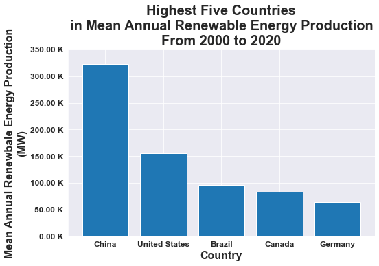

```python
# Defining the plot_bar arguments
df = high_mean_renewable_gdp
x_axis = 'country'
y_axis = 'mean_renewable_production'
labels = {'title' : 'Highest Five Countries\nin Mean Annual Renewable Energy Production\nFrom 2000 to 2020',
          'xlabel': 'Country',
          'ylabel': 'Mean Annual Renewbale Energy Production\n(MW)'}

# Plotting the bar chart for the highest 5 countries
plot_bar(df, x_axis, y_axis, labels)
```

The bar chart shows the following:

- China has been the highest in total annual renewable energy production with 322K MW.
- In the second place comes the United states with 155K MW, wich is almost half the total mean of renewable energy production for China.
- Brazil was in the third place with 96K MW, which is almost 60% of what the united states produce, and only 30% of what China produce.
- As for Canada and Germany, they placed in the forth and fifth places respectively.

In conclusion, it is clear from the chart that there is an enormous discrepancy between these five nations, with China and the United States leading the way and Germany trailing behind.

### Question 2: Which five countries have the greatest Total GDP from 2000 to 2020?

As previously established throughout the data cleaning process, the United States, China, Japan, Germany, and the United Kingdom were the top five in total annual mean GDP from 2000 to 2020.  
Let's graph them in a bar chart to see the differences in Total mean annual GDP between these five countries.  
We will plot `high_mean_gdp` dataframe in this bar chart using `plot_bar` function defined before which takes `df`, `x_axis`, `y_axis` and `labels` as arrguments.

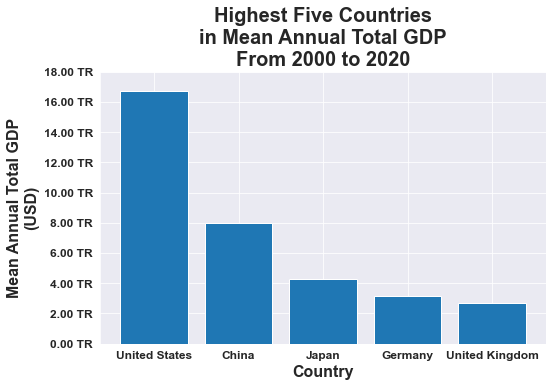

```python
# Defining the plot_bar arguments
df = high_mean_gdp
x_axis = 'country'
y_axis = 'mean_total_gdp'
labels = {'title' : 'Highest Five Countries\nin Mean Annual Total GDP\nFrom 2000 to 2020',
          'xlabel': 'Country',
          'ylabel': 'Mean Annual Total GDP\n(USD)'}

# Plotting the bar chart for the highest 5 countries
plot_bar(df, x_axis, y_axis, labels)
```

The bar chart shows the following:

- The United States has been the highest in total annual mean GDP with 16.7 TR USD.
- In the second place comes China with almost 8TR USD, wich is almost half the total mean GDP for the United States.
- Japan was in the third place with amost 4.3 TR USD, which is almost 50% of what the China have, and only 25% of what the United States have.
- As for Germany and the United Kingdom, they placed in the forth and fifth places respectively.

In summarize, it is clear from the chart that there is a significant disparity between these five countries, with the US and China leading the way and Japan, Germany, and the UK trailing far behind.

### Question 3: What are the distributions of the renewable energy production and total GDP from 2000 to 2020?

To answer this question, we must first grasp the information on total renewable energy production and total GDP distribution, and to do so, we must first plot a histogram for each dataset separately.  
Let's start by plotting a histogram for the total renewable energy production distribution using `plot_hist` function defined before with `mean_renewable_production` as the x-axis.

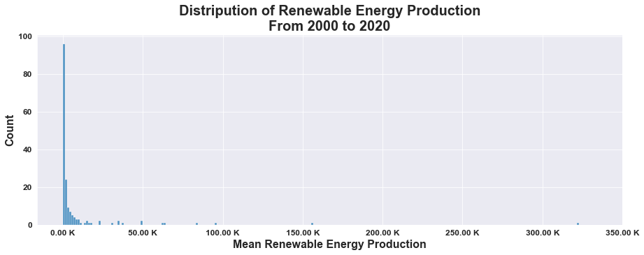

```python
# Defining the plot_hist arguments
x_axis = mean_renewable_gdp['mean_renewable_production']
labels = {'title' : 'Distripution of Renewable Energy Production\nFrom 2000 to 2020',
          'xlabel': 'Mean Renewable Energy Production',
          'ylabel': 'Count'}

# Plotting the histograme for the mean_renewable_production
plot_hist(x_axis, labels)
```

The histogram of mean renewable energy production is highly skewed to the right, which reveals the following:

- China and the United States are well ahead with a large margin with 322 K MW and 155 KMW respectively.
- 160 nations out of 171 in this dataframe are much behind these two with ranges close to zero.

Now, let's plot a histogram for the Mean toal GDP

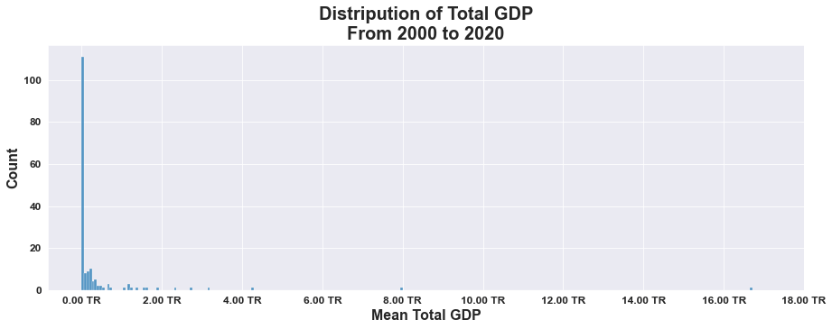

```python
# Defining the plot_hist arguments
x_axis = mean_renewable_gdp['mean_gdp']
labels = {'title' : 'Distripution of Total GDP\nFrom 2000 to 2020',
          'xlabel': 'Mean Total GDP',
          'ylabel': 'Count'}

# Plotting the histograme for the mean_renewable_production
plot_hist(x_axis, labels)
```

Like The histogram of mean renewable energy production, the histogram of the mean total GDP is highly skewed to the right, which reveals the following:

- The United States and China are well ahead with a large margin with almost 17 TR USD and 8 TR USD respectively.
- 160 nations out of 171 in this dataframe are much behind these two with ranges that is less than 1.7 TR USD, which is only 10% of what US has.

Now, let's plot a Scatter graph where the mean renewable energy prodution on the `x-axis` and the mean total GDP on the `y-axis` to see if there is a relation between the two aspects.

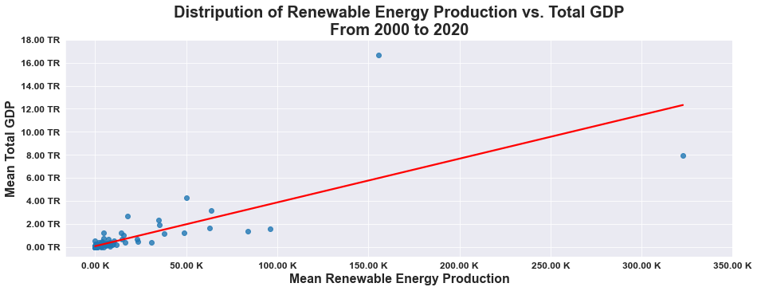

```python
# Defining the plot_scatter arguments
x_axis = mean_renewable_gdp['mean_renewable_production']
y_axis = mean_renewable_gdp['mean_gdp']
labels = {'title' : 'Distripution of Renewable Energy Production vs. Total GDP\nFrom 2000 to 2020',
          'xlabel': 'Mean Renewable Energy Production',
          'ylabel': 'Mean Total GDP'}

# Plotting the scatter graph for the mean renewable production vs. mean total GDP
plot_scatter(x_axis, y_axis, labels);
```

The scatter graph for the mean renewable energy production vs. total GDP reveals the following:

- Only China and the United states are away of the rest countries in both the renewable energy production and total GDP, which confirms why these two are two great nations.
- The best fit line shows the positive relation between producing renewable energy and total GDP, which means that the more renewable energy produced, the Total GDP will increase.

### Question 4: Does the generation of renewable energy affect countries' total GDP?

We will only utilise data from the United States, China, and Germany to tackle this question as they're the only three nations that appear on both high mean lists. A comparison of renewable energy production and total GDP in each country might assist in answering this question.  
The three bar charts below, which show annual renewable energy production and annual total GDP for the three common nations on both lists (China, the United States, and Germany), may help to clarify whether or not there is a relationship between the two aspects.  
Let us begin with the `United States` Graph since it has the highest overall GDP. We will use the `plot_twin_bar` function to plot a twin graph with renewable energy production as `y_axis1` and total GDP as `y-axis2`

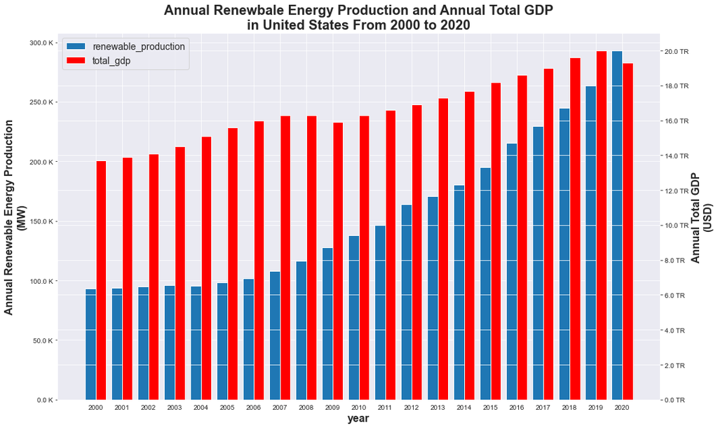

```python
# Defining the plot_bar arguments
df = df_renewable_gdp.query('country == "United States"')
x_axis = 'year'
y_axis1 = 'renewable_production'
y_axis2 = 'total_gdp'
labels = {'title' : 'Annual Renewbale Energy Production and Annual Total GDP\nin United States From 2000 to 2020',
          'xlabel': 'year',
          'ylabel1': 'Annual Renewable Energy Production\n(MW)',
          'ylabel2': 'Annual Total GDP\n(USD)'}

# Plotting the bar chart for the highest 5 countries
plot_twin_bar(df, x_axis, y_axis1, y_axis2, labels)
```

The twin bar chart shows the following:

- From 2010 to 2019, both the production of renewable energy and the total GDP of the United States are increasing positively, which may indicate that producing renewable energy increases GDP growth.
- In 2020, we observed that, while renewable energy production grew over the previous year, the total GDP decreased. We might speculate that this occurred as a result of the COVID-19 epidemic and its global impact.

We need to look at other countries to establish the impact of renewable energy production on total GDP. The next country that we gonna graph is `China` as it is the second highest in Total GDP. We will use the `plot_twin_bar` function as before to plot a twin graph with renewable energy production as `y_axis1` and total GDP as `y-axis2`.

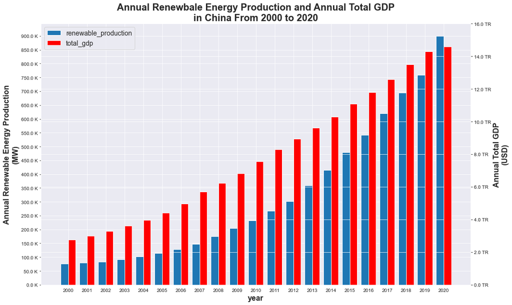

```python
# Defining the plot_bar arguments
df = df_renewable_gdp.query('country == "China"')
x_axis = 'year'
y_axis1 = 'renewable_production'
y_axis2 = 'total_gdp'
labels = {'title' : 'Annual Renewbale Energy Production and Annual Total GDP\nin China From 2000 to 2020',
          'xlabel': 'year',
          'ylabel1': 'Annual Renewable Energy Production\n(MW)',
          'ylabel2': 'Annual Total GDP\n(USD)'}

# Plotting the bar chart for the highest 5 countries
plot_twin_bar(df, x_axis, y_axis1, y_axis2, labels)
```

The twin bar chart shows the following:

- Both renewable energy production and total GDP have expanded exponentially throughout the years, implying that there is a positive relationship between rising renewable energy productivity and rising of total GDP.
- We have seen a decrease in the steepness of GDP growth bar chart in 2020, indicating that China also suffered from the COVID-19 breakout, although not as much as the United States.

We might need to look at Germany also to establish the impact of renewable energy production on total GDP. Germany is the last country that is common between the two high means dataframes. We gonna graph `Germany` using the `plot_twin_bar` function as before to plot a twin graph with renewable energy production as `y_axis1` and total GDP as `y-axis2`.

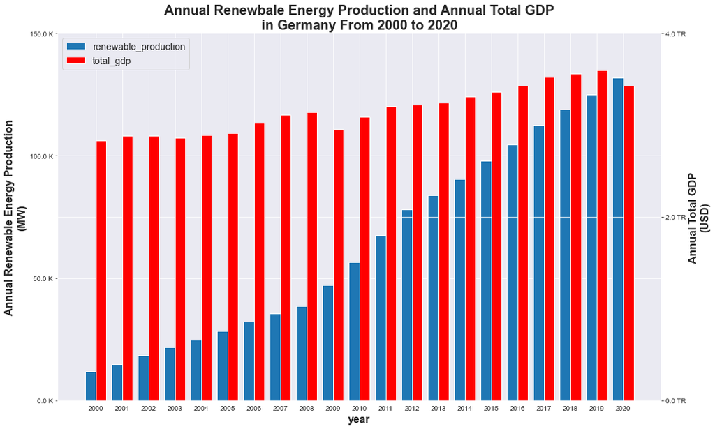

```python
# Defining the plot_bar arguments
df = df_renewable_gdp.query('country == "Germany"')
x_axis = 'year'
y_axis1 = 'renewable_production'
y_axis2 = 'total_gdp'
labels = {'title' : 'Annual Renewbale Energy Production and Annual Total GDP\nin Germany From 2000 to 2020',
          'xlabel': 'year',
          'ylabel1': 'Annual Renewable Energy Production\n(MW)',
          'ylabel2': 'Annual Total GDP\n(USD)'}

# Plotting the bar chart for the highest 5 countries
plot_twin_bar(df, x_axis, y_axis1, y_axis2, labels)
```

The twin bar chart illustrates the following:

- In the graph of Germany, we can see that the exponential growth of renewable energy began in 2009, and that the total GDP began to rise as a result of increased renewable energy production. This demonstrates that the generation of renewable energy contributes significantly to the increase in total GDP.
- In 2020, as shown in the situations of the United States and China, total GDP fell as a result of the COVID-19 epidemic, despite an increase in renewable energy generation.

### Question 5: What are the trends in renewable energy production in countries with the largest total GDP?

Now let's plot the final graph in this section, hoping it reveals more facts about the effect of producing renewable energy on the total GDP. The following code will graph the data from all Seven nations on the high mean renewable energy production and total GDP lists in a combined line graph for each aspect from 2000 to 2020.

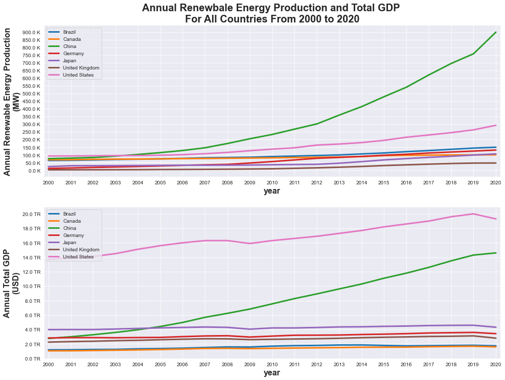

```python
# Plotting renewable energy production and total GDP line chart for all countries
fig, ax = plt.subplots(2,1,figsize=(16,12))
for item in df_renewable_gdp.country.unique():
    # Get each country data separately to be ploted
    country_data = df_renewable_gdp.loc[df_renewable_gdp['country'] == item]

    # Plotting renewable energy production for all countries from 2000 to 2020
    ax[0] = country_data.plot(ax=ax[0], kind = 'line', linewidth = 3
                              , x = 'year', y = 'renewable_production'
                              , label = item)

    # Plotting total GDP for all countries from 2000 to 2020
    ax[1] = country_data.plot(ax=ax[1], kind = 'line', linewidth = 3
                              , x = 'year', y = 'total_gdp'
                              , label = item)

# Changing x axis labels and ticks for renewable energy production graph
y_ticks1 = ticks(df_renewable_gdp['renewable_production'].max())
ax[0].set_xlabel('year', fontsize=16, fontweight='bold')
ax[0].set_xticks(np.arange(2000,2021),fontsize=14, fontweight='bold')
ax[0].set_xlim(1999.8,2020.2)

# Changing y axis labels and ticks for renewable energy production graph
ax[0].set_ylabel('Annual Renewable Energy Production\n(MW)', fontsize=16, fontweight='bold')
ax[0].set_yticks(np.arange(0,y_ticks1[-1], y_ticks1[-2]), fontsize=14, fontweight='bold')
ax[0].set_yticklabels(['{:1.1f} {}'.format(x/y_ticks1[1], y_ticks1[0]) for x in np.arange(0,y_ticks1[-1], y_ticks1[-2])])

# Changing graph title and legend
ax[0].set_title('Annual Renewbale Energy Production and Total GDP \nFor All Countries From 2000 to 2020'
            , fontsize=20, fontweight='bold')

ax[0].legend(fontsize = 10, loc = 'upper left')

# Changing x axis labels and ticks for total GDP graph
ax[1].set_xlabel('year', fontsize=16, fontweight='bold')
ax[1].set_xticks(np.arange(2000,2021),fontsize=14, fontweight='bold')
ax[1].set_xlim(1999.8,2020.2)

# Changing y axis labels and ticks for total GDP graph
y_ticks2 = ticks(df_renewable_gdp['total_gdp'].max())
ax[1].set_ylabel('Annual Total GDP\n(USD)', fontsize=16, fontweight='bold')
ax[1].set_yticks(np.arange(0,y_ticks2[-1], y_ticks2[-2]), fontsize=14, fontweight='bold')
ax[1].set_yticklabels(['{:1.1f} {}'.format(x/y_ticks2[1], y_ticks2[0]) for x in np.arange(0,y_ticks2[-1], y_ticks2[-2])])

# Changing graph legend font
ax[1].legend(fontsize = 10, loc = 'upper left');
```

This Graph reveals some new patterns in the influence of producing renewable energy on increasing total GDP, which are as follow:

**In Annual Renewable Energy Production Graph:**

All the data analized revealed the same results as known before in the previous section.

**In Annual Total GDP Graph:**

- The United States leads the Total GDP graph by a wide margin.
- China is in second position, with a differential of over 3 TR USD less than the US.
- China's total GDP expanded five times between 2000 and2020, propelling it from fourth position in 2000 to second place in 2020 with a total GDP of about 15 TR USD.
- Due to the COVID-19 pandemic, all nations' total GDP declined by around 5% in2020, except China, whose total GDP increased by about2%, demonstrating China's victory over all other countries in controlling the outbreak's impact.
- The remaining countries' total GDP growth has been low or constant over the years.

## Exploring the Effect of Renewable Energy Production on Non-renewable Energy Consumption

Three dataframes will be used in this exloratory section which are `high_mean_cons`, `mean_renewable_cons`, and `df_renewable_cons`. These dataframes will help us answer the questions raised before regarding the effect of renewable energy production on total non-renewable energy consumption.

```python
# Loading cleaned data into dataframes

# Loading high_mean_cons
high_mean_cons = pd.read_csv('high_mean_cons.csv')
high_mean_cons.columns = ['country', 'mean_total_consumption']

# Loading both_mean_renewable_cons
mean_renewable_cons = pd.read_csv('both_mean_renewable_cons.csv', index_col=0)

# Loading renewable_cons_clean
df_renewable_cons = pd.read_csv('renewable_cons_clean.csv', index_col=0)
```

### Question 1: Which five countries consumed the most non-renewable energy between 2000 and 2019?

From 2000 to 2019, China, the United States, India, Japan, and Russia were the top five consumers of non-renewable energy (i.e., oil and coal), as previously demonstrated during the data cleaning process.  
Let's graph them in a bar chart to see the differences in Total mean annual non-renewable energy consumption between these five countries.  
We will plot `high_mean_cons` dataframe in this bar chart using `plot_bar` function defined before which takes `df`, `x_axis`, `y_axis` and `labels` as arrguments.

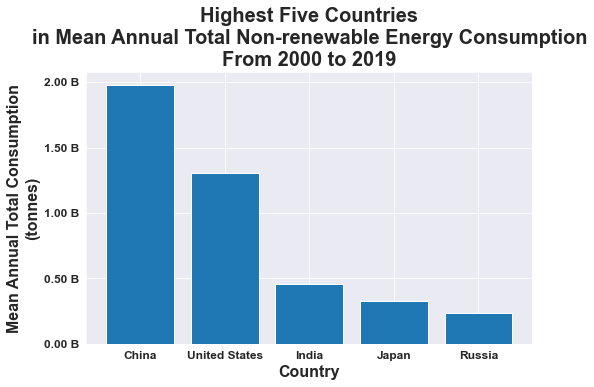

```python
# Defining the plot_bar arguments
df = high_mean_cons
x_axis = 'country'
y_axis = 'mean_total_consumption'
labels = {'title' : 'Highest Five Countries\nin Mean Annual Total Non-renewable Energy Consumption\nFrom 2000 to 2019',
          'xlabel': 'Country',
          'ylabel': 'Mean Annual Total Consumption\n(tonnes)'}

# Plotting the bar chart for the highest 5 countries
plot_bar(df, x_axis, y_axis, labels)
```

The bar chart illustrates the following:

- China has been the highest in total annual mean non-renewable energy consumption with almost 2 B Tonnes.
- In the second place comes the United States with 1.3 B Tonnes, wich is 65% of the total mean non-renewable energy consumption for China.
- India was in the third place in mean total non-renewable energy consumption with amost 450 M Tonnes, which is almost 23% of what the China consume, and 35% of what the United States consume.
- As for Japan and Russia, they placed in the forth and fifth places with almost 350 M Tonnes and 230 M Tonnes respectively.

In summarize, the accompanying bar chart depicts the substantial discrepancy between these five nations, with China and the United States leading the way and India, Japan, and Russia trailing far behind.

### Question 2: What are the distributions of total renewable energy production and total non-renewable energy consumption from 2000 to 2019?

According to the preceding section, the total renewable energy production histogram is highly skewed to the right, with China and the United States well ahead by a wide margin, and 160 nations out of 171 far behind with ranges near to zero.  
With this in mind, and in order to answer this question, we must gather information on total non-renewable energy consumption and construct a histogram for this dataset independently. Then, for total renewable energy production vs. total non-renewable energy consumption, we will plot a scatter graph demonstrating the relation between them for all countries in the dataframe.  
Let's start by plotting a histogram for the total non-renewable energy consumption distribution using `plot_hist` function defined before with `mean_cons` as the x-axis.

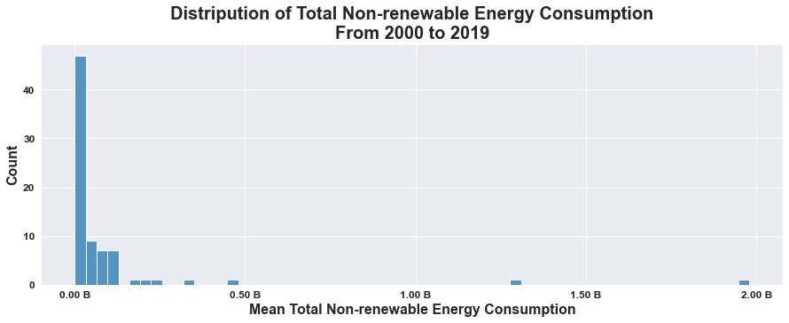

```python
# Defining the plot_hist arguments
x_axis = mean_renewable_cons['mean_cons']
labels = {'title' : 'Distripution of Total Non-renewable Energy Consumption\nFrom 2000 to 2019',
          'xlabel': 'Mean Total Non-renewable Energy Consumption',
          'ylabel': 'Count'}

# Plotting the histograme for the mean_renewable_production
plot_hist(x_axis, labels)
```

The histogram of the mean total non-renewable energy consumption is also highly skewed to the right, which reveals the following:

- The China and United States are well ahead with a large margin with almost 2 B Tonnes and 1.3 B Tonnes respectively.
- 70 countries out of 77 in this dataframe are much behind these two with ranges from Zero to 150 M Tonnes, which is only 8% of what China consume.

Now, let's plot a Scatter graph where the mean renewable energy prodution on the `x-axis` and the mean total non-renewable energy consumption on the `y-axis` to see if there is a relation between the two aspects.

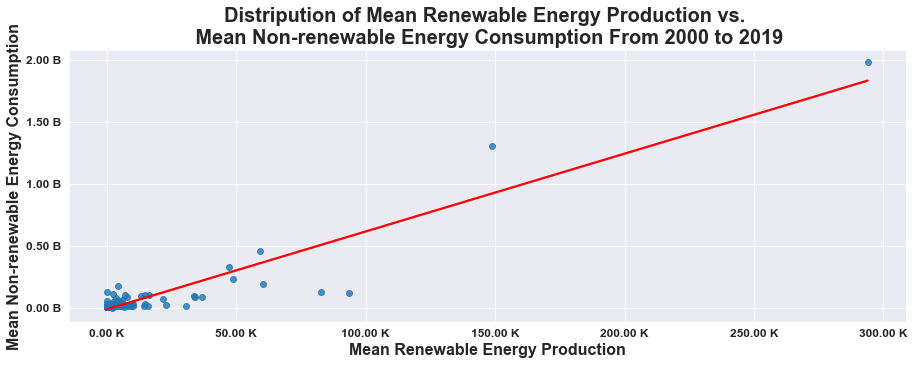

```python
# Defining the plot_scatter arguments
x_axis = mean_renewable_cons['mean_renewable_production']
y_axis = mean_renewable_cons['mean_cons']
labels = {'title' : 'Distripution of Mean Renewable Energy Production vs. \n Mean Non-renewable Energy Consumption From 2000 to 2019',
          'xlabel': 'Mean Renewable Energy Production',
          'ylabel': 'Mean Non-renewable Energy Consumption'}

# Plotting the scatter graph for the mean renewable production vs. mean total GDP
plot_scatter(x_axis, y_axis, labels);
```

### Question 3: Does the generation of renewable energy diminish the consumption of non-renewable energy?

We will only utilise data from the China, and the United States to tackle this question as they're the only Two nations that appear on both high mean lists. A comparison of renewable energy production and non-renewable energy consumption in each country might assist in answering this question.  
The two twin bar charts below, which show annual renewable energy production and annual non-renewable energy consumption for the two common nations on both lists (China and the United States), may assist to determine whether or not the two factors are related.  
Let us begin with the `China` Graph since it has the highest non-renewable energy consumption and renewable energy production. We will use the `plot_twin_bar` function to plot a twin graph with renewable energy production as `y_axis1` and non-renewable energy consumption as `y-axis2`

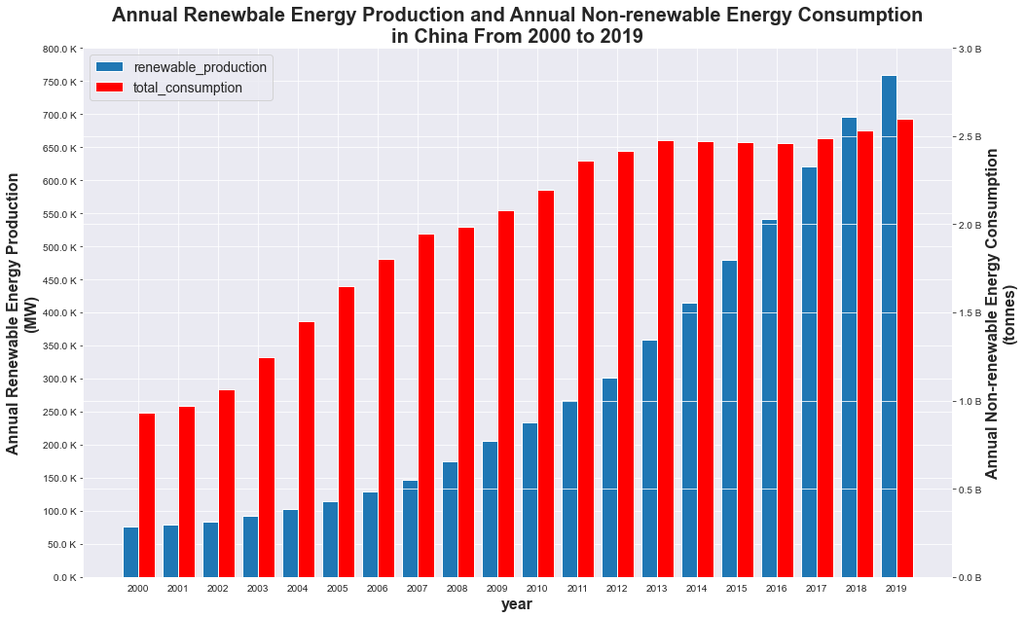

```python
# Defining the plot_bar arguments
df = df_renewable_cons.query('country == "China"')
x_axis = 'year'
y_axis1 = 'renewable_production'
y_axis2 = 'total_consumption'
labels = {'title' : 'Annual Renewbale Energy Production and Annual Non-renewable Energy Consumption\nin China From 2000 to 2019',
          'xlabel': 'year',
          'ylabel1': 'Annual Renewable Energy Production\n(MW)',
          'ylabel2': 'Annual Non-renewable Energy Consumption\n(tonnes)'}

# Plotting the bar chart for the highest 5 countries
plot_twin_bar(df, x_axis, y_axis1, y_axis2, labels)
```

The twin bar chart shows the following:

- The production of renewable energy shows an exponential rise over the secified period.
- The consumption of non-renewable energy also was increasing from 2000 till 2007, and then from 2008 to 2013, the slope of the increment reduced till it ceased in 2014 till 2019.
- The graph clearly demonistrate that producing renewable energy has a direct impact on not only slowing the rapid rise of overall non-renewable energy consumption, but alos it may lower it over the years.

We need to also look at `United States` graph to establish if there is an impact of renewable energy production on non-renewable energy consumption, or not. We will use the `plot_twin_bar` function as before to plot a twin graph with renewable energy production as `y_axis1` and non-renewable energy consumption as `y-axis2`.

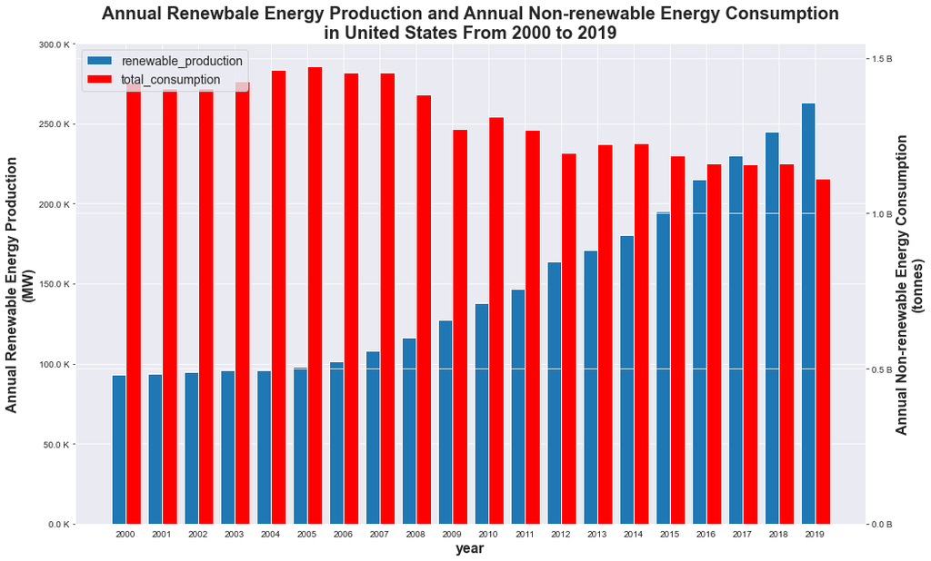

```python
# Defining the plot_bar arguments
df = df_renewable_cons.query('country == "United States"')
x_axis = 'year'
y_axis1 = 'renewable_production'
y_axis2 = 'total_consumption'
labels = {'title' : 'Annual Renewbale Energy Production and Annual Non-renewable Energy Consumption\nin United States From 2000 to 2019',
          'xlabel': 'year',
          'ylabel1': 'Annual Renewable Energy Production\n(MW)',
          'ylabel2': 'Annual Non-renewable Energy Consumption\n(tonnes)'}

# Plotting the bar chart for the highest 5 countries
plot_twin_bar(df, x_axis, y_axis1, y_axis2, labels)
```

The twin bar chart demonstrates the following:

- The production of renewable energy shows an exponential rise from 2007 till 2019.
- The consumption of non-renewable energy, on the other hand, decreased almost 25% from 2007 till 2019.
- The beneficial impact of renewable energy generation on lowering total non-renewable energy consumption was greater in the United States; the exponential rise in renewable energy generation reduced overall non-renewable energy use in the United States by about 25%, which is remarkable.

To sum up, after comparing the two twin bar charts for the greatest nation, we can establish that producing renewable energy has a positive impact on reducing non-renewable energy consumption.

### Question 4: What are the trends in renewable energy production in the top five non-renewable energy consuming countries?

Now let's plot the final graph in this section, hoping it reveals more facts about the effect of producing renewable energy on the non-renewable energy consumption. The following code will graph the data from all Eight nations on the high mean renewable energy production and mean non-renewabel energy consumption lists in a combined line graph for each aspect from 2000 to 2019.

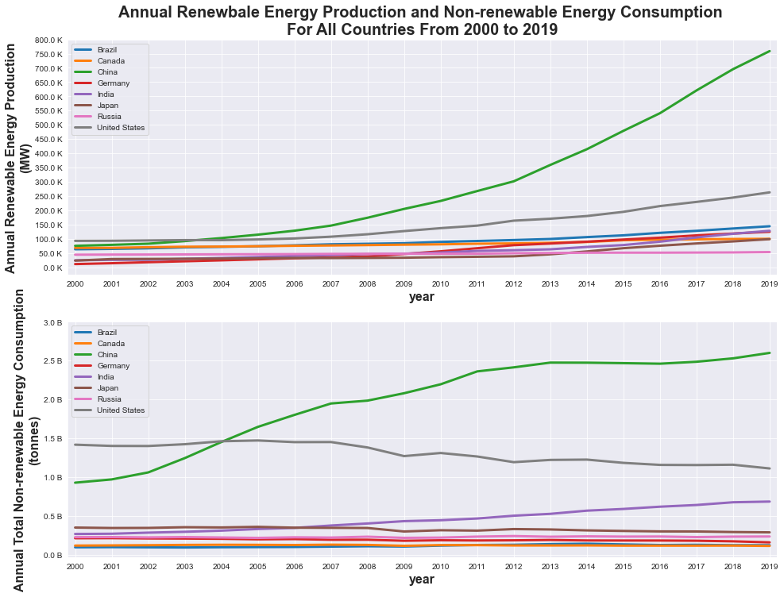

```python
# Plotting renewable energy production and non-renewable energy total consumption line chart for all countries
fig, ax = plt.subplots(2,1,figsize=(16,12))
for item in df_renewable_cons.country.unique():
    # Get each country data separately to be ploted
    country_data = df_renewable_cons.loc[df_renewable_cons['country'] == item]

    # Plotting renewable energy production for all countries from 2000 to 2019
    ax[0] = country_data.plot(ax=ax[0], kind = 'line', linewidth = 3
                              , x = 'year', y = 'renewable_production'
                              , label = item)

    # Plotting non-renewable energy consumption for all countries from 2000 to 2019
    ax[1] = country_data.plot(ax=ax[1], kind = 'line', linewidth = 3
                              , x = 'year', y = 'total_consumption'
                              , label = item)

# Changing x axis labels and ticks for renewable energy production graph
ax[0].set_xlabel('year', fontsize=16, fontweight='bold')
ax[0].set_xticks(np.arange(2000,2020),fontsize=14, fontweight='bold')
ax[0].set_xlim(1999.8,2019.2)

# Changing y axis labels and ticks for renewable energy production graph
y_ticks1 = ticks(df_renewable_cons['renewable_production'].max())
ax[0].set_ylabel('Annual Renewable Energy Production\n(MW)', fontsize=16, fontweight='bold')
ax[0].set_yticks(np.arange(0,y_ticks1[-1], y_ticks1[-2]), fontsize=14, fontweight='bold')
ax[0].set_yticklabels(['{:1.1f} {}'.format(x/y_ticks1[1], y_ticks1[0]) for x in np.arange(0,y_ticks1[-1], y_ticks1[-2])])

# Changing graph title and legend
ax[0].set_title('Annual Renewbale Energy Production and Non-renewable Energy Consumption \nFor All Countries From 2000 to 2019'
            , fontsize=20, fontweight='bold')

ax[0].legend(fontsize = 10)

# Changing x axis labels and ticks for non-renewable energy consumption graph
ax[1].set_xlabel('year', fontsize=16, fontweight='bold')
ax[1].set_xticks(np.arange(2000,2020),fontsize=14, fontweight='bold')
ax[1].set_xlim(1999.8,2019.2)

# Changing y axis labels and ticks for non-renewable energy consumption graph
y_ticks2 = ticks(df_renewable_cons['total_consumption'].max())
ax[1].set_ylabel('Annual Total Non-renewable Energy Consumption\n(tonnes)', fontsize=16, fontweight='bold')
ax[1].set_yticks(np.arange(0,y_ticks2[-1], y_ticks2[-2]), fontsize=14, fontweight='bold')
ax[1].set_yticklabels(['{:1.1f} {}'.format(x/y_ticks2[1], y_ticks2[0]) for x in np.arange(0,y_ticks2[-1], y_ticks2[-2])])

# Changing graph legend font
ax[1].legend(fontsize = 10);
```

This Graph reveals some new patterns in the influence of producing renewable energy on reducing non-renewable energy consumption, which are as follow:

**In Annual Renewable Energy Production Graph:**

All the data analized revealed the same results as known before in the previous section.

- Between 2000 and 2019, China has increased its production of renewable energy by about 700%. Although it began lower than the United States, China currently leads the generation of renewable energy with a significant advantage over other countries.
- Following China, the United States has seen approximately 200 % increase in renewable energy production.
- The remainder of the countries have shown limited or flat increase in renewable energy production throughout the years.

**In Annual Total Non-renewable Energy Consumption Graph:**

## Exploring the Effect of Renewable Energy Production on CO2 Emissions

Three dataframes will be used in this exloratory section which are `high_mean_co2`, `mean_renewable_co2`, and `df_renewable_co2`. These dataframes will help us answer the questions raised before regarding the effect of renewable energy production on CO2 emissions.

```python
# Loading cleaned data into dataframes

# Loading high_mean_co2
high_mean_co2 = pd.read_csv('high_mean_co2.csv')
high_mean_co2.columns = ['country', 'mean_total_co2']

# Loading both_mean_renewable_co2
mean_renewable_co2 = pd.read_csv('both_mean_renewable_co2.csv', index_col=0)

# Loading renewable_co2_clean
df_renewable_co2 = pd.read_csv('renewable_co2_clean.csv', index_col=0)
```

### Question 1: Which five countries have the highest mean annual CO2 emissions between 2000 and 2018?

As previously shown throughout the data cleaning process, China, United States, India, Russia, and Jopan were the five highest CO2 emitters from 2000 to 2018.  
Let's graph them in a bar chart to see the differences in Total mean annual CO2 emissions between these five countries.  
We will plot `high_mean_co2` dataframe in this bar chart using `plot_bar` function defined before which takes `df`, `x_axis`, `y_axis` and `labels` as arrguments.

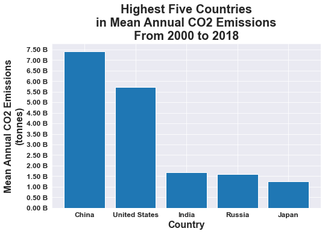

```python
# Defining the plot_bar arguments
df = high_mean_co2
x_axis = 'country'
y_axis = 'mean_total_co2'
labels = {'title' : 'Highest Five Countries\nin Mean Annual CO2 Emissions\nFrom 2000 to 2018',
          'xlabel': 'Country',
          'ylabel': 'Mean Annual CO2 Emissions\n(tonnes)'}

# Plotting the bar chart for the highest 5 countries
plot_bar(df, x_axis, y_axis, labels)
```

The bar chart illustrates the following:

- China has been the highest in total annual CO2 emissions with almost 7.4 B Tonnes.
- In the second place comes the United States with 5.7 B Tonnes, wich is 77% of the total mean CO2 emissions for China.
- India was in the third place in mean CO2 emissions with amost 1.7 B Tonnes, which is almost 23% of what the China emit, and 30% of what the United States emit.
- As for Russia and Japan, they placed in the forth and fifth places with almost 1.6 B Tonnes and 1.3 B Tonnes respectively.
- China and United States have the largest mean yearly CO2 emissions, with China around five times more than the other three nations and United States about four times higher.

**Interesting fact related to CO2 emissions and non-renewable energy consumption**  
However japan consume more oil and coal than Russia, the CO2 emissions in Japan were lower than Russia, which means that Japan is developing ways to minimise its CO2 emissions in order to save the environment.  
The bar chart of mean annual CO2 emissions for the top 5 countries indicates the significant disparity between these five countries, with China and United States leading the way and India, Russia, and Japan considerably behind.

### Question 2: What are the distributions of total renewable energy production and total CO2 emissions from 2000 to 2018?

According to the previous sections, the total renewable energy production histogram is heavily skewed to the right, with China and the United States well ahead by a significant margin, and 160 nations out of 171 trailing considerably behind with ranges close to zero.  
With all that in account, and in purpose of answering this question, we must collect data on total yearly CO2 emissions and create a histogram for this dataset independently. Then, for total renewable energy production vs. total CO2 emissions, we will plot a scatter graph demonstrating the relation between them for all countries in the dataframe.  
Let's start by plotting a histogram for the total CO2 emissions distribution using `plot_hist` function defined before with `mean_co2` as the x-axis.

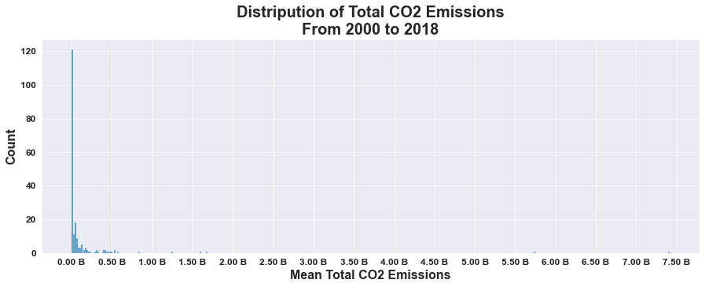

```python
# Defining the plot_hist arguments
x_axis = mean_renewable_co2['mean_co2']
labels = {'title' : 'Distripution of Total CO2 Emissions\nFrom 2000 to 2018',
          'xlabel': 'Mean Total CO2 Emissions',
          'ylabel': 'Count'}

# Plotting the histograme for the mean_renewable_production
plot_hist(x_axis, labels)
```

Now, let's plot a Scatter graph where the mean renewable energy prodution on the `x-axis` and the mean total CO2 emissions on the `y-axis` to see if there is a relation between the two aspects.

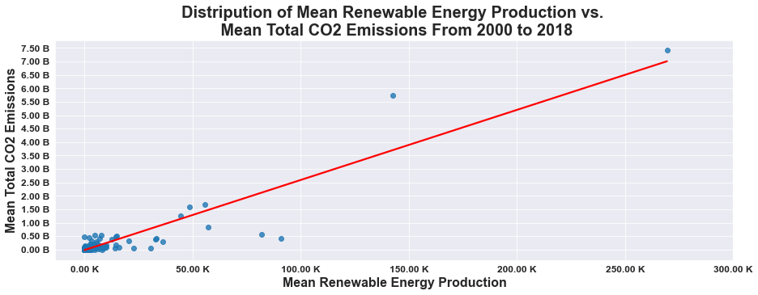

```python
# Defining the plot_scatter arguments
x_axis = mean_renewable_co2['mean_renewable_production']
y_axis = mean_renewable_co2['mean_co2']
labels = {'title' : 'Distripution of Mean Renewable Energy Production vs. \n Mean Total CO2 Emissions From 2000 to 2018',
          'xlabel': 'Mean Renewable Energy Production',
          'ylabel': 'Mean Total CO2 Emissions'}

# Plotting the scatter graph for the mean renewable production vs. mean total CO2 emissions
plot_scatter(x_axis, y_axis, labels);
```

### Question 3: Does the production of renewable energy reduce CO2 emissions?

We will only utilise data from the China, and the United States to tackle this question as they're the only Two nations that appear on both high mean lists. A comparison of renewable energy production and total CO2 emissions in each country might assist in answering this question.  
The two twin bar charts below, which show annual renewable energy production and annual CO2 emissions for the two common nations on both lists (China and the United States), may assist to determine whether or not the two factors are related.  
Let us begin with the `China` Graph since it has the highest annual CO2 emissions and renewable energy production. We will use the `plot_twin_bar` function to plot a twin graph with renewable energy production as `y_axis1` and total annual CO2 emissions as `y-axis2`.

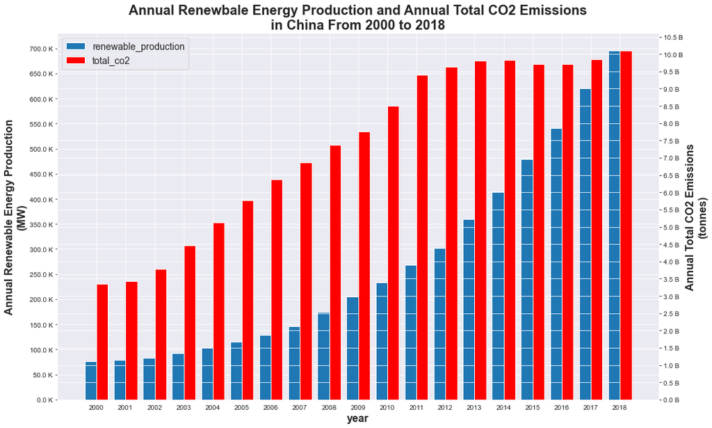

```python
# Defining the plot_bar arguments
df = df_renewable_co2.query('country == "China"')
x_axis = 'year'
y_axis1 = 'renewable_production'
y_axis2 = 'total_co2'
labels = {'title' : 'Annual Renewbale Energy Production and Annual Total CO2 Emissions\nin China From 2000 to 2018',
          'xlabel': 'year',
          'ylabel1': 'Annual Renewable Energy Production\n(MW)',
          'ylabel2': 'Annual Total CO2 Emissions\n(tonnes)'}

# Plotting the bar chart for the highest 5 countries
plot_twin_bar(df, x_axis, y_axis1, y_axis2, labels)
```

The twin bar chart indicates the following:

- The production of renewable energy shows an exponential rise over the secified period.
- The CO2 emissions also was increasing from 2000 till 2011, and then from 2011 to 2014, the slope of the increment reduced till it ceased to be almost flat in 2014 till 2018.
- This clearly indicates that producing renewable energy has a positive impact on reducing CO2 emissions, or at least slowed their rapid increase over the years.

We need to also look at `United States` graph to establish if there is an impact of renewable energy production on reducing CO2 emissions, or not. We will use the `plot_twin_bar` function as before to plot a twin graph with renewable energy production as `y_axis1` and CO2 emissions as `y-axis2`.

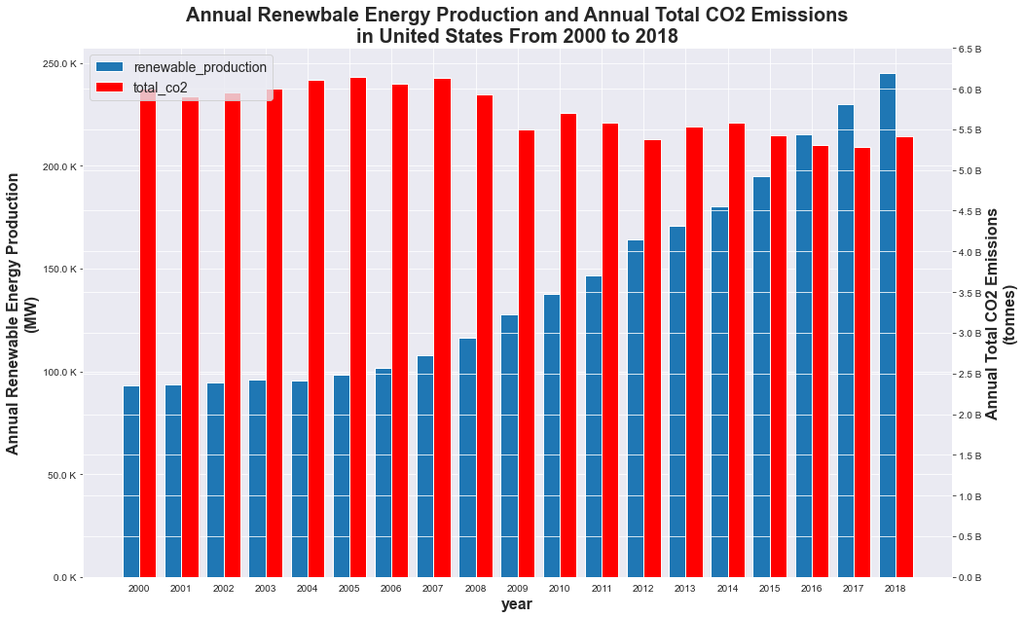

```python
# Defining the plot_bar arguments
df = df_renewable_co2.query('country == "United States"')
x_axis = 'year'
y_axis1 = 'renewable_production'
y_axis2 = 'total_co2'
labels = {'title' : 'Annual Renewbale Energy Production and Annual Total CO2 Emissions\nin United States From 2000 to 2018',
          'xlabel': 'year',
          'ylabel1': 'Annual Renewable Energy Production\n(MW)',
          'ylabel2': 'Annual Total CO2 Emissions\n(tonnes)'}

# Plotting the bar chart for the highest 5 countries
plot_twin_bar(df, x_axis, y_axis1, y_axis2, labels)
```

The twin bar chart demonstrates the following:

- The production of renewable energy shows an exponential rise from 2007 till 2018.
- The CO2 emissions, on the other hand, decreased almost 15% from 2007 till 2019.
- The positive influence of generating renewable energy on reducing total CO2 emissions was more substantial in the United States; From 2008 to 2018, the exponential increase in renewable energy production lowered CO2 emissions in the United States by almost 15%, which is outstanding. At this rate, the United States will be off the list of the top CO2 emitters by 2050.

To sum up, after comparing the two twin bar charts for the greatest nation, we can establish that producing renewable energy has a positive impact on reducing total CO2 emissions which is logical since generating renewable energy reduces the usage of non-renewable fuels, which is the main source of CO2 emissions.

### Question 4: What are the trends in renewable energy production and CO2 emissions in the top five countries?

Now let's plot the final graph in this section and in the exploratory section, hoping it reveals more facts about the effect of producing renewable energy on the CO2 emissions. The following code will graph the data from all Eight nations on the high mean renewable energy production and mean annual CO2 emissions lists in a combined line graph for each aspect from 2000 to 2018.

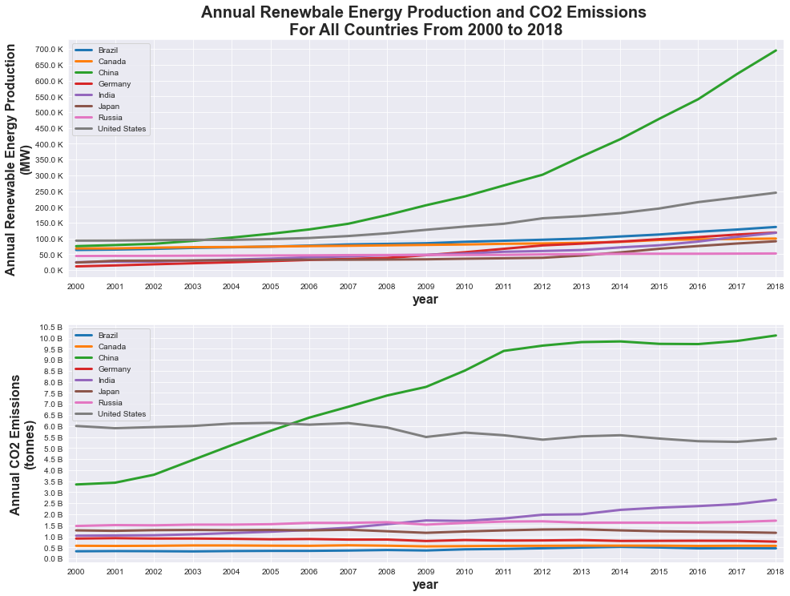

```python
# Plotting renewable energy production and CO2 emissions line chart for all countries
fig, ax = plt.subplots(2,1,figsize=(16,12))
for item in df_renewable_co2.country.unique():
    # Get each country data separately to be ploted
    country_data = df_renewable_co2.loc[df_renewable_co2['country'] == item]

    # Plotting renewable energy production for all countries from 2000 to 2018
    ax[0] = country_data.plot(ax=ax[0], kind = 'line', linewidth = 3
                              , x = 'year', y = 'renewable_production'
                              , label = item)

    # Plotting CO2 emissions for all countries from 2000 to 2018
    ax[1] = country_data.plot(ax=ax[1], kind = 'line', linewidth = 3
                              , x = 'year', y = 'total_co2'
                              , label = item)

# Changing x axis labels and ticks for renewable energy production graph
ax[0].set_xlabel('year', fontsize=16, fontweight='bold')
ax[0].set_xticks(np.arange(2000,2019),fontsize=14, fontweight='bold')
ax[0].set_xlim(1999.8,2018.2)

# Changing y axis labels and ticks for renewable energy production graph
y_ticks1 = ticks(df_renewable_co2['renewable_production'].max())
ax[0].set_ylabel('Annual Renewable Energy Production\n(MW)', fontsize=16, fontweight='bold')
ax[0].set_yticks(np.arange(0,y_ticks1[-1], y_ticks1[-2]), fontsize=14, fontweight='bold')
ax[0].set_yticklabels(['{:1.1f} {}'.format(x/y_ticks1[1], y_ticks1[0]) for x in np.arange(0,y_ticks1[-1], y_ticks1[-2])])

# Changing graph title and legend
ax[0].set_title('Annual Renewbale Energy Production and CO2 Emissions \nFor All Countries From 2000 to 2018'
            , fontsize=20, fontweight='bold')

ax[0].legend(fontsize = 10)

# Changing x axis labels and ticks for CO2 emissions graph
ax[1].set_xlabel('year', fontsize=16, fontweight='bold')
ax[1].set_xticks(np.arange(2000,2019),fontsize=14, fontweight='bold')
ax[1].set_xlim(1999.8,2018.2)

# Changing y axis labels and ticks for CO2 emissions graph
y_ticks2 = ticks(df_renewable_co2['total_co2'].max())
ax[1].set_ylabel('Annual CO2 Emissions\n(tonnes)', fontsize=16, fontweight='bold')
ax[1].set_yticks(np.arange(0,y_ticks2[-1], y_ticks2[-2]), fontsize=14, fontweight='bold')
ax[1].set_yticklabels(['{:1.1f} {}'.format(x/y_ticks2[1], y_ticks2[0]) for x in np.arange(0,y_ticks2[-1], y_ticks2[-2])])

# Changing graph legend font
ax[1].legend(fontsize = 10);
```

This Graph exposes some new patterns in the influence of producing renewable energy on reducing total CO2 emission, which are as follow:

Finally, we can conclude our analysis on the effect of renewable energy production on lowering CO2 emissions by knowing that generating renewable energy will significantly reduce CO2 emissions and preserve our environment.

# Conclusions

### The Effect of Renewable Energy Production on Total GDP

From 2000 to 2020, China and the United States lead in total renewable energy production, followed by Brazil, Canada, and Japan, whereas the United States leads in annual mean total GDP, followed by China, Japan, Germany, and the United Kingdom.

This section's analysis shows a direct relationship between expanding renewable energy production and boosting overall GDP. Except for 2020, which forecasts a 5% fall in overall GDP in most nations despite increased renewable energy production. The impact of the COVID-19 pandemic is responsible for the reduction in global total GDPs.

China was the only exception, with its overall GDP increasing by around 2%, proving China's triumph over all other nations in mitigating the outbreak's impact.

To summarise, all of the metrics examined demonstrated that increasing total renewable energy production had a positive influence on raising total GDP by reducing total non-renewable fuel consumption after eliminating the year 2020.

### The Effect of Renewable Energy Production on Non-renewable Energy Consumption

With the exception of Russia and Japan, the same nations with the greatest mean annual CO2 emissions were ranked in the same order with the highest non-renewable fuel usage. This exception illustrates that, while using more non-renewable fuels, Japan invests more in lowering emissions than Russia.

According to this analysis, producing renewable energy will significantly reduce non-renewable energy use. In reality, the analysis in this section anticipated that the reason producing renewable energy reduces CO2 emissions is that it reduces non-renewable energy consumption, which is the source of the majority of CO2 emissions.

From 2011 to 2019, the exponential growth in renewable energy generation in China halted the exponential rise in non-renewable energy consumption. In the United States, on the other hand, the exponential rise in renewable energy production lowered overall non-renewable energy demand by around 25%.

In terms of overall non-renewable energy consumption, China's annual consumption nearly tripled from 2000 to 2019, however the growth has come to a halt from 2011 to 2019 due to increased renewable energy production, while in the case of the United States, consumption has been cut by roughly 25.

To summarise, renewable energy production has a favourable influence on dramatically lowering total use of non-renewable fuels, which decreases CO2 emissions and helps to keep our world clean.

### The Effect of Renewable Energy Production on CO2 Emissions

From 2000 to 2018, China and the United States had the highest annual mean renewable energy production and CO2 emissions. In terms of high annual mean renewable energy production, these two countries were followed by Brazil, Canada, and Germany, and in terms of high annual mean CO2 emissions, India, Russia, and Japan.

We discovered that producing renewable energy had a beneficial impact on lowering CO2 emissions after exploring and visualising data from China and the United States about renewable energy production and CO2 emissions.

From 2000 to 2018, the production of renewable energy in China increased by almost 700 percent, and in the United States by around 200 percent, whereas the rest of the world countries had a limited or flat rise in renewable energy production.

In conclusion, all of the metrics examined demonstrated that increasing total renewable energy production had a negative influence on CO2 emissions, which will assist to preserve the world's ecology and keep the planet cleaner.

### Limitations

The three analyses in this report on the influence of renewable energy production on CO2 emissions, non-renewable energy consumption, and total GDP are not conclusive since they do not cover all of the countries in the glope.

The research was conducted for just the top five countries in each category and from 2000 to 2018 in the case of CO2 emissions, from 2000 to 2019 in the case of non-renewable energy production, and from 2000 to 2020 in the case of GDP, which is insufficient to generate a final accurate conclusion.

Furthermore, during the data cleaning phase, we decreased the sample size by excluding countries with any null values, and we further limited the selected sample by picking only the common countries in various datasets.

In the case of non-renewable energy consumption, we exclusively analysed oil and coal usage only, ignoring other non-renewable fuels.

In the case of Total GDP, we ignored other internal and external factors that may have an impact on total GDP, such as taxes, wages, interest rates, devaluation, and so on.

All of these constraints prohibit us from making a definitive conclusion. Acquiring and analysing data for all countries and for more years would influence the final results of this report; additionally, adding more factors that may be affected by producing renewable energy will drive a more detailed report with a definitive conclusion; however, this report provides a foundation that will be expanded given larger quantities of data for all countries and for more years.